# Opioidergic neurons modulate parental attentiveness in biparental poison frogs

- Show All Code
- Hide All Code
- View Source

Reproducible report: data, code and statistics for Figures 1 to 5

Published

16 November 2026

```r
library(here)    # every path starts from the folder that holds the .Rproj file
library(knitr)

# Each analysis step is one script in Functions/. run_step() runs a script in
# its own environment, exactly as Functions/run_all.R does.
run_step <- function(script) {
  source(here("Functions", script), local = new.env())
  invisible(NULL)
}

derived <- function(file) read.csv(here("Supplementary", "derived_tables", file), check.names = FALSE)

set.seed(1)   # every step that draws random numbers sets its own seed; see "Reproducibility"
```

## About this report

This page holds the analysis behind the quantitative panels of Figures 1 to 5. Rendering it runs every step from the files in `Data/` to the finished figures. The code for each step is folded under a “Code” heading; click it to read the script. The printed statistics and the figures below each step are the output of that run.

The steps, in order:

| Step | Script in `Functions/` | Reads | Writes |
| --- | --- | --- | --- |
| 1 | `Figure1_ethogram_panels_11162026.R` | reference event logs, recording metadata | the table of nest visits; Figure 1 B, C |
| 2 | `Figure2_11162026.R` | the visit table, recording metadata | the CarePC1 index, care level and rule, the per-day care tables; Figure 2 |
| 3 | `Figure3_11162026.R` | begging-frequency workbooks, TadBot visit sheet, the CarePC1 rule | the TadBot tables; Figure 3 B to E |
| 4 | `Figure4_11162026.R` | phosphoTRAP tables, the Figure 4A drawing, the snRNA-seq images | the mate-pair synchrony tables; Figure 4 |
| 5 | `Figure5_11162026.R` | RNAscope image counts, RNAscope event logs and pair list, naltrexone visit sheet, the CarePC1 rule, the micrograph and timeline images | CarePC1 of the RNAscope pairs and of the naltrexone tanks, two statistics tables; Figure 5 |
| 6 | `check_results.R` | the derived tables | nothing; stops if a headline number has changed |

The scripts follow the order of the figures, and each one goes from the raw data to its finished figure. Two things are passed forward, so the order matters: Figure 1 writes the visit table that Figure 2 reads, and Figure 2 writes the CarePC1 rule that Figures 3 and 5 apply to their own cohorts. `shared_functions.R` holds what the figure scripts share: the event-log reading rules and the function that scores a cohort with the CarePC1 rule. Tables written along the way are saved in `Supplementary/derived_tables/` and figures in `Figures/`.

## 1 Data

Everything is rebuilt from the files in `Data/`.

[output not shown]

The images placed into the figures are in `Figures/artwork/`: the Figure 2 photo strip (`Figure2_firstpanel_v2.png`), the Figure 4A drawing (`Figure4_artwork.png`), the Figure 5 micrographs (`Figure5_micrographs.png`) and the Figure 5 naltrexone timeline (`Figure5_naltrexone_timeline_stacked.png`).

Columns of `recording_metadata.csv`:

| Column | Meaning |
| --- | --- |
| `ObservationID` | Recording ID (breeding pair, then recording number) |
| `Pair` | Breeding pair |
| `NumberofFullDays` | Number of full days of usable video; the denominator for every per-day rate |
| `GapDays` | Recording days with no usable video, separated by `;`. Cumulative curves are left blank on these days. |
| `GapDaysNote` | The original hand-written note the gap days were read from |
| `EggFeedingEvents` | Number of egg-feeding events (15 recordings scored; blank = not scored) |
| `BodyLength_mm`, `TadpoleWeight_g`, `GosnerStage` | Tadpole measurements at the end of the recording |

`NumberofFullDays` and `GapDays` are the scorer’s own record of each recording, made while the videos were scored. They are taken as given and are not re-derived from the event logs: a log does not always show whether a day without rows had no video or simply no visits, or whether a first or last day was a full day. In some recordings they therefore differ by a day or two from a date-by-date count of the log.

## 2 Figure 1: coordinated visits

`Figure1_ethogram_panels_11162026.R` does everything for Figure 1. Its first part turns the 26 hand-typed event logs into one table with a row per nest visit; its second part draws panels B and C from that table.

### 2.1 Part 1: from event logs to nest visits

1. **Choose the spreadsheets.** The 26 recording IDs are read from the metadata. A spreadsheet belongs to a recording if its file name starts with that ID (after an optional `done-`).
2. **Find the columns.** The spreadsheets do not share one layout, so each column is identified by what it contains: the status column mostly holds “In”/“Out”, the visitor column mostly holds Male/Female/Family, the date column holds dates, the time column holds clock times, and the day column holds small whole numbers.
3. **Keep event rows.** A row is kept if it has a status, a date and a clock time. Header rows, blank rows and summary cells are dropped by this test.
4. **Read the visitor.** Short entries are read by their first letters, so spelling slips still count (`Mlae` is Male, `Femae` is Female, `Famly` is Family). Longer text in the visitor cell is treated as a note.
5. **Pair In with Out.** Rows stay in the order they were logged. Each “In” is paired with the next “Out” of the same visitor, and the visit’s duration is the time between them. A second “In” before an “Out” replaces the first. An “Out” with no open “In” is skipped.
6. **Keep valid visits.** A visit is kept if it lasts at most 24 hours. Visits whose In and Out fall in the same minute are kept with a duration of 0: they count as visits, and analyses of log duration leave them out.

### 2.2 Corrections applied while reading

The raw spreadsheets are never edited. Each correction is a rule in the code, and every row a rule touches is printed when the step runs (see “Rows touched by the correction rules” below).

| Typing slip | How it is detected | What the code does |
| --- | --- | --- |
| Wrong year in a date | The year differs from the most common year in that recording (no recording spans New Year) | Moves the date to the recording’s year |
| AM/PM slip (clock time typed 12 h early) | The row is more than 6 h earlier than a row above it with the same date, and adding 12 h gives the shortest positive visit | Adds 12 h to that row |
| Date not moved on after midnight | Same out-of-sequence test, but adding 24 h gives the shortest positive visit | Adds 24 h to that row |
| Note typed in the visitor cell of an Out row | The visitor cell is not a visitor, the row is an Out, and the row above is an open In | Treats the row as the Out for the visit opened above |
| Blank Day cell | The cell is empty | Fills the day from the date, using that recording’s usual date-to-day offset |
| Visitor misspelt | First letters | Read as the intended visitor |

For out-of-sequence rows the code tries both shifts (12 h and 24 h) on each flagged row of the pair and keeps the shortest positive duration.

The reading and correction rules live in one file, used for both the reference recordings and the RNAscope recordings:

**Code: Functions/shared_functions.R**

```r
# ============================================================================
# Functions shared by the figure scripts
#
# 1. Reading a raw event-log spreadsheet and turning it into visits. Used for
#    the 26 reference recordings (Figure 1) and for the RNAscope breeding
#    pairs (Figure 5), so that every event log in the paper is read with the
#    same rules. The rules are described at the top of
#    Figure1_ethogram_panels_11162026.R and in the reproducible report.
#
#      read_events(file, dir)     one row per In/Out event, typing slips flagged
#      pair_visits(events, file)  one row per visit: visitor, day, duration_min
#      read_visits(file, dir)     both steps, keeping visits of 0 to 24 hours
#
# 2. Scoring another cohort with the CarePC1 rule (Figures 3 and 5).
#
#      load_care_rule(rule_file)  returns care_pc1(), care_level() and the cutoff
# ============================================================================

library(readxl)

# ---- Read one spreadsheet into a clean event table --------------------------
# Each cell keeps its own type (col_types = "list"), so a column can be
# recognised by its contents rather than by its header or position.
share <- function(column, test) mean(vapply(column, function(cell) isTRUE(test(cell)), logical(1)))

is_status  <- function(x) is.character(x) && tolower(trimws(x)) %in% c("in", "out")
is_visitor <- function(x) is.character(x) && nchar(trimws(x)) <= 8 && grepl("^(m|fe|fa)", tolower(trimws(x)))
is_date    <- function(x) inherits(x, "POSIXct") && as.numeric(format(x, "%Y")) > 2000
is_time    <- function(x) inherits(x, "POSIXct") && as.numeric(format(x, "%Y")) < 1901   # Excel clock times
is_day     <- function(x) is.numeric(x) && !is.na(x) && x == round(x) && abs(x) < 100

find_columns <- function(sheet) {
  best <- function(test, skip = integer(0)) {
    scores <- vapply(sheet, share, numeric(1), test = test)
    scores[skip] <- -1
    unname(which.max(scores))
  }
  status <- best(is_status); visitor <- best(is_visitor, status)
  date   <- best(is_date);   time    <- best(is_time)
  day    <- best(is_day, c(status, visitor, date, time))
  c(day = day, date = date, time = time, visitor = visitor, status = status)
}

read_events <- function(file, dir) {
  sheet <- as.list(suppressMessages(read_excel(file.path(dir, file), sheet = 1,
                                               col_names = FALSE, col_types = "list")))
  col <- find_columns(sheet)
  keep <- vapply(sheet[[col[["status"]]]], is_status, logical(1)) &
          vapply(sheet[[col[["date"]]]], is_date, logical(1)) &
          vapply(sheet[[col[["time"]]]], is_time, logical(1))
  cell <- function(name) sheet[[col[[name]]]][keep]

  visitor <- vapply(cell("visitor"), function(x) {
    if (!is_visitor(x)) return(NA_character_)                  # blank or a note
    first <- tolower(substr(trimws(x), 1, 2))
    if (startsWith(first, "m")) "Male" else if (first == "fe") "Female" else "Family"
  }, character(1))

  date_part <- as.Date(do.call(c, cell("date")))
  year      <- format(date_part, "%Y")
  usual     <- names(which.max(table(year)))
  typo      <- year != usual
  if (any(typo)) {
    cat(sprintf("  %s: %d event(s) dated %s moved to %s\n", file, sum(typo),
                paste(unique(year[typo]), collapse = "/"), usual))
    date_part[typo] <- as.Date(paste0(usual, format(date_part[typo], "-%m-%d")))
  }
  clock   <- do.call(c, cell("time"))
  seconds <- as.numeric(format(clock, "%H", tz = "UTC")) * 3600 +
             as.numeric(format(clock, "%M", tz = "UTC")) * 60 +
             as.numeric(format(clock, "%S", tz = "UTC"))

  events <- data.frame(
    row     = which(keep),                                          # spreadsheet row number
    day     = vapply(cell("day"), function(x) if (is_day(x)) as.numeric(x) else NA_real_, numeric(1)),
    date    = as.numeric(date_part),
    when    = as.numeric(date_part) * 86400 + seconds,              # seconds on one continuous clock
    visitor = visitor,
    status  = tolower(trimws(unlist(cell("status")))),
    stringsAsFactors = FALSE)

  # fill blank Day cells from the date
  blank <- is.na(events$day)
  if (any(blank) && any(!blank)) {
    offset <- as.numeric(names(which.max(table(events$day - events$date))))
    events$day[blank] <- events$date[blank] + offset
    cat(sprintf("  %s: Day filled in from the date for %d event(s)\n", file, sum(blank)))
  }

  # flag rows logged more than 6 h earlier than a row above them with the same date
  events$out_of_sequence <- FALSE
  latest <- list()
  for (i in seq_len(nrow(events))) {
    key <- as.character(events$date[i])
    if (!is.null(latest[[key]]) && latest[[key]] - events$when[i] > 6 * 3600) {
      events$out_of_sequence[i] <- TRUE
    } else if (is.null(latest[[key]]) || events$when[i] > latest[[key]]) {
      latest[[key]] <- events$when[i]
    }
  }
  events
}

# ---- Pair each In with the next Out of the same visitor ---------------------
pair_visits <- function(events, file) {
  open   <- list()                             # the In event currently waiting, per visitor
  visits <- list()
  for (i in seq_len(nrow(events))) {
    who <- events$visitor[i]
    if (is.na(who)) {
      # a note in the visitor cell: an Out directly below an open In closes that visit
      above <- if (i > 1) events[i - 1, ] else NULL
      if (events$status[i] == "out" && !is.null(above) && above$status == "in" &&
          !is.na(above$visitor) && !is.null(open[[above$visitor]])) {
        who <- above$visitor
        cat(sprintf("  %s row %d: note in the visitor cell, read as %s Out\n", file, events$row[i], who))
      } else next
    }
    if (events$status[i] == "in") {
      open[[who]] <- events[i, ]
    } else if (!is.null(open[[who]])) {
      start    <- open[[who]]
      duration <- (events$when[i] - start$when) / 60
      if (start$out_of_sequence || events$out_of_sequence[i]) {
        # try each flagged row 12 h and 24 h later; keep the shortest positive duration
        shift_in  <- if (start$out_of_sequence)     c(720, 1440) else 0
        shift_out <- if (events$out_of_sequence[i]) c(720, 1440) else 0
        options   <- outer(shift_out, shift_in, function(o, s) duration + o - s)
        if (any(options > 0)) {
          fixed <- min(options[options > 0])
          cat(sprintf("  %s rows %d-%d (%s): %.0f min as typed, read as %.0f min\n",
                      file, start$row, events$row[i], who, duration, fixed))
          duration <- fixed
        }
      }
      visits[[length(visits) + 1]] <- data.frame(visitor = who, day = start$day, duration_min = duration)
      open[[who]] <- NULL
    }
  }
  do.call(rbind, visits)
}

# ---- Both steps: one spreadsheet -> its valid visits -------------------------
read_visits <- function(file, dir) {
  visits <- pair_visits(read_events(file, dir), file)
  visits[visits$duration_min >= 0 & visits$duration_min <= 24 * 60, ]
}

# ---- Scoring another cohort with the CarePC1 rule ---------------------------
# CarePC1 is defined once, on the 26 reference recordings. Figure2_11162026.R
# writes the rule to Supplementary/derived_tables/CarePC1_rule.csv: the mean and SD of coordinated
# visits per day and of coordinated minutes per day, the two loadings, and the
# High/Low cutoff. Every other cohort is scored with that same rule, so "High"
# and "Low" mean the same thing in every figure:
#
#   CarePC1 = loading1 * (coordinated visits per day  - mean1) / SD1
#           + loading2 * (coordinated minutes per day - mean2) / SD2
load_care_rule <- function(rule_file) {
  if (!file.exists(rule_file)) stop("Run Figure2_11162026.R first: it writes ", rule_file)
  rule   <- read.csv(rule_file, stringsAsFactors = FALSE)
  r_vis  <- rule[rule$Variable == "Visits_Family_perDay", ]
  r_min  <- rule[rule$Variable == "Minutes_Family_perDay", ]
  cutoff <- rule$Threshold[!is.na(rule$Threshold)][1]
  list(cutoff     = cutoff,
       care_pc1   = function(visits_per_day, minutes_per_day)
         r_vis$Loading * (visits_per_day  - r_vis$Mean) / r_vis$SD +
         r_min$Loading * (minutes_per_day - r_min$Mean) / r_min$SD,
       care_level = function(score) ifelse(score > cutoff, "High", "Low"))
}
```

### 2.3 Part 2: panels B and C

**Panel B: are coordinated visits longer than single-parent visits?** Visits with a duration above 0 are labelled Coord (visitor = Family) or Single (Male or Female). For each recording, the mean of log10(duration) is taken separately for the two types; their difference is that recording’s log fold difference (the ratio of geometric mean durations). A Wilcoxon signed-rank test asks whether the 26 differences sit above zero, with the matched-pairs rank-biserial correlation as the effect size.

**Panel C: do pairs that spend longer in coordinated visits feed more eggs?** For the recordings scored for egg feeding, x is total coordinated-visit minutes divided by full recording days, y is the number of egg-feeding events, and the statistic is Spearman’s rank correlation.

**Code: Functions/Figure1_ethogram_panels_11162026.R**

```r
# FIGURE 1
# Input : Data/event_logs/*.xlsx   one spreadsheet per recording; each row
#                                      is one "In" or "Out" event with a date,
#                                      a clock time and a visitor (Male,
#                                      Female, or Family = both parents)
#         Data/recording_metadata.csv   one row per recording
# Output: Supplementary/derived_tables/VisitDurations_byType_derived_v4.csv
#         Figures/Figure1_ethogram_panels_11102026.pdf / .png
#
# Rules for reading the event logs (Part 1)
#   1. Recordings = the 26 ObservationIDs in recording_metadata.csv. A spreadsheet is used if its name starts with that ID (after an optional "done-"). If two spreadsheets match, the "done-" one is used.
#   2. Columns are found by what they contain (see find_columns).
#   3. Visitor typos are read by their first letters (Mlae -> Male, Femae -> Female, Famly -> Family).
#   4. Typing slips in dates and clock times are corrected, and every correction is printed.
#   6. A visit is kept if it lasts at most 24 h. Visits with In and Out in the same minute are kept with a duration of 0: they count as visits, but analyses duration leave them out.
#   7. The recording day comes from the spreadsheet's Day column. Where that cell is blank, it is filled in from the date, using the samedate-to-day offset as the rest of that recording.
# ============================================================================

library(readxl)
library(ggplot2)
library(patchwork)

# ---- 1. Where things live ---------------------------------------------------
repo_dir <- here::here()

visit_file <- file.path(repo_dir, "Supplementary", "derived_tables", "VisitDurations_byType_derived_v4.csv")
meta_file  <- file.path(repo_dir, "Data", "recording_metadata.csv")
fig_dir    <- file.path(repo_dir, "Figures")
out_name   <- "Figure1_ethogram_panels_11102026"
dir.create(fig_dir, showWarnings = FALSE, recursive = TRUE)
dir.create(dirname(visit_file), showWarnings = FALSE, recursive = TRUE)

# ============================================================================
# PART 1 -- Transform raw event logs
# ============================================================================
local({
  raw_dir <- file.path(repo_dir, "Data", "event_logs")
  id_file <- meta_file

  # ---- Which spreadsheet belongs to which recording ----------------------------
  recordings <- read.csv(id_file, stringsAsFactors = FALSE)$ObservationID

  files     <- list.files(raw_dir, pattern = "\\.xlsx$")
  file_tank <- sub(" .*$", "", sub("^done-", "", files))        # "done-A7-1 3_24_22..." -> "A7-1"

  pick_file <- function(tank) {
    hits <- files[file_tank == tank]
    if (length(hits) == 0) stop("No spreadsheet found for ", tank)
    done <- hits[startsWith(hits, "done-")]
    if (length(done) > 0) done[1] else hits[1]
  }
  source_files <- vapply(recordings, pick_file, character(1))
  # ---- Read each spreadsheet and pair In with Out -------------------------------
  # The reading and pairing functions live in shared_functions.R, shared with the
  # RNAscope event logs of Figure 5.
  source(file.path(repo_dir, "Functions", "shared_functions.R"), local = TRUE)


  # ---- Build table ---------------------------------------------------------
  build_one <- function(tank) {
    data.frame(tank = tank, read_visits(source_files[[tank]], raw_dir), source_file = source_files[[tank]])
  }
  visit_table <- do.call(rbind, lapply(recordings, build_one))
  visit_table <- visit_table[, c("tank", "visitor", "day", "duration_min", "source_file")]
  rownames(visit_table) <- NULL

  write.csv(visit_table, visit_file, row.names = FALSE)

  cat(sprintf("Wrote %d visits (%d of them zero-length) from %d recordings to %s\n",
              nrow(visit_table), sum(visit_table$duration_min == 0), length(recordings), visit_file))
  print(table(visit_table$visitor))
})

#you should have 5805 visits total at this point - 101 are zero length and therefore ignored

# ============================================================================
# PART 2 -- Panel B and C
# ============================================================================
# ---- 2. Read cleaned up data -------------------------------------------------------
visits <- read.csv(visit_file)                                   # one row per visit
visits <- visits[visits$duration_min > 0, ]                      # In and Out in the same minute: no duration to compare
meta   <- read.csv(meta_file, stringsAsFactors = FALSE)          # one row per recording
eggs   <- data.frame(ObservationID = meta$ObservationID,
                     Eggs = meta$EggFeedingEvents,                # number of egg-feeding events
                     NFD  = meta$NumberofFullDays)                # number of full recording days

visits$type <- factor(ifelse(visits$visitor == "Family", "Coord", "Single"),
                      levels = c("Single", "Coord"))

# Panel C
eggs <- eggs[!is.na(eggs$NFD) & eggs$NFD > 0 & !is.na(eggs$Eggs), ]

# Panel C x axis: coordinated minutes per day
coord_minutes <- tapply(visits$duration_min[visits$type == "Coord"],
                        visits$tank[visits$type == "Coord"], sum)
eggs$coord_min_per_day <- as.numeric(coord_minutes[eggs$ObservationID]) / eggs$NFD

# ---- 3. Stats ----------------------------------------------------------
stars <- function(p) if (p < 0.001) "***" else if (p < 0.01) "**" else if (p < 0.05) "*" else "n.s."

# B mean log10 duration per recording and visit type; their difference is the recording's log10 fold difference (Coord / Single, as a ratio of geometric means). Wilcoxon signed-rank across recordings.

tank_means <- tapply(log10(visits$duration_min), list(visits$tank, visits$type), mean) #transform the duration of each visit
tank_means <- tank_means[complete.cases(tank_means), ] #only look for complete cases
tank_means
fold       <- data.frame(recording  = rownames(tank_means),
                         log10_fold = tank_means[, "Coord"] - tank_means[, "Single"]) # coordinated minus single-parent: each recording's mean log10 duration of coordinated visits, minus that of its single-parent visits
paired     <- wilcox.test(tank_means[, "Coord"], tank_means[, "Single"], paired = TRUE)
paired #V=305 and p-value is 0.0005246
ranks      <- rank(abs(fold$log10_fold))
rank_pos   <- sum(ranks[fold$log10_fold > 0])
rank_neg   <- sum(ranks[fold$log10_fold < 0])
rank_biserial <- (rank_pos - rank_neg) / sum(ranks) #generates the effect size
rank_biserial #0.7378917


# C: Spearman correlation
rho   <- cor(eggs$coord_min_per_day, eggs$Eggs, method = "spearman")
rho
rho_p <- suppressWarnings(cor.test(eggs$coord_min_per_day, eggs$Eggs,
                                   method = "spearman", exact = FALSE)$p.value)
rho_p

cat(sprintf("B per recording: n = %d, W = %.0f (smaller rank sum; V = %.0f), p = %.3g, rank-biserial r = %.3f, Coord > Single in %d/%d, median fold = %.2fx\n",
            nrow(fold), min(rank_pos, rank_neg), paired$statistic, paired$p.value, rank_biserial,
            sum(fold$log10_fold > 0), nrow(fold), 10^median(fold$log10_fold)))
cat(sprintf("C:          n = %d recordings, Spearman rho = %.3f, p = %.3g\n", nrow(eggs), rho, rho_p))

# text only results

#all visits pooled (Mann-Whitney test, Cliff's delta).
# (The Wilcoxon signed-rank test with matched-pairs rank-biserial correlation
# is the block above: `paired` and `rank_biserial`.)
mw      <- wilcox.test(duration_min ~ type, data = visits)
mw
n_type  <- table(visits$type)
cliff_d <- 1 - 2 * mw$statistic / prod(n_type)          # > 0 means Coord visits are longer
cliff_d
cat(sprintf("B pooled visits: n = %d (Single %d, Coord %d), medians %.0f vs %.0f min, Mann-Whitney p = %.3g, Cliff's delta = %.2f\n",
            nrow(visits), n_type["Single"], n_type["Coord"],
            median(visits$duration_min[visits$type == "Single"]),
            median(visits$duration_min[visits$type == "Coord"]), mw$p.value, cliff_d))

###figures###

theme_set(
  theme_classic(base_size = 11) +
    theme(axis.line    = element_line(linewidth = 0.48),
          axis.ticks   = element_line(linewidth = 0.48),
          axis.ticks.length = unit(1.5, "pt"),
          axis.text    = element_text(size = 11, color = "black"),
          axis.title   = element_text(size = 12),
          axis.title.x = element_text(margin = margin(t = 3)),
          axis.title.y = element_text(margin = margin(r = 3)),
          plot.title   = element_text(face = "bold", size = 15, hjust = 0, margin = margin(b = 2)),  # panel letter
          plot.title.position = "plot",
          plot.margin  = margin(t = 1, r = 4, b = 1, l = 2))
)


fold_ticks <- c(0.5, 1, 2, 4, 8, 16) #fold difference
set.seed(1)                                               # fixes the sideways jitter
panel_B <- ggplot(fold, aes(x = "", y = log10_fold)) +
  geom_hline(yintercept = 0, linetype = "dashed", linewidth = 0.4, color = "grey40") +
  geom_boxplot(width = 0.5, fill = "#B3B3B3", color = "#747474", alpha = 0.6,
               outlier.shape = NA, linewidth = 0.48) +
  geom_jitter(width = 0.16, height = 0, shape = 21, fill = "#B3B3B3", color = "black",
              size = 2.7, stroke = 0.48) +
  annotate("text", x = 1, y = Inf, label = stars(paired$p.value), vjust = 1.1,
           size = 14 / .pt, fontface = "bold") +
  scale_x_discrete(expand = expansion(add = 0.6)) +
  scale_y_continuous(breaks = log10(fold_ticks), labels = paste0(fold_ticks, "\u00d7"),
                     expand = expansion(mult = c(0.05, 0.12))) +
  labs(title = "B", y = "Coordinated / single-parent\nvisit duration (fold)",
       x = sprintf("n = %d recordings", nrow(fold))) +
  theme(axis.title.x = element_text(size = 11, vjust = 1),   # vjust: sits under the axis, level with C's first title line
        axis.ticks.x = element_blank())

callout <- data.frame(
  x = 74.4,
  y = 7.05 - 0.6545 * (0:2),
  label = c(sprintf("rho == \"%.2f\"", rho),
            sprintf("italic(p) == \"%.3f\"", rho_p),
            sprintf("n == %d", nrow(eggs))))

panel_C <- ggplot(eggs, aes(coord_min_per_day, Eggs)) +
  geom_smooth(method = "lm", formula = y ~ x, se = FALSE,
              color = "black", linetype = "dashed", linewidth = 0.56) +
  geom_point(shape = 21, fill = "grey70", color = "black", size = 2.7, stroke = 0.48) +
  geom_text(data = callout, aes(x, y, label = label), parse = TRUE,
            hjust = 0, vjust = 1, size = 10 / .pt) +
  scale_x_continuous(breaks = c(0, 50, 100)) +
  scale_y_continuous(breaks = c(0, 2, 4, 6)) +
  coord_cartesian(xlim = c(0, 120)) +
  labs(title = "C", x = "Coordinated visit duration\n(min/day)", y = "Eggs delivered")

width_B <- 124
width_C <- 222
height  <- 245
figure  <- (panel_B | panel_C) + plot_layout(widths = c(width_B, width_C))

ggsave(file.path(fig_dir, paste0(out_name, ".pdf")), figure,
       width = (width_B + width_C) / 72, height = height / 72)
ggsave(file.path(fig_dir, paste0(out_name, ".png")), figure,
       width = (width_B + width_C) / 72, height = height / 72, dpi = 300, bg = "white")
```

**Console output of the Figure 1 script: rows touched by the correction rules, visit counts, panel statistics**

```r
run_step("Figure1_ethogram_panels_11162026.R")
```

```
  done-A7-1 3_24_22-4_22_22.xlsx: 2 event(s) dated 2023 moved to 2022
  done-A7-2 4_27_22-5_27_22.xlsx: Day filled in from the date for 1 event(s)
  done-A7-6 11_26_23-12_26_23.xlsx rows 161-162 (Male): 1441 min as typed, read as 1 min
  done-B10-2 5_31_22-7_1_22.xlsx: 10 event(s) dated 2021 moved to 2022
  done-B10-2 5_31_22-7_1_22.xlsx: Day filled in from the date for 1 event(s)
  done-B10-3 3_5_24-4_5_24.xlsx: 3 event(s) dated 2025 moved to 2024
  done-C15-1 3_19_22-4_19_22.xlsx: 1 event(s) dated 2023 moved to 2022
  done-C15-1 3_19_22-4_19_22.xlsx rows 97-98 (Male): -719 min as typed, read as 1 min
  done-C15-1 3_19_22-4_19_22.xlsx rows 223-224 (Male): -719 min as typed, read as 1 min
  done-C15-1 3_19_22-4_19_22.xlsx rows 225-226 (Family): -718 min as typed, read as 2 min
  done-C15-1 3_19_22-4_19_22.xlsx rows 237-238 (Family): -771 min as typed, read as 669 min
  done-C15-1 3_19_22-4_19_22.xlsx rows 353-354 (Male): -718 min as typed, read as 2 min
  done-C15-1 3_19_22-4_19_22.xlsx rows 387-388 (Male): -718 min as typed, read as 2 min
  done-C15-1 3_19_22-4_19_22.xlsx row 398: note in the visitor cell, read as Family Out
  done-E1-1 2_22_22-3_23_22.xlsx: Day filled in from the date for 1 event(s)
  done-E1-2 6_1_22-7_1_22.xlsx: Day filled in from the date for 1 event(s)
  done-E11-1 4_14_22-5_15_22.xlsx rows 57-58 (Family): -716 min as typed, read as 4 min
  done-E11-1 4_14_22-5_15_22.xlsx rows 302-303 (Family): -719 min as typed, read as 1 min
  done-E11-1 4_14_22-5_15_22.xlsx rows 542-543 (Male): -713 min as typed, read as 7 min
  done-E11-1 4_14_22-5_15_22.xlsx rows 995-996 (Male): -719 min as typed, read as 1 min
  done-E11-2 5_31_22-7_1_22.xlsx rows 149-150 (Female): 20 min as typed, read as 20 min
  done-E11-2 5_31_22-7_1_22.xlsx rows 571-572 (Female): 7 min as typed, read as 7 min
  done-E12-1 4_17_22-5_17_22.xlsx rows 143-144 (Female): 1 min as typed, read as 1 min
  done-E12-1 4_17_22-5_17_22.xlsx rows 163-164 (Male): -712 min as typed, read as 8 min
  done-E12-1 4_17_22-5_17_22.xlsx rows 167-168 (Male): 724 min as typed, read as 4 min
  done-E12-2 6_4_22-7_4_22.xlsx: Day filled in from the date for 5 event(s)
  done-E12-2 6_4_22-7_4_22.xlsx rows 52-53 (Female): -718 min as typed, read as 2 min
  done-E12-2 6_4_22-7_4_22.xlsx rows 58-59 (Male): -718 min as typed, read as 2 min
  done-E12-2 6_4_22-7_4_22.xlsx rows 202-203 (Family): 721 min as typed, read as 1 min
  done-E12-2 6_4_22-7_4_22.xlsx rows 272-273 (Female): -719 min as typed, read as 1 min
  done-E12-2 6_4_22-7_4_22.xlsx rows 304-305 (Male): -716 min as typed, read as 4 min
Wrote 5805 visits (101 of them zero-length) from 26 recordings to ./Supplementary/derived_tables/VisitDurations_byType_derived_v4.csv

Family Female   Male
   859   1849   3097
B per recording: n = 26, W = 46 (smaller rank sum; V = 305), p = 0.000525, rank-biserial r = 0.738, Coord > Single in 19/26, median fold = 1.98x
C:          n = 15 recordings, Spearman rho = 0.730, p = 0.002
B pooled visits: n = 5704 (Single 4845, Coord 859), medians 3 vs 7 min, Mann-Whitney p = 1.61e-55, Cliff's delta = 0.33
```

Visits in the table:

**Code: visit counts**

```r
visits <- derived("VisitDurations_byType_derived_v4.csv")
visitor_col <- names(visits)[sapply(visits, function(x) all(c("Male", "Female", "Family") %in% x))][1]
counts <- as.data.frame(table(Visitor = visits[[visitor_col]]), responseName = "Visits")
counts$Visitor <- c(Family = "Coordinated (both parents)", Female = "Mother alone", Male = "Father alone")[as.character(counts$Visitor)]
kable(rbind(counts, data.frame(Visitor = "All", Visits = nrow(visits))), format.args = list(big.mark = ","))
```

| Visitor | Visits |
| --- | --- |
| Coordinated (both parents) | 859 |
| Mother alone | 1,849 |
| Father alone | 3,097 |
| All | 5,805 |

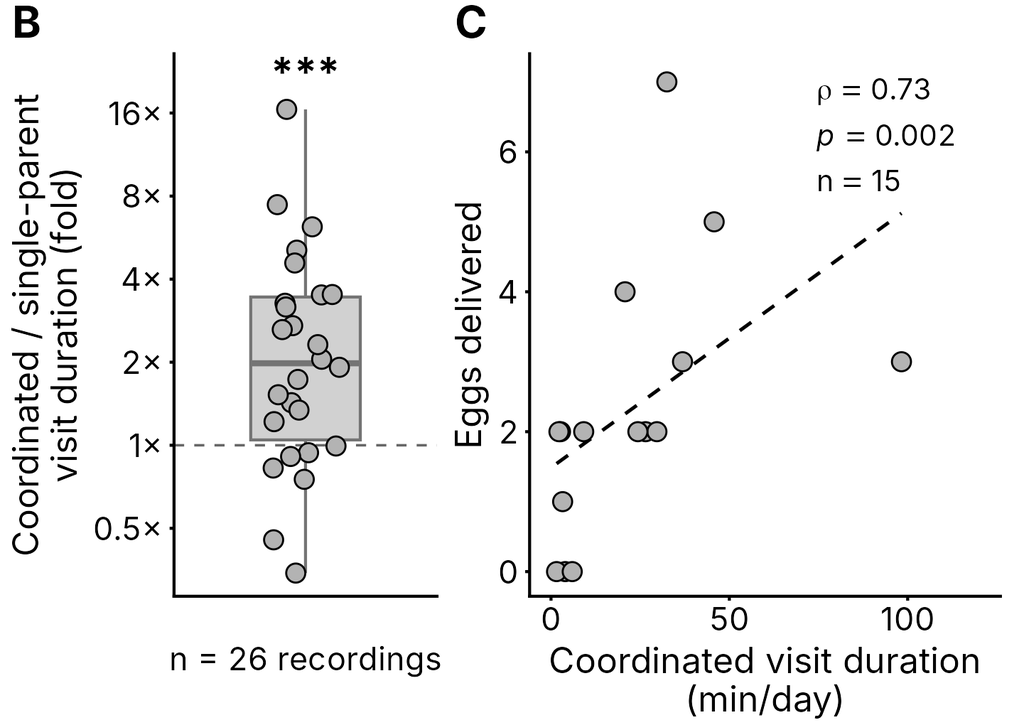

Figure 1, panels B and C. Panel A is drawn by hand and is not produced here.

## 3 Figure 2: the CarePC1 coordination index, care level and each parent’s care

`Figure2_11162026.R` does everything for Figure 2. Its first half turns the visit table into per-day care rates, an index of coordinated care (CarePC1) and a High or Low care level for each recording; its second half draws the panels from the same objects.

### 3.1 Part 1: from six care rates to CarePC1 and High/Low care

1. **Six per-day care rates.** For each recording and visitor (father alone, mother alone, coordinated), visits are counted and minutes summed, then divided by the number of full recording days. For these rates only, single-parent visits longer than 6 hours are left out; coordinated visits are always kept.
2. **Six-metric PCA.** A first look at how recordings differ across all care. Each of the six rates is turned into a z-score across the 26 recordings and a PCA is run on all six.
3. **CarePC1, the coordination index.** Coordinated visits lead the six-metric PC1, but father visits load almost as heavily, so that axis mixes coordination with each parent’s solo care. To keep solo care free to be tested against coordination (Figure 2) and against naltrexone (Figure 5), the index uses the two coordinated rates only. Coordinated visits per day and coordinated minutes per day are each turned into a z-score, and CarePC1 is their first principal component, signed so that a higher score means more coordination. With two standardized variables this is (z of visits + z of minutes) divided by the square root of 2.
4. **Care level.** K-means with two clusters on CarePC1. The higher cluster is “High”, the other “Low”. The cutoff is halfway between the highest Low and the lowest High.
5. **Cumulative visits by day, and totals.** Per recording and visitor, visits are counted per recording day and accumulated; gap days are left blank. All visits are used here (no 6-hour filter), and the same is true of the minutes per day drawn in panels H to J.

### 3.2 Part 2: the panels

| Panel | What it shows | Test |
| --- | --- | --- |
| A | PCA of the six per-day care rates, recordings colored by care level | High vs Low on PC1: Wilcoxon rank-sum, AUC |
| B | CarePC1 per recording, ranked, with the k-means cutoff | none |
| C | Tadpole body length vs coordinated minutes per day | Spearman |
| D | A blank row for the photos of the three visit types (father only, mother only, coordinating), one heading each column below | none |
| E, F, G | Fathers, mothers, coordinated visits: cumulative visits over 30 days by care level (solid = High, dashed = Low) | Negative-binomial mixed model on daily visit counts |
| H, I, J | Fathers, mothers, coordinated visits: minutes per day by care level | Wilcoxon rank-sum |

By default the script leaves row D blank for the photos to be placed by hand. With `SHOW_PHOTOS <- TRUE` it draws them itself from `Figures/artwork/Figure2_firstpanel_v2.png`. The mixed model is `visits per day ~ care level + day + (1 + day | recording)`, negative-binomial; the day × care term is tested in a second model that adds the interaction. This step takes a minute or two.

**Code: Functions/Figure2_11162026.R**

```r
# FIGURE 2 -- coordination as a pair-level care phenotype
# Input : Supplementary/derived_tables/VisitDurations_byType_derived_v4.csv, Data/recording_metadata.csv
#         (and Figures/artwork/Figure2_firstpanel_v2.png if SHOW_PHOTOS is TRUE)
# Output: Figures/Figure2_11102026.pdf / .png
#         Supplementary/derived_tables/CarePCA_sixMetrics_loadings.csv, CarePCA_sixMetrics_scores.csv
#         Supplementary/derived_tables/CarePC1_classification.csv, CarePC1_rule.csv
#         Supplementary/derived_tables/CareSummary_bySex.csv, AccumulatingVisits_bySex.csv

suppressPackageStartupMessages({
  library(dplyr); library(tidyr)
  library(ggplot2); library(patchwork); library(lme4)
})

# ---------- Panel letters (change here to re-letter the whole figure) ----------
LETTER <- c(pca = "A", index = "B", growth = "C", photos = "D",
            father_visits  = "E", mother_visits  = "F", coord_visits  = "G",
            father_minutes = "H", mother_minutes = "I", coord_minutes = "J")

# ---------- Theme + palettes ----------
theme_nature <- theme_classic(base_size = 10, base_family = "sans") +
  theme(panel.grid = element_blank(),
        axis.line  = element_line(linewidth = 0.4),
        axis.ticks = element_line(linewidth = 0.4),
        axis.ticks.length   = unit(2, "pt"),
        plot.title          = element_text(face = "bold", size = 10, hjust = 0, margin = margin(b = 2)),
        plot.title.position = "plot",
        legend.background   = element_blank(),
        legend.key.size     = unit(0.75, "lines"),
        legend.text         = element_text(size = 9),
        axis.title          = element_text(size = 10),
        axis.text           = element_text(size = 9))
theme_set(theme_nature)

CARE_PALETTE <- c("Low" = "#B2E4DB", "High" = "#005F52")
SEX_CARE_PALETTE <- c(
  "Male.High" = "#0077BB",  "Male.Low" = "#7FBBDD",
  "Female.High" = "#EE7733","Female.Low" = "#F6BB99",
  "Family.High" = "#005F52","Family.Low" = "#B2E4DB")
sex_care_pal <- function(s) c("High" = SEX_CARE_PALETTE[[paste0(s,".High")]],
                               "Low"  = SEX_CARE_PALETTE[[paste0(s,".Low")]])

darken_hex <- function(hex, amount = 0.35) {
  m  <- col2rgb(hex)                    # rgb2hsv() expects 0-255, not 0-1 (fixed in v20)
  h  <- rgb2hsv(m[1, ], m[2, ], m[3, ])
  v2 <- pmax(h["v", ] * (1 - amount), 0)
  out <- hsv(h["h", ], h["s", ], v2)
  names(out) <- names(hex)
  out
}
CARE_PALETTE_DARK     <- darken_hex(CARE_PALETTE)
SEX_CARE_PALETTE_DARK <- darken_hex(SEX_CARE_PALETTE)
sex_care_pal_dark <- function(s) c("High" = SEX_CARE_PALETTE_DARK[[paste0(s,".High")]],
                                    "Low"  = SEX_CARE_PALETTE_DARK[[paste0(s,".Low")]])

# ---------- Where things live ----------

repo_dir <- here::here()
derived   <- file.path(repo_dir, "Supplementary", "derived_tables")
fig_dir   <- file.path(repo_dir, "Figures")
meta_file <- file.path(repo_dir, "Data", "recording_metadata.csv")
dir.create(derived, showWarnings = FALSE, recursive = TRUE)
dir.create(fig_dir, showWarnings = FALSE, recursive = TRUE)

# visits analysis
# written by Figure1_ethogram_panels_11162026.R
visit_file <- file.path(derived, "VisitDurations_byType_derived_v4.csv")
if (!file.exists(visit_file)) stop("Run Figure1_ethogram_panels_11162026.R first: it writes ", visit_file)

LONG_SOLO_VISIT_MIN <- 360                      # 6 h cutoff for individual visits. this is because there's a very strong possibility that parents may fall asleep when the lights turn off
visitors <- c("Male", "Female", "Family")

visits <- read.csv(visit_file, stringsAsFactors = FALSE)
meta   <- read.csv(meta_file,  stringsAsFactors = FALSE)
recordings <- meta$ObservationID
full_days  <- setNames(meta$NumberofFullDays, recordings)
stopifnot(all(visits$tank %in% recordings))

# 6-variables
long_solo <- visits$visitor %in% c("Male", "Female") & visits$duration_min > LONG_SOLO_VISIT_MIN
kept      <- visits[!long_solo, ]
cat(sprintf("Left out of the per-day rates: %d of %d single-parent visits longer than %d min\n",
            sum(long_solo), nrow(visits), LONG_SOLO_VISIT_MIN))

#you should see that 28 uniparental visits are kicked off
count_by <- function(d) table(factor(d$tank, recordings), factor(d$visitor, visitors))
sum_by   <- function(d) {
  s <- tapply(d$duration_min, list(factor(d$tank, recordings), factor(d$visitor, visitors)), sum)
  s[is.na(s)] <- 0
  s
}
n_visits <- count_by(kept)
minutes  <- sum_by(kept)

care <- data.frame(ObservationID = recordings, Tank = meta$Pair,
                   NumberofFullDays = meta$NumberofFullDays, stringsAsFactors = FALSE)
for (v in visitors) care[[paste0("Visits_", v, "_perDay")]]  <- as.numeric(n_visits[, v]) / care$NumberofFullDays
for (v in visitors) care[[paste0("Minutes_", v, "_perDay")]] <- as.numeric(minutes[, v])  / care$NumberofFullDays

# 6-metric PCA
pop_sd      <- function(x) sqrt(mean((x - mean(x))^2))        # divide by n, not n - 1
z_score     <- function(X) sweep(sweep(X, 2, colMeans(X), "-"), 2, apply(X, 2, pop_sd), "/")
six_metrics <- c("Visits_Male_perDay", "Visits_Female_perDay", "Visits_Family_perDay",
                 "Minutes_Male_perDay", "Minutes_Female_perDay", "Minutes_Family_perDay")
pca6      <- prcomp(z_score(as.matrix(care[, six_metrics])), center = FALSE, scale. = FALSE)
pca6 #you should see that male visits epr day and family visits per day are around 0.52+
loadings6 <- pca6$rotation
scores6   <- pca6$x
if (loadings6["Visits_Family_perDay", 1] < 0) {               # PC1 points towards more coordinated visits
  loadings6[, 1] <- -loadings6[, 1]; scores6[, 1] <- -scores6[, 1]
}
var6 <- pca6$sdev^2 / sum(pca6$sdev^2)

cat(sprintf("Six-metric PCA: PC1 explains %.1f%% variance, PC2 %.1f%%. Loadings on PC1, largest first", #then run next line
            100 * var6[1], 100 * var6[2]))
print(round(sort(loadings6[, 1], decreasing = TRUE), 3))

#Visits_Family_perDay    Visits_Male_perDay   Minutes_Male_perDay Minutes_Female_perDay
#0.535                 0.517                 0.406                 0.367
#Visits_Female_perDay Minutes_Family_perDay
#0.312                 0.223
```

```r
pca_loadings <- data.frame(Variable = six_metrics, PC1 = loadings6[, 1], PC2 = loadings6[, 2],
                            VarExplained_PC1 = var6[1], VarExplained_PC2 = var6[2], row.names = NULL)
pca_scores   <- data.frame(ObservationID = care$ObservationID, PC1 = scores6[, 1], PC2 = scores6[, 2])

# To keep each parent's solo care free to be tested against coordination, the CAREPC1 index uses the two coordinated rates only.
family_vars <- c("Visits_Family_perDay", "Minutes_Family_perDay")
X       <- as.matrix(care[, family_vars])
centre  <- colMeans(X)                                         # kept: the other cohorts are scored with these
spread  <- apply(X, 2, pop_sd)
Z       <- z_score(X)
pca     <- prcomp(Z, center = FALSE, scale. = FALSE)
loading <- pca$rotation[, 1]
if (loading[1] < 0) loading <- -loading                        # higher = more coordination
care$CarePC1 <- as.numeric(Z %*% loading)
var_explained <- pca$sdev^2 / sum(pca$sdev^2)
var_explained

#establishing the care rule from the carepc1 index
set.seed(42) #42 is canon in ML. there is no reason for it. comes from hitchhiker's guide to galaxy
km   <- kmeans(care$CarePC1, centers = 2, nstart = 20)
high <- which.max(tapply(care$CarePC1, km$cluster, mean))
care$CareLevel <- ifelse(km$cluster == high, "High", "Low")
cutoff <- (max(care$CarePC1[care$CareLevel == "Low"]) + min(care$CarePC1[care$CareLevel == "High"])) / 2
# cutoff is 0.1558056
care$bodylength    <- meta$BodyLength_mm
care$tadpoleweight <- meta$TadpoleWeight_g
care$gosnerstage   <- meta$GosnerStage
pca_scores <- pca_scores[order(care$Tank, care$ObservationID), ]
care <- care[order(care$Tank, care$ObservationID), ]
#keep in mind since you only uploaded 2 variables, the loadings are balanced
cat(sprintf("CarePC1 (coordinated visits and minutes only): explains %.1f%% of their variance; loadings %+.3f (visits), %+.3f (minutes)\n",
            100 * var_explained[1], loading[1], loading[2]))
cat(sprintf("Cutoff = %+.3f; High = %d, Low = %d\n", cutoff,
            sum(care$CareLevel == "High"), sum(care$CareLevel == "Low")))
#cutoff is 0.156, high = 11, low = 15.
rule <- data.frame(Variable = family_vars, Mean = centre, SD = spread, Loading = loading,
                   Threshold = c(cutoff, NA), VarExplained_PC1 = c(var_explained[1], NA),
                   row.names = NULL)

all_n   <- count_by(visits)
all_min <- sum_by(visits)
sm_long <- do.call(rbind, lapply(recordings, function(id) data.frame(
  ObservationID = id, Sex = visitors,
  TotalVisits = as.numeric(all_n[id, visitors]), TotalMinutes = as.numeric(all_min[id, visitors]),
  NumberofFullDays = full_days[[id]], stringsAsFactors = FALSE)))
sm_long$VisitsPerDay  <- sm_long$TotalVisits  / sm_long$NumberofFullDays
sm_long$MinutesPerDay <- sm_long$TotalMinutes / sm_long$NumberofFullDays

gap_days <- lapply(setNames(meta$GapDays, recordings), function(s) {
  if (is.na(s) || s == "") integer(0) else as.integer(strsplit(as.character(s), ";")[[1]])
})
last_day <- sapply(recordings, function(id)
  max(visits$day[visits$tank == id], full_days[[id]], na.rm = TRUE))
max_day  <- max(last_day)

acc_rows <- list()
for (id in recordings) for (v in visitors) {
  days    <- visits$day[visits$tank == id & visits$visitor == v]
  per_day <- tabulate(days[!is.na(days) & days >= 1], nbins = last_day[[id]])
  cum     <- as.numeric(cumsum(per_day))
  cum[seq_along(cum) %in% gap_days[[id]]] <- NA                # gap days are unknown, not zero
  cum     <- c(cum, rep(NA, max_day - length(cum)))
  acc_rows[[length(acc_rows) + 1]] <- data.frame(
    ObservationID = id, Sex = v, NumberofFullDays = full_days[[id]], TotalVisits = sum(per_day),
    setNames(as.list(cum), paste0("Day", seq_len(max_day))), stringsAsFactors = FALSE)
}
acc_wide <- do.call(rbind, acc_rows)

level <- care[, c("ObservationID", "CareLevel", "CarePC1")]
sm_long  <- merge(sm_long,  level, by = "ObservationID", sort = FALSE)
acc_wide <- merge(acc_wide, level, by = "ObservationID", sort = FALSE)

write.csv(pca_loadings, file.path(derived, "CarePCA_sixMetrics_loadings.csv"), row.names = FALSE)
write.csv(pca_scores,   file.path(derived, "CarePCA_sixMetrics_scores.csv"),   row.names = FALSE)
write.csv(care,         file.path(derived, "CarePC1_classification.csv"),      row.names = FALSE)
write.csv(rule,         file.path(derived, "CarePC1_rule.csv"),                row.names = FALSE)
write.csv(sm_long,      file.path(derived, "CareSummary_bySex.csv"),           row.names = FALSE)
write.csv(acc_wide,     file.path(derived, "AccumulatingVisits_bySex.csv"),    row.names = FALSE)

#figure 2
care$CareLevel     <- factor(care$CareLevel,     levels = c("Low","High"))
sm_long$CareLevel  <- factor(sm_long$CareLevel,  levels = c("Low","High"))
acc_wide$CareLevel <- factor(acc_wide$CareLevel, levels = c("Low","High"))
KMEANS_THRESHOLD   <- cutoff

#helper scripts
#fmt_p generates the p-values the figures will print.
fmt_p   <- function(p) {
  if (is.na(p)) return("n.a.")
  if (p < 0.001) return(sprintf("%.2e", p))
  sprintf("%.3f", p)
}
#sig_code is giving you the significance asterisks
sig_code <- function(p) {
  if (is.na(p)) return("n.a.")
  if (p < 0.001) "***" else if (p < 0.01) "**" else if (p < 0.05) "*" else "n.s."
}
# Minimal bottom-right Spearman-only callout used by the body-length panel.
# Built as a plotmath expression (parse=TRUE at the call site) so the
# rho glyph renders via the symbol font instead of a raw UTF-8 character,
# which this graphics device silently fails to convert (mbcsToSbcs).
spear_label_expr <- function(x, y, n) {
  rho <- cor(x, y, method="spearman")
  p   <- suppressWarnings(cor.test(x, y, method="spearman", exact=FALSE)$p.value)
  # Each line wrapped in displaystyle() so nesting atop() inside atop()
  # doesn't auto-shrink the inner two lines relative to the first --
  # otherwise "p = ..." renders visibly larger than "rho = ..."/"n = ..."
  # even though all three use the same "==" spacing in the source.
  sprintf("atop(displaystyle(italic(p) == %s), atop(displaystyle(rho == %.2f), displaystyle(italic(n) == %d)))",
          fmt_p(p), rho, n)
}
```

```r
#panel A
load   <- pca_loadings; rownames(load) <- load$Variable
ev_pct <- 100 * c(load$VarExplained_PC1[1], load$VarExplained_PC2[1])
ev_pct
d_pca  <- merge(pca_scores, care[, c("ObservationID", "CareLevel")], by = "ObservationID", sort = FALSE)
d_pca
mw  <- suppressWarnings(wilcox.test(PC1 ~ CareLevel, data=d_pca))
#Wilcoxon rank sum exact test
#data:  PC1 by CareLevel
#W = 14, p-value = 0.0001297
#alternative hypothesis: true location shift is not equal to 0

.auc <- function(a,b) { p <- expand.grid(a=a,b=b); mean(p$a>p$b)+0.5*mean(p$a==p$b) }
auc_val <- .auc(d_pca$PC1[d_pca$CareLevel=="High"], d_pca$PC1[d_pca$CareLevel=="Low"])
#auc_val is 0.915

# Proper "1 x 10^-4"-style plotmath label instead of "p=1e-04"
pval <- mw$p.value
pca_stat_label <- if (pval < 1e-3) {
  pv_exp  <- floor(log10(pval))
  pv_mant <- pval / 10^pv_exp
  if (abs(pv_mant - round(pv_mant)) < 0.05) {
    sprintf("italic(p) == %.0f %%*%% 10^%d", round(pv_mant), pv_exp)
  } else {
    sprintf("italic(p) == %.1f %%*%% 10^%d", pv_mant, pv_exp)
  }
} else {
  sprintf("italic(p) == %.3f", pval)
}
pca_stat_label <- c(sprintf("AUC == %.2f", max(auc_val, 1 - auc_val)), pca_stat_label)   # two lines: AUC, then p

cat(sprintf("[Panel %s | Six-metric PCA: PC1 %.1f%%, PC2 %.1f%% of variance; loadings on PC1: %s]\n",
    LETTER[["pca"]], ev_pct[1], ev_pct[2],
    paste(sprintf("%s %.2f", load$Variable, load$PC1)[order(-load$PC1)], collapse = ", ")))
#Six-metric PCA: PC1 37.7%, PC2 24.6% of variance; loadings on PC1: Visits_Family_perDay 0.53, Visits_Male_perDay 0.52, Minutes_Male_perDay 0.41, Minutes_Female_perDay 0.37, Visits_Female_perDay 0.31, Minutes_Family_perDay 0.22]
cat(sprintf("  High vs Low care (CarePC1) on PC1 (n=%d): AUC=%.3f, Wilcoxon p=%.3g\n\n",
    nrow(d_pca), max(auc_val, 1-auc_val), mw$p.value))

SHOW_VARS  <- c("Visits_Male_perDay","Visits_Female_perDay","Visits_Family_perDay")
SHOW_LBLS  <- c("Visits Male","Visits Female","Visits Family")
HIGHLIGHT  <- c("Visits Male","Visits Family")
ARROW_SCALE <- 2.4
loadings_show <- data.frame(var=SHOW_LBLS, L1=load[SHOW_VARS,"PC1"], L2=load[SHOW_VARS,"PC2"]) |>
  mutate(highlight=var %in% HIGHLIGHT,
         x_end=L1*ARROW_SCALE, y_end=L2*ARROW_SCALE,
         x_lab=x_end*1.18,     y_lab=y_end*1.18,
         # the father and coordinated arrows nearly coincide: move their labels apart
         y_lab=y_lab + c("Visits Male"=-0.75, "Visits Female"=0.35, "Visits Family"=0.45)[var])

panel_pca <- ggplot(d_pca, aes(PC1, PC2)) +
  stat_ellipse(aes(fill=CareLevel, color=CareLevel),
               geom="polygon", level=0.95, alpha=0.18, linewidth=0.5) +
  geom_hline(yintercept=0, color="grey80", linewidth=0.2) +
  geom_vline(xintercept=0, color="grey80", linewidth=0.2) +
  geom_point(aes(fill=CareLevel, color=CareLevel), shape=21, size=2.4, stroke=0.4) +
  geom_segment(data=loadings_show,
               aes(x=0, y=0, xend=x_end, yend=y_end,
                   color=ifelse(highlight,"highlight","other"),
                   linewidth=ifelse(highlight,1.0,0.5)),
               arrow=arrow(length=unit(0.13,"cm"), type="closed"),
               inherit.aes=FALSE, show.legend=FALSE) +
  geom_label(data=loadings_show,
             aes(x=x_lab, y=y_lab, label=var,
                 fontface=ifelse(highlight,"bold","plain")),
             color="black", fill="white", size=2.5,
             label.size=0.2, label.padding=unit(0.10,"lines"),
             inherit.aes=FALSE, show.legend=FALSE) +
  scale_fill_manual(values=CARE_PALETTE, guide="none") +
  scale_color_manual(values=c(highlight="#CC3311", other="black",
                                Low=CARE_PALETTE_DARK[["Low"]], High=CARE_PALETTE_DARK[["High"]]),
                      guide="none") +
  scale_linewidth_identity() +
  scale_y_continuous(expand=expansion(mult=c(0.05, 0.45))) +          # head-room for the AUC and p labels
  annotate("text", x=-Inf, y=Inf, hjust=-0.08, vjust=c(1.4, 2.7),
           label=pca_stat_label, parse=TRUE, size=3.0, color="black") +
  labs(x=sprintf("PC1: Coordination\nintensity (%.1f%%)",ev_pct[1]),          # plain ":" (a long dash does not print in the PDF)
       y=sprintf("PC2: Maternal- vs.\npaternal-weighted (%.1f%%)",ev_pct[2]),
       title=paste0(LETTER[["pca"]], ".")) +
  theme(legend.position="none",
        axis.title.x=element_text(size=7.3, lineheight=0.95),
        axis.title.y=element_text(size=7.3, lineheight=0.95))
#panel b
d_index <- care |> select(ObservationID, CarePC1, CareLevel) |> arrange(CarePC1) |>
  mutate(ObservationID = factor(ObservationID, levels=ObservationID))
index_range <- range(d_index$CarePC1)
panel_index <- ggplot(d_index, aes(ObservationID, CarePC1, fill=CareLevel, color=CareLevel)) +
  geom_col(linewidth=0.3) +
  geom_hline(yintercept=KMEANS_THRESHOLD, color="red", linetype="dashed", linewidth=0.5) +
  annotate("text", x=0.6, y=KMEANS_THRESHOLD+0.12,
           label=sprintf("cutoff\n%+.2f", KMEANS_THRESHOLD), color="red", size=2.8,
           hjust=0, vjust=0, lineheight=0.9) +
  annotate("text", x=nlevels(d_index$ObservationID)*0.18, y=index_range[2]*0.82,
           label="High", color=CARE_PALETTE_DARK[["High"]],
           fontface="bold", size=2.9, hjust=0) +
  annotate("segment", x=nlevels(d_index$ObservationID)*0.10, xend=nlevels(d_index$ObservationID)*0.10,
           y=index_range[2]*0.45, yend=index_range[2]*0.78,
           color=CARE_PALETTE_DARK[["High"]], linewidth=0.6,
           arrow=arrow(length=unit(0.10,"cm"), type="closed")) +
  annotate("text", x=nlevels(d_index$ObservationID)*0.70, y=index_range[1]*0.80,
           label="Low", color=CARE_PALETTE_DARK[["Low"]],
           fontface="bold", size=2.9, hjust=0) +
  annotate("segment", x=nlevels(d_index$ObservationID)*0.64, xend=nlevels(d_index$ObservationID)*0.64,
           y=index_range[1]*0.40, yend=index_range[1]*0.75,
           color=CARE_PALETTE_DARK[["Low"]], linewidth=0.6,
           arrow=arrow(length=unit(0.10,"cm"), type="closed")) +
  scale_fill_manual(values=CARE_PALETTE, guide="none") +
  scale_color_manual(values=CARE_PALETTE_DARK, guide="none") +
  labs(x="Recordings", y="CarePC1", title=paste0(LETTER[["index"]], ".")) +
  theme(axis.text.x=element_blank(), axis.ticks.x=element_blank())
```

```r
# panel c
d_growth <- care |> select(Minutes_Family_perDay, bodylength, CareLevel) |> drop_na()
panel_growth <- ggplot(d_growth, aes(Minutes_Family_perDay, bodylength)) +
  geom_smooth(method="lm", se=FALSE, color="black", linetype="dashed", linewidth=0.5) +
  geom_point(aes(fill=CareLevel, color=CareLevel), shape=21, size=2.6, stroke=0.4) +
  annotate("text", x=Inf, y=-Inf, hjust=1.05, vjust=-0.15,
           label=spear_label_expr(d_growth$Minutes_Family_perDay, d_growth$bodylength, nrow(d_growth)),
           parse=TRUE, size=2.9, lineheight=0.9) +
  scale_fill_manual(values=CARE_PALETTE, guide="none") +
  scale_color_manual(values=CARE_PALETTE_DARK, guide="none") +
  labs(x="Coordinated visit\nduration (min/day)", y="Body length (mm)", title=paste0(LETTER[["growth"]], ".")) +
  theme(legend.position="none")

cat(sprintf(paste0("[Panel ", LETTER[["growth"]], " | Body length x coordinated minutes per day  (n=%d)]\n",
    "  Pearson:  r=%+.3f, p=%.3g\n",
    "  Spearman: rho=%+.3f, p=%.3g\n\n"),
  nrow(d_growth),
  cor(d_growth$Minutes_Family_perDay, d_growth$bodylength),
  cor.test(d_growth$Minutes_Family_perDay, d_growth$bodylength)$p.value,
  cor(d_growth$Minutes_Family_perDay, d_growth$bodylength, method="spearman"),
  suppressWarnings(cor.test(d_growth$Minutes_Family_perDay, d_growth$bodylength,
                            method="spearman", exact=FALSE)$p.value)))

#[Panel C | Body length x coordinated minutes per day  (n=23)]
#Pearson:  r=+0.423, p=0.0442
#Spearman: rho=+0.579, p=0.00381


# panel D
photo_file <- file.path(repo_dir, "Figures", "artwork", "Figure2_firstpanel_v2.png")
photo_panel <- function(piece, letter = NULL) {
  p <- ggplot() + theme_void()
  if (!is.null(piece))
    p <- p + annotation_custom(grid::rasterGrob(piece, height = grid::unit(1, "npc"), interpolate = TRUE))
  if (!is.null(letter))
    p <- p + labs(title = paste0(letter, ".")) +
      theme(plot.title = element_text(face = "bold", size = 10, hjust = 0, margin = margin(b = 2)))
  p
}
SHOW_PHOTOS <- FALSE   # FALSE: leave a placeholder
                       # TRUE : draw the photos from the artwork file
if (SHOW_PHOTOS && file.exists(photo_file)) {
  strip  <- png::readPNG(photo_file)
  inked  <- apply(strip[, , 1:3], 2, function(column) any(column < 0.98))   # columns that are not blank white
  runs   <- rle(inked)
  ends   <- cumsum(runs$lengths); starts <- ends - runs$lengths + 1
  keep   <- which(runs$values)
  stopifnot(length(keep) == 3)                                              # father, mother, coordinating
  pieces <- lapply(keep, function(i) strip[, starts[i]:ends[i], , drop = FALSE])
} else {
  pieces <- list(NULL, NULL, NULL)                                          # blank row, lettered D
}
panel_photo_father <- photo_panel(pieces[[1]], LETTER[["photos"]])
panel_photo_mother <- photo_panel(pieces[[2]])
panel_photo_coord  <- photo_panel(pieces[[3]])

# panels e-j
DAY_LIM  <- 30
day_cols <- grep("^Day[0-9]+$", names(acc_wide), value=TRUE)
acc_long <- acc_wide |>
  select(ObservationID, Sex, CareLevel, all_of(day_cols)) |>
  pivot_longer(all_of(day_cols), names_to="Day", values_to="Cum") |>
  mutate(Day=as.integer(sub("Day","",Day)),
         Sex=factor(Sex, levels=c("Male","Female","Family"))) |>
  filter(Day <= DAY_LIM)

acc_summary <- acc_long |>
  group_by(Sex, CareLevel, Day) |>
  summarise(med=median(Cum,na.rm=TRUE),
            q1=quantile(Cum,0.25,na.rm=TRUE),
            q3=quantile(Cum,0.75,na.rm=TRUE), .groups="drop")

acc_mm_dat <- acc_long |>
  filter(!is.na(Cum)) |>
  arrange(ObservationID, Sex, Day) |>
  group_by(ObservationID, Sex) |>
  mutate(VisitsPerDay = pmax(Cum - dplyr::lag(Cum, default=0), 0)) |>
  ungroup() |>
  mutate(DayC=Day-1, CareLevel=factor(CareLevel, levels=c("Low","High")))

# Visits per day: negative-binomial mixed model per visitor.
#   main model:        visits ~ care level + day + (1 + day | recording)
#   interaction model: visits ~ care level * day + (1 + day | recording)
cat("[Per-day visits | NB-GLMM -- CarePC1]\n")
glmm_stats <- data.frame(Sex=c("Male","Female","Family"),
                          p_care=NA_real_, RR_care=NA_real_,
                          p_day=NA_real_,  p_inter=NA_real_,
                          stringsAsFactors=FALSE)

for (sx in c("Male","Female","Family")) {
  d_sx <- acc_mm_dat |> filter(Sex == sx)

  fit_main <- suppressMessages(suppressWarnings(
    glmer.nb(VisitsPerDay ~ CareLevel + DayC + (1 + DayC | ObservationID),
             data=d_sx, control=glmerControl(optimizer="bobyqa",
                                              optCtrl=list(maxfun=200000)))))
  cf <- summary(fit_main)$coefficients
  i_care <- grep("^CareLevelHigh$", rownames(cf))[1]
  i_day  <- grep("^DayC$",          rownames(cf))[1]

  fit_inter <- tryCatch(suppressMessages(suppressWarnings(
    glmer.nb(VisitsPerDay ~ CareLevel * DayC + (1 + DayC | ObservationID),
             data=d_sx, control=glmerControl(optimizer="bobyqa",
                                              optCtrl=list(maxfun=200000))))),
    error=function(e) NULL)
  p_inter <- if (!is.null(fit_inter)) {
    cf_i <- summary(fit_inter)$coefficients
    cf_i[grep(":", rownames(cf_i))[1], "Pr(>|z|)"]
  } else NA_real_

  glmm_stats[glmm_stats$Sex==sx,] <- list(sx,
    cf[i_care,"Pr(>|z|)"], exp(cf[i_care,"Estimate"]),
    cf[i_day, "Pr(>|z|)"], p_inter)

  cat(sprintf("  %-6s  Care: RR=%.2fx, p=%.3g | Day: p=%.3g | Day x Care: p=%.3g\n",
    sx, exp(cf[i_care,"Estimate"]), cf[i_care,"Pr(>|z|)"],
    cf[i_day,"Pr(>|z|)"], p_inter))
}

get_p_care  <- function(s) glmm_stats$p_care[ glmm_stats$Sex==s]
get_p_day   <- function(s) glmm_stats$p_day[  glmm_stats$Sex==s]
get_p_inter <- function(s) glmm_stats$p_inter[ glmm_stats$Sex==s]

# Cumulative visits over 30 days (median and quartiles by care level)
panel_traj <- function(sex_lbl, letter, pretty=sex_lbl) {
  d   <- acc_summary |> filter(Sex==sex_lbl)
  pal <- sex_care_pal(sex_lbl)
  pmm <- get_p_care(sex_lbl)
  dp  <- get_p_day(sex_lbl);  ip <- get_p_inter(sex_lbl)
  stats_lab <- paste(
    sprintf("Care %s", sig_code(pmm)),
    sprintf("Day %s", sig_code(dp)),
    sprintf("Day \u00d7 Care %s", sig_code(ip)),                               # \u00d7 = multiplication sign, written this way so it prints in the PDF on any computer
    sep="\n")
  ggplot(d, aes(Day, med, color=CareLevel, fill=CareLevel, linetype=CareLevel)) +
    geom_ribbon(aes(ymin=q1, ymax=q3), color=NA, alpha=0.25) +
    geom_line(linewidth=0.9) +
    annotate("text", x=1, y=Inf, hjust=0, vjust=1.3,
             label=stats_lab, size=2.9, fontface="bold", lineheight=1.25) +
    scale_color_manual(values=pal, guide="none") +
    scale_fill_manual(values=pal, guide="none") +
    scale_linetype_manual(values=c(High="solid",Low="dashed"), guide="none") +
    scale_x_continuous(breaks=c(1,10,20,30), limits=c(1,DAY_LIM)) +
    scale_y_continuous(expand=expansion(mult=c(0.05, 0.50))) +             # head-room for the three test results
    labs(x="Day", y="Cumulative visits", title=sprintf("%s.", letter))
}
```

```r
# Minutes per day by care level

panel_min_box <- function(sex_lbl, letter, pretty=sex_lbl) {
  d  <- sm_long |> filter(Sex==sex_lbl) |> drop_na(MinutesPerDay)
  hi <- d$MinutesPerDay[d$CareLevel=="High"]; lo <- d$MinutesPerDay[d$CareLevel=="Low"]
  pw <- suppressWarnings(wilcox.test(d$MinutesPerDay ~ d$CareLevel)$p.value)
  sig  <- sig_code(pw)
  ymax <- max(d$MinutesPerDay, na.rm=TRUE)
  pal <- sex_care_pal(sex_lbl); pal_dark <- sex_care_pal_dark(sex_lbl)
  ticks <- c(Low=sprintf("Low\n(n=%d)",length(lo)), High=sprintf("High\n(n=%d)",length(hi)))
  ggplot(d, aes(CareLevel, MinutesPerDay, fill=CareLevel, color=CareLevel)) +
    geom_boxplot(width=0.55, alpha=0.55, outlier.shape=NA, linewidth=0.6, fatten=1.4) +
    geom_point(shape=21, stroke=0.4, size=1.6,
               position=position_jitter(width=0.07, height=0, seed=1)) +   # seed: same sideways jitter every run
    annotate("text", x=1.5, y=ymax*1.08, label=sig, size=4.5, fontface="bold") +
    scale_fill_manual(values=pal, guide="none") +
    scale_color_manual(values=pal_dark, guide="none") +
    scale_y_continuous(expand=expansion(mult=c(0.05,0.14))) +
    scale_x_discrete(labels=ticks) +
    labs(x=NULL, y=sprintf("%s minutes / day", pretty), title=sprintf("%s.", letter))
}

panel_father_visits  <- panel_traj("Male",      LETTER[["father_visits"]],  "Father")
panel_father_minutes <- panel_min_box("Male",   LETTER[["father_minutes"]], "Father")
panel_mother_visits  <- panel_traj("Female",    LETTER[["mother_visits"]],  "Mother")
panel_mother_minutes <- panel_min_box("Female", LETTER[["mother_minutes"]], "Mother")
panel_coord_visits   <- panel_traj("Family",    LETTER[["coord_visits"]],   "Family")
panel_coord_minutes  <- panel_min_box("Family", LETTER[["coord_minutes"]],  "Family")

cat("[Minutes/day | Wilcoxon rank-sum -- CarePC1]\n")
for (box_row in list(c("Male",LETTER[["father_minutes"]],"Father"), c("Female",LETTER[["mother_minutes"]],"Mother"), c("Family",LETTER[["coord_minutes"]],"Family"))) {
  d_box  <- sm_long |> filter(Sex == box_row[1]) |> drop_na(MinutesPerDay)
  hi_box <- d_box$MinutesPerDay[d_box$CareLevel == "High"]
  lo_box <- d_box$MinutesPerDay[d_box$CareLevel == "Low"]
  pw_box <- suppressWarnings(wilcox.test(d_box$MinutesPerDay ~ d_box$CareLevel)$p.value)
  d_eff  <- (mean(hi_box) - mean(lo_box)) /
    sqrt(((length(hi_box)-1)*var(hi_box) + (length(lo_box)-1)*var(lo_box)) /
         (length(hi_box) + length(lo_box) - 2))
  cat(sprintf("  %s (Panel %s): p=%.3g, d=%+.2f  %s\n",
      box_row[3], box_row[2], pw_box, d_eff, sig_code(pw_box)))
}
cat("\n")

row1 <- (panel_pca | panel_index | panel_growth) + plot_layout(widths=c(1.8, 1.2, 1.5))

# Rows 2 to 4: one column per visit type -- photo, cumulative visits, minutes per day. Built as one grid so each photo is centered over its own plots
columns <- (panel_photo_father  | panel_photo_mother  | panel_photo_coord) /
           (panel_father_visits | panel_mother_visits | panel_coord_visits) /
           (panel_father_minutes | panel_mother_minutes | panel_coord_minutes) +
  plot_layout(heights=c(1.6, 2.2, 2.0))

# Sizes in inches
FIG_W <- 5.2043       # inches (was 8.5)
ROW_H <- c(index = 2.5, columns = 1.6 + 2.2 + 2.0)
fig2 <- (wrap_elements(full = row1) / wrap_elements(full = columns)) +
  plot_layout(heights = ROW_H) & theme(plot.margin=margin(3,5,3,5))

fig2

ggsave(file.path(fig_dir,"Figure2_11102026.png"), fig2, width=FIG_W, height=sum(ROW_H), dpi=300, bg="white")
ggsave(file.path(fig_dir,"Figure2_11102026.pdf"), fig2, width=FIG_W, height=sum(ROW_H))
cat("Saved Figure2_11102026 to", fig_dir, "\n")
```

```r
run_step("Figure2_11162026.R")
```

```
Left out of the per-day rates: 28 of 5805 single-parent visits longer than 360 min
Six-metric PCA: PC1 explains 37.7% variance, PC2 24.6%. Loadings on PC1, largest first Visits_Family_perDay    Visits_Male_perDay   Minutes_Male_perDay
                0.535                 0.517                 0.406
Minutes_Female_perDay  Visits_Female_perDay Minutes_Family_perDay
                0.367                 0.312                 0.223
CarePC1 (coordinated visits and minutes only): explains 61.2% of their variance; loadings +0.707 (visits), +0.707 (minutes)
Cutoff = +0.156; High = 11, Low = 15
[Panel A | Six-metric PCA: PC1 37.7%, PC2 24.6% of variance; loadings on PC1: Visits_Family_perDay 0.53, Visits_Male_perDay 0.52, Minutes_Male_perDay 0.41, Minutes_Female_perDay 0.37, Visits_Female_perDay 0.31, Minutes_Family_perDay 0.22]
  High vs Low care (CarePC1) on PC1 (n=26): AUC=0.915, Wilcoxon p=0.00013

[Panel C | Body length x coordinated minutes per day  (n=23)]
  Pearson:  r=+0.423, p=0.0442
  Spearman: rho=+0.579, p=0.00381

[Per-day visits | NB-GLMM -- CarePC1]
  Male    Care: RR=1.61x, p=0.000652 | Day: p=6.65e-07 | Day x Care: p=0.0275
  Female  Care: RR=1.10x, p=0.368 | Day: p=0.191 | Day x Care: p=0.397
  Family  Care: RR=2.52x, p=1.15e-05 | Day: p=0.228 | Day x Care: p=0.764
[Minutes/day | Wilcoxon rank-sum -- CarePC1]
  Father (Panel H): p=0.0077, d=+0.57  **
  Mother (Panel I): p=0.54, d=+0.43  n.s.
  Family (Panel J): p=1.81e-06, d=+1.82  ***
```

```
Saved Figure2_11102026 to ./Figures
```

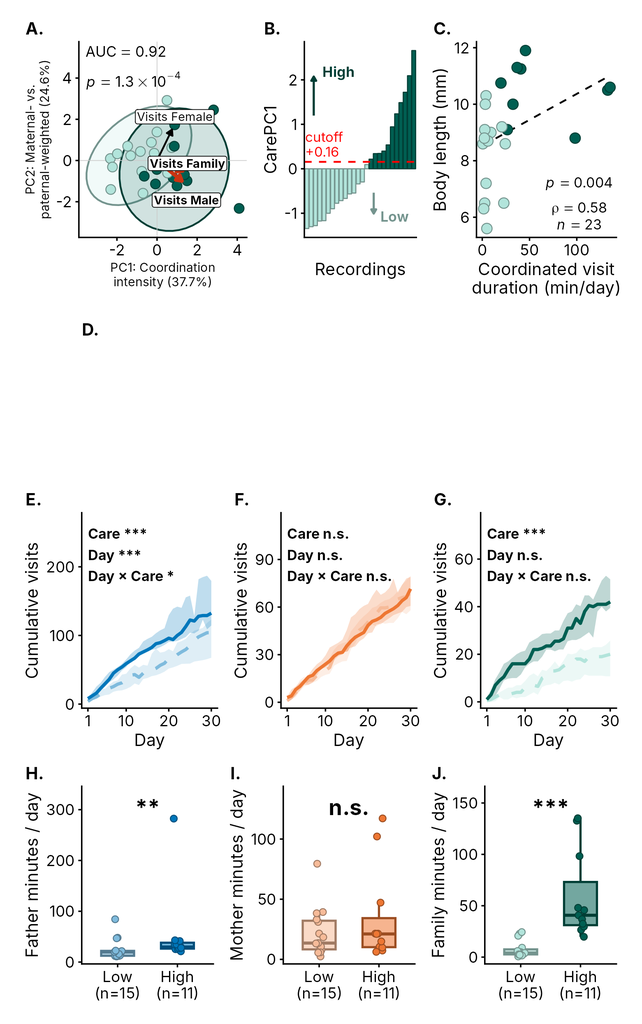

Figure 2.

The numbers that define CarePC1 (means, SDs and loadings of the two coordinated rates, and the High/Low cutoff):

**Code: the CarePC1 rule**

```r
kable(derived("CarePC1_rule.csv"), digits = 3)
```

| Variable | Mean | SD | Loading | Threshold | VarExplained_PC1 |
| --- | --- | --- | --- | --- | --- |
| Visits_Family_perDay | 1.175 | 0.849 | 0.707 | 0.156 | 0.612 |
| Minutes_Family_perDay | 29.175 | 37.017 | 0.707 | NA | NA |

Loadings of the six-metric PCA (panel A):

**Code: six-metric PCA loadings**

```r
kable(derived("CarePCA_sixMetrics_loadings.csv"), digits = 3)
```

| Variable | PC1 | PC2 | VarExplained_PC1 | VarExplained_PC2 |
| --- | --- | --- | --- | --- |
| Visits_Male_perDay | 0.517 | -0.413 | 0.377 | 0.246 |
| Visits_Female_perDay | 0.312 | 0.626 | 0.377 | 0.246 |
| Visits_Family_perDay | 0.535 | -0.208 | 0.377 | 0.246 |
| Minutes_Male_perDay | 0.406 | -0.146 | 0.377 | 0.246 |
| Minutes_Female_perDay | 0.367 | 0.596 | 0.377 | 0.246 |
| Minutes_Family_perDay | 0.223 | -0.130 | 0.377 | 0.246 |

### 3.3 The same rule applied to the other cohorts

CarePC1 is defined once, on the 26 reference recordings. Every other cohort is scored with the stored means, SDs, loadings and cutoff, so High and Low mean the same thing in every figure. Each cohort is scored at the start of its own figure script: the TadBot tanks in the Figure 3 script, the naltrexone tanks and the RNAscope pairs in the Figure 5 script.

[output not shown]

The RNAscope event logs are read by the same code and the same correction rules as the reference recordings.

## 4 Figure 3: tadpole begging and the TadBot

| Panel | What it shows | Test |
| --- | --- | --- |
| B | Distribution of peak frequency for begging, wiggling and the TadBot | none |
| C | Mean peak frequency per individual | Begging vs wiggling: paired t-test; begging vs TadBot: Mann-Whitney |
| D | Cumulative parental visits over the 14 trial days, TadBot off (0 Hz) vs on (15 Hz): the mean visits per tank on each day, accumulated, ± 1 SE across tanks (jackknife). The dashed line marks the day on… | Negative-binomial mixed model on daily visits, `visits ~ TadBot × day + (1 \| tank)` |
| E | The same for coordinated visits only | The same model on daily coordinated visits |

The script also prints two comparisons over the first three trial days alone (paired t-tests across the six tanks): all visits per day, and CarePC1.

**Code: Functions/Figure3_11162026.R**

```r
# Figure3
# Inputs
#   Data/begging_frequency/combinedbegginpeakfreq_v2.xlsx  sheet "refined"
#       one row per behaviour bout: its peak frequency
#   Data/begging_frequency/averagedbeggingpeaks.xlsx       sheet "Sheet1"
#       one row per individual and behaviour: its mean peak frequency
#   Data/tadbot/TadBot_posvnegctrl_v2.xlsx                 sheet "raw_data"
#       one row per nest visit: tank, treatment, trial day, visitor, duration
#   Supplementary/derived_tables/CarePC1_rule.csv   the CarePC1 rule
# Output: Figures/Figure3_11112026.png + .pdf
#   Supplementary/derived_tables/TadBot_dailyVisits.csv  visits per tank, treatment and trial day (panels D, E)
#   Supplementary/derived_tables/TadBot_first3days.csv   per tank and treatment, first three days (printed tests)

suppressPackageStartupMessages({
  library(readxl); library(dplyr); library(tidyr)
  library(ggplot2); library(patchwork)   # panels D and E also need lme4 (called as lme4::glmer.nb)
})

# ---------- Theme + palettes ----------
theme_nature <- theme_classic(base_size = 12, base_family = "sans") +
  theme(panel.grid        = element_blank(),
        axis.line         = element_line(linewidth = 0.4),
        axis.ticks        = element_line(linewidth = 0.4),
        axis.ticks.length = unit(2, "pt"),
        plot.title        = element_blank(),
        plot.title.position = "plot",
        legend.background = element_blank(),
        legend.key.size   = unit(0.9, "lines"),
        legend.text       = element_text(size = 10),
        axis.title        = element_text(size = 12),
        axis.text         = element_text(size = 10))
theme_set(theme_nature)

FREQ_PALETTE <- c("Begging" = "#882255", "Wiggling" = "#DDAACC", "Robotad" = "#CC3311")

darken_hex <- function(hex, amount = 0.35) {
  m  <- col2rgb(hex)
  h  <- rgb2hsv(m[1, ], m[2, ], m[3, ])
  v2 <- pmax(h["v", ] * (1 - amount), 0)
  out <- hsv(h["h", ], h["s", ], v2)
  names(out) <- names(hex)
  out
}

C_PALETTE      <- c("Begging" = "#882255", "Wiggling" = "#DDAACC", "TadBot" = "#CC3311")
C_PALETTE_DARK <- darken_hex(C_PALETTE)

repo_dir <- here::here()
fig_dir  <- file.path(repo_dir, "Figures")
dir.create(fig_dir, showWarnings = FALSE, recursive = TRUE)

fp_freq   <- file.path(repo_dir, "Data", "begging_frequency", "combinedbegginpeakfreq_v2.xlsx")
fp_avg    <- file.path(repo_dir, "Data", "begging_frequency", "averagedbeggingpeaks.xlsx")
fp_tadbot <- file.path(repo_dir, "Supplementary", "derived_tables", "TadBot_first3days.csv")
fp_daily  <- file.path(repo_dir, "Supplementary", "derived_tables", "TadBot_dailyVisits.csv")

# TadBot tables
# One row per visit. Each tank was recorded with the TadBot moving at 15 Hz ("TadBot") and not moving ("NegCtrl"). A recorded day with no visits has one row with no visitor; a day with no row at all was not recorded.
local({
  raw_dir <- file.path(repo_dir, "Data")
  source(file.path(repo_dir, "Functions", "shared_functions.R"), local = TRUE)
  rule <- load_care_rule(file.path(repo_dir, "Supplementary", "derived_tables", "CarePC1_rule.csv"))

  # min in duration cell (read by readxl as a clock time)
  clock_minutes <- function(x) as.numeric(format(x, "%H", tz = "UTC")) * 60 +
                               as.numeric(format(x, "%M", tz = "UTC")) +
                               as.numeric(format(x, "%S", tz = "UTC")) / 60

  tadbot <- suppressWarnings(as.data.frame(
    read_excel(file.path(raw_dir, "tadbot", "TadBot_posvnegctrl_v2.xlsx"), sheet = "raw_data")))
  paired_tanks <- names(which(table(unique(tadbot[, c("Tank", "Treatment")])$Tank) == 2))   # recorded under both treatments

  # 1a. Visits on each recorded trial day, days 1 to 14 (Figure 3D and E)
  tb_days <- unique(tadbot[tadbot$Tank %in% paired_tanks & tadbot$day_trial %in% 1:14, c("Tank", "Treatment", "day_trial")])
  count_visits <- function(who) mapply(function(tank, treatment, day)
    sum(tadbot$Tank == tank & tadbot$Treatment == treatment & tadbot$day_trial == day & tadbot$sex %in% who),
    tb_days$Tank, tb_days$Treatment, tb_days$day_trial)
  tb_daily <- data.frame(Tank = tb_days$Tank, Treatment = tb_days$Treatment, TrialDay = tb_days$day_trial,
                         AllVisits     = count_visits(c("Male", "Female", "Family")),
                         Visits_Male   = count_visits("Male"),
                         Visits_Female = count_visits("Female"),
                         Visits_Family = count_visits("Family"))
  tb_daily <- tb_daily[order(tb_daily$Tank, tb_daily$Treatment, tb_daily$TrialDay), ]
  write.csv(tb_daily, fp_daily, row.names = FALSE)

  # 1b. First three trial days. For each tank and treatment, visits on trial days 1 to 3 are counted and divided by the number of those days that were recorded (C7 under TadBot has only 2 days).
  tadbot <- tadbot[tadbot$day_trial %in% 1:3, ]
  tadbot$minutes <- clock_minutes(tadbot$timedifference)
  groups <- unique(tadbot[, c("Tank", "Treatment")])
  tb_rows <- lapply(seq_len(nrow(groups)), function(i) {
    d      <- tadbot[tadbot$Tank == groups$Tank[i] & tadbot$Treatment == groups$Treatment[i], ]
    n_days <- length(unique(d$day_trial))        # a recorded day with no visits has a row with no visitor
    d      <- d[!is.na(d$sex), ]
    family <- d[d$sex == "Family", ]
    data.frame(Tank = groups$Tank[i], Treatment = groups$Treatment[i], DaysRecorded = n_days,
               AllVisits_perDay      = nrow(d) / n_days,
               Visits_Family_perDay  = nrow(family) / n_days,
               Minutes_Family_perDay = sum(family$minutes) / n_days)
  })
  tb <- do.call(rbind, tb_rows)
  tb$CarePC1 <- rule$care_pc1(tb$Visits_Family_perDay, tb$Minutes_Family_perDay)
  tb <- tb[order(tb$Tank, tb$Treatment), ]
  both <- names(which(table(tb$Tank) == 2))      # tanks recorded under both treatments
  tb <- tb[tb$Tank %in% both, ]
  write.csv(tb, fp_tadbot, row.names = FALSE)
  cat(sprintf("TadBot: %d tanks recorded under both treatments\n", length(both)))
})

#TadBot: 6 tanks recorded under both treatments

#figure 3
stopifnot(file.exists(fp_freq), file.exists(fp_avg), file.exists(fp_tadbot), file.exists(fp_daily))
```

```r
tadbot   <- read.csv(fp_tadbot)
freq_dat <- read_excel(fp_freq,  sheet = "refined") |>
  filter(!is.na(Behavior), !is.na(X)) |>
  mutate(Behavior = factor(Behavior, levels = c("Begging","Wiggling","Robotad")))
freq_avg <- read_excel(fp_avg,   sheet = "Sheet1") |>
  filter(!is.na(Behavior), !is.na(X)) |>
  mutate(Behavior = factor(Behavior, levels = c("Begging","Wiggling","Robotad")))

tb_pvn <- tadbot |>
  select(Tank, Treatment, AllVisits_perDay) |>
  pivot_wider(names_from = Treatment, values_from = AllVisits_perDay) |>
  drop_na(NegCtrl, TadBot)


cat("Figure 3 -- behaviors: ", nrow(freq_dat), " (",
    paste(names(table(freq_dat$Behavior)), table(freq_dat$Behavior), collapse = ", "), ")\n", sep = "")
#Figure 3 -- behaviors: 236 (Begging 136, Wiggling 74, Robotad 26)
# helperscripts
make_blank <- function(letter, sub = "Illustrator overlay", show_title = TRUE) {
  p <- ggplot() +
    annotate("rect", xmin = 0, xmax = 1, ymin = 0, ymax = 1,
             fill = NA, color = "#cccccc", linetype = "dashed", linewidth = 0.5) +
    annotate("text", x = 0.5, y = 0.55, label = sprintf("[ %s ]", letter),
             color = "#aaaaaa", fontface = "italic", size = 3.0) +
    annotate("text", x = 0.5, y = 0.45, label = sub,
             color = "#aaaaaa", size = 2.4) +
    scale_x_continuous(limits = c(0, 1), expand = c(0, 0)) +
    scale_y_continuous(limits = c(0, 1), expand = c(0, 0)) +
    theme(axis.line = element_blank(), axis.text = element_blank(),
          axis.ticks = element_blank(), axis.title = element_blank(),
          panel.grid = element_blank(), panel.border = element_blank())
  if (show_title) p <- p + labs(title = letter)
  p
}

sigstr <- function(p) {
  if (is.na(p)) return("")
  if (p < 0.001) "***" else if (p < 0.01) "**" else if (p < 0.05) "*" else "n.s."
}

panelA <- make_blank("A. TadBot apparatus")

freq_n      <- freq_dat |> count(Behavior) |>                       # the data call the TadBot "Robotad"
  mutate(label = sprintf("%s (n=%d)", ifelse(Behavior == "Robotad", "TadBot", as.character(Behavior)), n))
freq_legend <- setNames(freq_n$label, as.character(freq_n$Behavior))

panelB <- ggplot(freq_dat, aes(x = X, fill = Behavior, color = Behavior)) +
  geom_density(alpha = 0.55, linewidth = 0.5, adjust = 0.9) +
  scale_fill_manual(values = FREQ_PALETTE, labels = freq_legend, name = NULL) +
  scale_color_manual(values = FREQ_PALETTE, guide = "none") +
  scale_x_continuous(limits = c(0, max(freq_dat$X, na.rm = TRUE) * 1.05), expand = c(0, 0)) +
  labs(x = "Peak frequency (Hz)", y = "Density",
       title = "B. Peak frequency: Begging, Wiggling, TadBot") +
  theme(legend.position = c(0.98, 0.98), legend.justification = c(1, 1))

all_freq_avg <- freq_avg |>
  filter(Behavior %in% c("Begging","Wiggling","Robotad")) |>
  mutate(Behavior = factor(dplyr::recode(Behavior, Robotad = "TadBot"),
                           levels = c("Begging","Wiggling","TadBot")))

# Paired Begging-Wiggling (connecting lines + paired t-test)
beg_wig <- freq_avg |> filter(Behavior %in% c("Begging","Wiggling")) |>
  select(ID, Behavior, X) |>
  pivot_wider(names_from = Behavior, values_from = X) |> drop_na(Begging, Wiggling)
C_bw_p <- t.test(beg_wig$Wiggling, beg_wig$Begging, paired = TRUE)$p.value
# C_bw_p is 0.01803853
beg_wig_long <- beg_wig |>
  pivot_longer(c(Begging, Wiggling), names_to = "Behavior", values_to = "X") |>
  mutate(Behavior = factor(Behavior, levels = c("Begging","Wiggling","TadBot")))


set.seed(42)
bw_ids <- unique(all_freq_avg$ID[all_freq_avg$Behavior != "TadBot"])
jit_bw <- setNames(runif(length(bw_ids), -0.08, 0.08), bw_ids)
all_freq_avg <- all_freq_avg |>
  mutate(x_jit = as.numeric(Behavior) +
           ifelse(Behavior == "TadBot", 0, jit_bw[as.character(ID)]))
beg_wig_long <- beg_wig_long |>
  mutate(x_jit = as.numeric(Behavior) + jit_bw[as.character(ID)])

# Begging vs TadBot (Mann-Whitney)
beg_rob  <- freq_avg |> filter(Behavior %in% c("Begging","Robotad")) |> select(ID, Behavior, X)
C_br_p   <- suppressWarnings(wilcox.test(X ~ Behavior, data = beg_rob))$p.value
ymax_C   <- max(all_freq_avg$X, na.rm = TRUE)
#ymax_C should be 18.45706
panelC <- ggplot(all_freq_avg, aes(Behavior, X, fill = Behavior, color = Behavior)) +
  geom_boxplot(width = 0.55, alpha = 0.55, outlier.shape = NA,
               linewidth = 0.5, fatten = 1.3) +
  scale_color_manual(values = C_PALETTE_DARK, guide = "none") +
  geom_line(data = beg_wig_long, aes(x = x_jit, y = X, group = ID),
            color = "#888888", alpha = 0.5, linewidth = 0.5) +
  geom_point(data = all_freq_avg |> filter(Behavior != "TadBot"),
             aes(x = x_jit, y = X),
             shape = 21, size = 2.0, stroke = 0.4) +          # outline = darker shade of the fill
  geom_jitter(data = all_freq_avg |> filter(Behavior == "TadBot"),
              shape = 21, size = 1.6, stroke = 0.4,
              width = 0.07, height = 0) +
  scale_fill_manual(values = c("Begging" = "#882255", "Wiggling" = "#DDAACC",
                                "TadBot"  = "#CC3311"), guide = "none") +
  # Beg-Wig bracket (lower)
  annotate("segment", x = 1, xend = 2, y = ymax_C*1.06, yend = ymax_C*1.06, linewidth = 0.5) +
  annotate("text",    x = 1.5, y = ymax_C*1.11, label = sigstr(C_bw_p), size = 5.3, fontface = "bold") +
  annotate("text",    x = 1.5, y = ymax_C*1.17,
           label = sprintf("paired t, p=%.3f", C_bw_p), size = 3.0, family = "mono") +
  # Beg-TadBot bracket (higher)
  annotate("segment", x = 1, xend = 3, y = ymax_C*1.27, yend = ymax_C*1.27, linewidth = 0.5) +
  annotate("text",    x = 2, y = ymax_C*1.32, label = sigstr(C_br_p), size = 5.3, fontface = "bold") +
  annotate("text",    x = 2, y = ymax_C*1.38,
           label = sprintf("M-W p=%.3f", C_br_p), size = 3.0, family = "mono") +
  coord_cartesian(ylim = c(NA, ymax_C * 1.45)) +
  labs(x = NULL, y = "Peak frequency (Hz)",
       title = sprintf("C. Begging vs Wiggling vs TadBot (n=%d)", nrow(beg_wig)))

# D and E  Cumulative visits over the 14 trial days, TadBot off vs on
# D  all parental visits
# E  coordinated visits only
```

```r
# Test: negative-binomial mixed model on the daily counts,
#   visits ~ treatment * day + (1 | tank),  day counted from trial day 1.
#   "TadBot"       = on vs off on trial day 1
#   "Day"          = change per day with the TadBot off
#   "Day x TadBot" = whether that change differs with the TadBot on
# Dashed line in D: the trial day on which the model's visits per day are equal
# in the two conditions, i.e. where the early advantage of the on condition ends.
daily <- read.csv(fp_daily, stringsAsFactors = FALSE) |>
  mutate(Treatment = factor(Treatment, levels = c("NegCtrl", "TadBot")), d0 = TrialDay - 1)
tanks_DE <- unique(daily$Tank)
TREAT_COLORS <- c("NegCtrl" = "#888888", "TadBot" = "#CC3311")

# cumulative curve of one visit column, with its jackknife SE
cumulative_curve <- function(column) {
  curve <- function(d) d |>
    group_by(Treatment, TrialDay) |> summarise(mean_visits = mean(.data[[column]]), .groups = "drop") |>
    group_by(Treatment) |> arrange(TrialDay) |> mutate(Cumulative = cumsum(mean_visits)) |> ungroup()
  se <- bind_rows(lapply(tanks_DE, function(tank) curve(filter(daily, Tank != tank)))) |>
    group_by(Treatment, TrialDay) |>
    summarise(SE = sqrt((n() - 1) / n() * sum((Cumulative - mean(Cumulative))^2)), .groups = "drop")
  bind_rows(data.frame(Treatment = factor(c("NegCtrl", "TadBot"), levels = c("NegCtrl", "TadBot")),
                       TrialDay = 0, mean_visits = 0, Cumulative = 0, SE = 0),
            left_join(curve(daily), se, by = c("Treatment", "TrialDay")))
}
#jacknife SE is the sqrt((n - 1) / n * sum((value - mean)^2)) part

# the mixed model for one visit column: its coefficient table
visit_model <- function(column) {
  fit <- suppressMessages(suppressWarnings(
    lme4::glmer.nb(reformulate("Treatment * d0 + (1 | Tank)", response = column), data = daily)))
  summary(fit)$coefficients
}
model_label <- function(coef) sprintf("TadBot %s\nDay %s\nDay \u00d7 TadBot %s", sigstr(coef["TreatmentTadBot", 4]),
                                      sigstr(coef["d0", 4]), sigstr(coef["TreatmentTadBot:d0", 4]))
cumulative_panel <- function(curve, coef, ylab, title) {
  ggplot(curve, aes(TrialDay, Cumulative, color = Treatment, fill = Treatment)) +
    geom_ribbon(aes(ymin = Cumulative - SE, ymax = Cumulative + SE), color = NA, alpha = 0.2) +
    geom_line(linewidth = 0.9) +
    annotate("text", x = 0.3, y = Inf, label = model_label(coef), hjust = 0, vjust = 1.2,
             size = 3.3, fontface = "bold", lineheight = 1.2) +
    scale_color_manual(values = TREAT_COLORS, guide = "none") +
    scale_fill_manual(values = TREAT_COLORS, guide = "none") +
    scale_x_continuous(breaks = c(0, 3, 7, 10, 14)) +
    scale_y_continuous(expand = expansion(mult = c(0.03, 0.12))) +
    labs(x = "Trial day", y = ylab, title = title)
}

D_curve <- cumulative_curve("AllVisits")
D_coef  <- visit_model("AllVisits")
D_cross <- 1 - D_coef["TreatmentTadBot", "Estimate"] / D_coef["TreatmentTadBot:d0", "Estimate"]
D_top   <- max(D_curve$Cumulative)
panelD <- cumulative_panel(D_curve, D_coef, "Cumulative visits",
                           sprintf("D. Cumulative visits, TadBot off vs on   (n = %d tanks)", length(tanks_DE))) +
  geom_vline(xintercept = D_cross, linetype = "dashed", color = "grey35", linewidth = 0.45) +
  annotate("text", x = D_cross + 0.25, y = D_top * 0.02, label = sprintf("on advantage ends\n(day %.0f)", D_cross),
           hjust = 0, vjust = 0, size = 3.0, color = "grey25", lineheight = 0.95) +
  annotate("text", x = 14.2, y = D_top * c(0.37, 0.27), label = c("15 Hz (on)", "0 Hz (off)"),
           color = TREAT_COLORS[c("TadBot", "NegCtrl")], hjust = 1, size = 3.3, fontface = "bold")

E_curve <- cumulative_curve("Visits_Family")
E_coef  <- visit_model("Visits_Family")
panelE <- cumulative_panel(E_curve, E_coef, "Cumulative coordinated visits",
                           sprintf("E. Cumulative coordinated visits   (n = %d tanks)", length(tanks_DE)))

first3_visits <- t.test(tb_pvn$TadBot, tb_pvn$NegCtrl, paired = TRUE)
first3_visits

#   Paired t-test
#data:  tb_pvn$TadBot and tb_pvn$NegCtrl
#t = 3.1538, df = 5, p-value = 0.02527
#alternative hypothesis: true mean difference is not equal to 0
#95 percent confidence interval:
#  0.4212465 4.1343091
#sample estimates:
#  mean difference
#2.277778

care_wide <- tadbot |>
  select(Tank, Treatment, CarePC1) |>
  pivot_wider(names_from = Treatment, values_from = CarePC1) |>
  drop_na(NegCtrl, TadBot)
first3_care <- t.test(care_wide$TadBot, care_wide$NegCtrl, paired = TRUE)
first3_care

#Paired t-test

#data:  care_wide$TadBot and care_wide$NegCtrl
#t = -0.18205, df = 5, p-value = 0.8627
#alternative hypothesis: true mean difference is not equal to 0
#95 percent confidence interval:
#  -1.091113  0.946785
#sample estimates:
#  mean difference
#-0.0721638



# ---- Printed statistics
day_points <- function(curve, treatment) paste(round(curve$Cumulative[curve$Treatment == treatment & curve$TrialDay %in% c(3, 7, 14)], 1), collapse = " / ")
model_line <- function(coef) sprintf("TadBot on/off on day 1 = %.2fx, p=%.3f | day (off) %+.1f%% per day, p=%.3f | day x TadBot p=%.4f",
  exp(coef["TreatmentTadBot", 1]), coef["TreatmentTadBot", 4], 100 * (exp(coef["d0", 1]) - 1), coef["d0", 4], coef["TreatmentTadBot:d0", 4])
cat(sprintf("Panel C | Begging vs wiggling: n=%d individuals, paired t-test p=%.3f | Begging vs TadBot: Mann-Whitney p=%.3f\n",
    nrow(beg_wig), C_bw_p, C_br_p))
#Panel C | Begging vs wiggling: n=11 individuals, paired t-test p=0.018 | Begging vs TadBot: Mann-Whitney p=0.122
cat(sprintf("Panel D | All visits, 14 days, NB mixed model (n=%d tanks, %d tank-days): %s | rates equal on trial day %.1f\n",
    length(tanks_DE), nrow(daily), model_line(D_coef), D_cross))
#Panel D | All visits, 14 days, NB mixed model (n=6 tanks, 156 tank-days): TadBot on/off on day 1 = 1.50x, p=0.017 | day (off) +3.4% per day, p=0.027 | day x TadBot p=0.0065 | rates equal on trial day 7.7
cat(sprintf("        | Cumulative visits (mean of tanks) on day 3 / 7 / 14: off %s; on %s\n", day_points(D_curve, "NegCtrl"), day_points(D_curve, "TadBot")))
#        | Cumulative visits (mean of tanks) on day 3 / 7 / 14: off 20 / 47.5 / 108.4; on 25.4 / 53 / 108.4
cat(sprintf("Panel E | Coordinated visits, 14 days, NB mixed model: %s\n", model_line(E_coef)))
#Panel E | Coordinated visits, 14 days, NB mixed model: TadBot on/off on day 1 = 1.45x, p=0.385 | day (off) +2.8% per day, p=0.462 | day x TadBot p=0.0752
cat(sprintf("        | Cumulative coordinated visits on day 3 / 7 / 14: off %s; on %s\n", day_points(E_curve, "NegCtrl"), day_points(E_curve, "TadBot")))
#        | Cumulative coordinated visits on day 3 / 7 / 14: off 2.5 / 5 / 11.9; on 2.4 / 4.8 / 9.8
cat(sprintf("First three trial days | all visits/day, off vs on: n=%d tanks, means %.2f vs %.2f, paired t=%+.2f, p=%.3f\n",
    nrow(tb_pvn), mean(tb_pvn$NegCtrl), mean(tb_pvn$TadBot), first3_visits$statistic, first3_visits$p.value))
#First three trial days | all visits/day, off vs on: n=6 tanks, means 6.67 vs 8.94, paired t=+3.15, p=0.025
cat(sprintf("First three trial days | CarePC1, off vs on: n=%d tanks, means %.2f vs %.2f, paired t=%+.2f, p=%.3f\n",
    nrow(care_wide), mean(care_wide$NegCtrl), mean(care_wide$TadBot), first3_care$statistic, first3_care$p.value))
#First three trial days | CarePC1, off vs on: n=6 tanks, means -0.70 vs -0.77, paired t=-0.18, p=0.863
```

```r
fig3 <- (panelA | panelB | panelC | panelD | panelE) +
  plot_layout(widths = c(2.1, 1.3, 1.1, 1.25, 1.25)) &
  theme(plot.margin = margin(3, 5, 3, 5))

fig3

FIG_W <- 14.791564 * 7.0 / 6.3; FIG_H <- 4.807258
ggsave(file.path(fig_dir, "Figure3_11112026.png"), fig3,
       width = FIG_W, height = FIG_H, dpi = 300, bg = "white")
ggsave(file.path(fig_dir, "Figure3_11112026.pdf"), fig3,
       width = FIG_W, height = FIG_H)

cat("Saved Figure3_11112026 to", fig_dir, "\n")
```

```r
run_step("Figure3_11162026.R")
```

```
TadBot: 6 tanks recorded under both treatments
Figure 3 -- behaviors: 236 (Begging 136, Wiggling 74, Robotad 26)
Panel C | Begging vs wiggling: n=11 individuals, paired t-test p=0.018 | Begging vs TadBot: Mann-Whitney p=0.122
Panel D | All visits, 14 days, NB mixed model (n=6 tanks, 156 tank-days): TadBot on/off on day 1 = 1.50x, p=0.017 | day (off) +3.4% per day, p=0.027 | day x TadBot p=0.0065 | rates equal on trial day 7.7
        | Cumulative visits (mean of tanks) on day 3 / 7 / 14: off 20 / 47.5 / 108.4; on 25.4 / 53 / 108.4
Panel E | Coordinated visits, 14 days, NB mixed model: TadBot on/off on day 1 = 1.45x, p=0.385 | day (off) +2.8% per day, p=0.462 | day x TadBot p=0.0752
        | Cumulative coordinated visits on day 3 / 7 / 14: off 2.5 / 5 / 11.9; on 2.4 / 4.8 / 9.8
First three trial days | all visits/day, off vs on: n=6 tanks, means 6.67 vs 8.94, paired t=+3.15, p=0.025
First three trial days | CarePC1, off vs on: n=6 tanks, means -0.70 vs -0.77, paired t=-0.18, p=0.863
```

```
Saved Figure3_11112026 to ./Figures
```

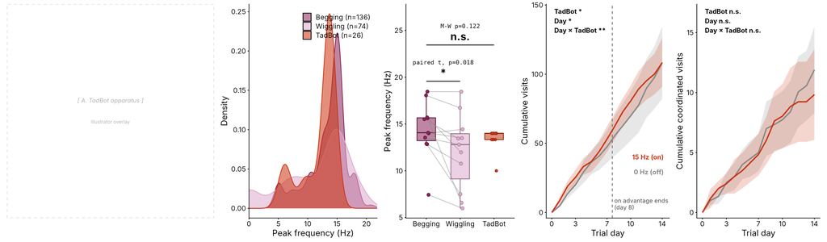

Figure 3, panels B to E. Panel A is drawn by hand and is not produced here.

## 5 Figure 4: phosphoTRAP, mate-pair synchrony and single-nucleus RNA-seq

| Panel | What it shows | Test |
| --- | --- | --- |
| A | The experiment schematic: the drawing `Figures/artwork/Figure4_artwork.png`, placed by the script | none |
| B | Are mates’ preoptic-area baseline transcriptomes more alike than those of non-mates? Pearson r of log2(TMM + 1) Input expression for each mate pair, mean across pairs. Sits under A | Label permutation: male identity shuffled across the pairs 10,000 times |
| C | Preoptic area, sexes combined: log2 fold change (IP vs Input) after begging against after a neutral stimulus, one point per gene | A gene is differentially translated if padj < 0.05 and the absolute log2 fold change is above 0.6 |
| D | Preoptic area, each sex: candidate opioid, endocannabinoid and neuropeptide genes | edgeR padj (bubble size), log2 fold change (color) |
| E to G | Single-nucleus RNA-seq: the t-SNE of nuclei by cluster, Penk expression on the t-SNE, and the cumulative distribution of the clusters’ enrichment ranks for begging marker genes with cluster 106 (PVpo-… | none here |

`Figure4_11162026.R` is one script for all of Figure 4: the mate-pair permutation test, then the synchrony panel, the scatter plot, the bubble plot, the snRNA-seq images and the assembly. The snRNA-seq panels are not re-drawn in R. They were made in Python (`scanpy`, `SAMap`) from `.h5ad` expression files that are not part of this folder; the script places the finished images from `Data/Analysis_ForBillie_Figure4/`. If a placed image is missing, the script prints a note, draws a labelled placeholder in its place and still makes the rest of the figure.

**Code: Functions/Figure4_11162026.R**

```r
# Figure 4

# Order of the script:
#   Setup    paths, print sizes, helper functions
#   Part 1   mate-pair synchrony: the label-permutation test
#   Part 2   panel B (mate-pair synchrony), drawn from the test results
#   then     panel C (scatter), panel D (bubble plot), the snRNA-seq row
#            (E, F, G), and the assembly
#   Panel letters as in Figures/Figure4_11122026.ai / .png

# Inputs: Data/phosphotrap/ (edgeR tables, TMM expression matrix, sample
#         sheets)
# Output: Figures/Figure4_11112026.{pdf,png}
#         Supplementary/derived_tables/PairSynchrony_results.csv, Supplementary/derived_tables/PairSynchrony_perPair.csv
#         Figures/Figure4_panels/: the synchrony panels on their own (all
#         three regions, and the POA panel)

suppressPackageStartupMessages({
  library(readxl); library(dplyr); library(tidyr)
  library(ggplot2); library(patchwork); library(cowplot)
  library(scales); library(tibble)
})

repo_dir <- here::here()
fig_dir        <- file.path(repo_dir, "Figures")
ptrap_data     <- file.path(repo_dir, "Data", "phosphotrap")
panel_dir      <- file.path(fig_dir, "Figure4_panels")     # stand-alone copies of the synchrony panels
out_dir        <- file.path(repo_dir, "Supplementary", "derived_tables")           # the permutation-test results
dir.create(panel_dir, showWarnings = FALSE, recursive = TRUE)
dir.create(out_dir, showWarnings = FALSE, recursive = TRUE)

# Panel A is a drawing: Figures/artwork/Figure4_artwork.png, exported from
# Figure4_artwork.ai and cropped to the drawing.
IMG_PANEL_A <- file.path(repo_dir, "Figures", "artwork", "Figure4_artwork.png")

# ---------------------------------------------------------------------------
# Print size and fonts. The figure is composed at the width it is printed
# (double column), so every font size below is its printed size. Every ggplot
# panel goes through print_ready(), which sets theme text and in-plot text
# layers to these sizes.
# ---------------------------------------------------------------------------
FIG_W_IN <- 7.5

GEOM_SCALE_DEFAULTS <- 0.6   # theme-default line widths / point sizes at print size

# Nothing in the plots is smaller than 6 pt at the printed size.
# (Panel A's drawing has its own, smaller text and is not matched.)
FONT_PT  <- 7      # axis titles
SMALL_PT <- 6      # tick labels, in-plot labels, legends, subtitles

font_theme <- theme(
  line              = element_line(linewidth = 0.3),
  # legend keys/spacing in pt, not "lines" (which scale with each source
  # plot's own base font size and left big gaps between legend rows)
  legend.key.size   = grid::unit(FONT_PT + 1, "pt"),
  legend.key.spacing = grid::unit(2, "pt"),
  legend.spacing    = grid::unit(2, "pt"),
  legend.margin     = margin(1, 1, 1, 1),
  axis.text         = element_text(size = SMALL_PT),
  axis.text.x       = element_text(size = SMALL_PT),
  axis.text.y       = element_text(size = SMALL_PT),
  axis.title        = element_text(size = FONT_PT),
  axis.title.x      = element_text(size = FONT_PT),
  axis.title.y      = element_text(size = FONT_PT),
  plot.title        = element_text(size = FONT_PT + 1),
  plot.subtitle     = element_text(size = SMALL_PT),
  strip.text        = element_text(size = SMALL_PT),
  strip.text.y.left = element_text(size = SMALL_PT),
  legend.text       = element_text(size = SMALL_PT),
  legend.title      = element_text(size = SMALL_PT)
)

# ggplot2 >= 4.0 takes default line widths / point sizes from the theme
# (geoms whose size wasn't set explicitly, e.g. Panel C's dashed threshold
# lines, B's bar outlines). Scale those defaults down too.
if ("element_geom" %in% getNamespaceExports("ggplot2")) {
  font_theme <- font_theme + theme(geom = ggplot2::element_geom(
    linewidth   = 0.5 * GEOM_SCALE_DEFAULTS,
    borderwidth = 0.5 * GEOM_SCALE_DEFAULTS,
    pointsize   = 1.5 * GEOM_SCALE_DEFAULTS))
}

harmonise_text <- function(p) {
  # In-plot text layers (geom_text, annotate("text")) take their size in mm,
  # not pt. Layers are ggproto objects, so this edits them in place.
  for (lyr in p$layers) {
    if (inherits(lyr$geom, c("GeomText", "GeomLabel")) &&
        !is.null(lyr$aes_params$size)) {
      lyr$aes_params$size <- (SMALL_PT) / ggplot2::.pt
    }
  }
  p + font_theme
}

GEOM_SCALE <- 0.45
scale_geoms <- function(p, f = GEOM_SCALE) {
  plot_mapped <- names(p$mapping)
  for (lyr in p$layers) {
    if (inherits(lyr$geom, c("GeomText", "GeomLabel"))) next
    mapped <- c(names(lyr$mapping), if (isTRUE(lyr$inherit.aes)) plot_mapped)
    for (a in c("size", "linewidth", "stroke")) {
      if (a %in% mapped) next
      cur <- lyr$aes_params[[a]]
      if (is.null(cur)) cur <- lyr$geom$default_aes[[a]]
      if (is.numeric(cur)) lyr$aes_params[[a]] <- cur * f
    }
  }
  p
}

# Everything that goes into the figure gets both, and loses its plot title
# (panels are identified by letter). Subtitles, e.g. D's stats line, are kept.
print_ready <- function(p) scale_geoms(harmonise_text(p)) + labs(title = NULL)

# Drawn in place of an image file that is missing
placeholder_panel <- function(note) {
  ggplot() + theme_void() +
    annotate("rect", xmin = 0, xmax = 1, ymin = 0, ymax = 1,
             fill = NA, color = "grey70", linetype = "dashed", linewidth = 0.3) +
    annotate("text", x = 0.5, y = 0.5, color = "grey55", fontface = "italic",
             size = SMALL_PT / ggplot2::.pt, label = note) +
    coord_cartesian(xlim = c(0, 1), ylim = c(0, 1), expand = FALSE)
}

# Panel A - drawing
has_A <- file.exists(IMG_PANEL_A)
if (!has_A) message("NOTE, Figure 4: panel A image not found, drawing a placeholder: ", IMG_PANEL_A)
img_A <- if (has_A) png::readPNG(IMG_PANEL_A) else NULL
ar_A  <- if (has_A) ncol(img_A) / nrow(img_A) else 0.70   # 0.70 = shape of the drawing, used for the placeholder

#panel b Mate-pair synchrony: the label-permutation test
#
# Are mates' baseline (Input) transcriptomes more alike
#   1. Pearson r of log2(TMM+1) Input expression for every pair of same-region
#      samples.
#   2. Mean r across the N true mate pairs (one female and one male of the
#      same breeding pair, both with usable Input data).
#   3. Null: male identity shuffled across the same N pairs, 10,000 times.
#   4. p = share of shuffles with mean mate r at or above the observed one.
# A Mann-Whitney test of mate r against all non-mate r would treat the
# non-mate values as independent; they are not (each sample is in about N-1
# of them). Shuffling labels keeps the real dependence structure.
#
# Run for the POA (the panel), pallium and subpallium.
# Writes Supplementary/derived_tables/PairSynchrony_results.csv and PairSynchrony_perPair.csv, and
# a stand-alone view of all three regions in Figures/Figure4_panels/.
# ============================================================================
set.seed(123)
```

```r
# ---------- Paths ----------
fp_expr <- file.path(ptrap_data, "output.gene.TMM.EXPR.matrix")
fp_list <- file.path(ptrap_data, "pTRAP List.xlsx")
fp_meta <- file.path(ptrap_data, "phosphoTRAP data.xlsx")
stopifnot(file.exists(fp_expr), file.exists(fp_list), file.exists(fp_meta))

# Colors of the "real mate pairs" bar and of its dots (dark outline)
SYNC_GREEN      <- "#5aa04e"
SYNC_GREEN_DARK <- "#2c5a25"

# ---------- Theme ----------
theme_nature <- theme_classic(base_size = 9, base_family = "sans") +
  theme(panel.grid = element_blank(),
        axis.line = element_line(linewidth = 0.4),
        axis.ticks = element_line(linewidth = 0.4),
        plot.title = element_text(size = 10, face = "bold"),
        plot.subtitle = element_text(size = 8))
theme_set(theme_nature)

# ---------- Build sample annotation: sid -> pair / region / sex ----------
ptrap_list <- read_excel(fp_list, sheet = "collectionsheet") |>
  rename(sid = Sample_id, region = Brain_region, sex = Sex,
         beg = BegNoBeg, frog_id = FrogID, testid = TestID) |>
  mutate(sid = as.integer(sid))

ptrap_meta <- read_excel(fp_meta, sheet = "Sheet1") |>
  rename(testid = `...1`, pair = pair) |>
  select(testid, pair) |> distinct()

samp <- ptrap_list |>
  left_join(ptrap_meta, by = "testid") |>
  filter(!is.na(pair))

cat("Loaded", nrow(samp), "annotated samples across",
    length(unique(samp$pair)), "breeding pairs\n")

# ---------- Load TMM matrix ----------
expr <- read.delim(fp_expr, header = TRUE, row.names = 1, check.names = FALSE,
                   stringsAsFactors = FALSE)
expr <- as.matrix(expr)

# Parse column names like "13i_R1_001" -> sid=13, fraction='i'
parse_colname <- function(cn) {
  m <- regmatches(cn, regexec("^(\\d+)([ip])_", cn))[[1]]
  if (length(m) < 3) return(c(NA, NA))
  c(sid = as.integer(m[2]), fraction = m[3])
}
parsed <- t(sapply(colnames(expr), parse_colname))
parsed_df <- data.frame(col = colnames(expr),
                        sid = as.integer(parsed[, 1]),
                        fraction = parsed[, 2],
                        stringsAsFactors = FALSE) |>
  filter(!is.na(sid))

# ---------- Per-region permutation test ----------
run_region <- function(region_name, n_perm = 10000) {
  region_sids <- samp |> filter(region == region_name) |> pull(sid)
  inputs <- parsed_df |>
    filter(sid %in% region_sids, fraction == "i")
  if (nrow(inputs) == 0)
    stop("No Input columns found for region: ", region_name)

  M <- log2(expr[, inputs$col, drop = FALSE] + 1)
  variable <- apply(M, 1, var, na.rm = TRUE) > 0
  M <- M[variable, , drop = FALSE]
  colnames(M) <- inputs$sid

  R <- cor(M, method = "pearson")

  region_samp <- samp |> filter(region == region_name, sid %in% inputs$sid)
  pair_table <- region_samp |>
    group_by(pair) |>
    filter(n_distinct(sex) == 2) |>
    summarise(F_sid = sid[sex == "Female"][1],
              M_sid = sid[sex == "Male"][1],
              .groups = "drop") |>
    filter(!is.na(F_sid), !is.na(M_sid))
  N <- nrow(pair_table)

  mate_rs <- mapply(function(f, m) R[as.character(f), as.character(m)],
                    pair_table$F_sid, pair_table$M_sid)
  obs_mean <- mean(mate_rs)

  females <- pair_table$F_sid
  males   <- pair_table$M_sid
  null_means <- numeric(n_perm)
  for (k in seq_len(n_perm)) {
    perm_males <- sample(males)
    null_means[k] <- mean(mapply(function(f, m) R[as.character(f), as.character(m)],
                                  females, perm_males))
  }

  list(region = region_name,
       N_pairs = N,
       observed = obs_mean,
       null_mean = mean(null_means),
       null_sd = sd(null_means),
       null_means = null_means,
       p = mean(null_means >= obs_mean),
       pair_table = pair_table |> mutate(r = mate_rs))
}

cat("\nRunning label-permutation tests (10,000 perms each) ...\n")
res <- lapply(c("POA", "Pallium", "Subpallium"), run_region)
names(res) <- c("POA", "Pallium", "Subpallium")

summary_tbl <- do.call(rbind, lapply(res, function(r) {
  data.frame(region = r$region,
             N_mate_pairs = r$N_pairs,
             observed_r = round(r$observed, 4),
             null_mean = round(r$null_mean, 4),
             null_sd = round(r$null_sd, 4),
             z = round((r$observed - r$null_mean) / r$null_sd, 2),
             p_label_permutation = round(r$p, 4))
}))
cat("\n"); print(summary_tbl, row.names = FALSE)

#region     N_mate_pairs   observed_r null_mean null_sd zscore p_label_permutation
#POA              9        0.5219    0.5030  0.0099 1.91              0.0245
#Pallium            8       0.7312    0.7281  0.0035 0.89              0.2033
#Subpallium            9     0.6767    0.6720  0.0048 0.99              0.1800

make_bar_panel <- function(r, n_breaks = 5) {
  bar_df <- data.frame(
    group = factor(c("Real\nmate pairs", "Null\n(shuffled)"),
                   levels = c("Real\nmate pairs", "Null\n(shuffled)")),
    mean  = c(r$observed, r$null_mean),
    err   = c(NA, 1.96 * r$null_sd)
  )
  dot_df <- data.frame(group = "Real\nmate pairs", r_val = r$pair_table$r)

  y_lo <- min(c(r$pair_table$r, r$null_mean - 2.5 * r$null_sd)) - 0.005
  y_hi <- max(c(r$pair_table$r, r$null_mean + 2.5 * r$null_sd)) + 0.005

  ggplot(bar_df, aes(group, mean, fill = group)) +
    geom_col(color = "black", linewidth = 0.5, width = 0.55, alpha = 0.7) +
    geom_errorbar(aes(ymin = mean - err, ymax = mean + err),
                  width = 0.18, linewidth = 0.6, na.rm = TRUE) +
    geom_jitter(data = dot_df, aes(group, r_val),
                shape = 21, fill = SYNC_GREEN, color = SYNC_GREEN_DARK, size = 1.8, stroke = 0.5,
                width = 0.10, height = 0, inherit.aes = FALSE) +
    scale_fill_manual(values = c("Real\nmate pairs" = SYNC_GREEN,
                                 "Null\n(shuffled)" = "#888888"),
                      guide = "none") +
    scale_y_continuous(breaks = scales::pretty_breaks(n = n_breaks)) +
    coord_cartesian(ylim = c(y_lo, y_hi)) +
    labs(x = NULL, y = "Mean mate-pair r",
         title = sprintf("%s  (n = %d pairs)", r$region, r$N_pairs),
         subtitle = sprintf("obs = %.3f, null = %.3f, p = %.3f",
                            r$observed, r$null_mean, r$p))
}
```

```r
fig <- (make_bar_panel(res$POA, n_breaks = 6) |
        make_bar_panel(res$Pallium) |
        make_bar_panel(res$Subpallium)) +
  plot_annotation(
    title = "Input transcriptional synchrony between mate pairs",
    subtitle = "Bars: observed (red) vs label-permutation null (gray, ± 1.96·SD); dots = individual mate pairs",
    theme = theme(plot.title = element_text(size = 11, face = "bold"),
                  plot.subtitle = element_text(size = 9, color = "grey40")))


ggsave(file.path(panel_dir, "Pair_synchrony_INPUT_R.png"), fig,
       width = 6, height = 4, dpi = 300, bg = "white")
ggsave(file.path(panel_dir, "Pair_synchrony_INPUT_R.pdf"), fig,
       width = 6, height = 4)

write.csv(summary_tbl,
          file.path(out_dir, "PairSynchrony_results.csv"),
          row.names = FALSE)

per_pair_tbl <- do.call(rbind, lapply(res, function(r) {
  data.frame(region = r$region, r$pair_table)
}))
write.csv(per_pair_tbl,
          file.path(out_dir, "PairSynchrony_perPair.csv"),
          row.names = FALSE)

sync_results <- read.csv(file.path(out_dir, "PairSynchrony_results.csv"))
sync_perPair <- read.csv(file.path(out_dir, "PairSynchrony_perPair.csv"))

poa  <- sync_results |> filter(region == "POA")
dots <- sync_perPair |> filter(region == "POA")

bar <- data.frame(
  group = factor(c("Real\nmate pairs", "Null\n(shuffled)"),
                 levels = c("Real\nmate pairs", "Null\n(shuffled)")),
  mean  = c(poa$observed_r, poa$null_mean),
  err   = c(NA, 1.96 * poa$null_sd))

p_txt <- if (poa$p_label_permutation < 0.001) "p < 0.001" else
         sprintf("p = %.3f", poa$p_label_permutation)
y_lo <- min(c(dots$r, poa$null_mean - 2.5 * poa$null_sd)) - 0.005
y_hi <- max(c(dots$r, poa$null_mean + 2.5 * poa$null_sd)) + 0.005

poa_panel <- ggplot(bar, aes(group, mean, fill = group)) +
  geom_col(color = "black", linewidth = 0.5, width = 0.55, alpha = 0.7) +
  geom_errorbar(aes(ymin = mean - err, ymax = mean + err),
                width = 0.18, linewidth = 0.6, na.rm = TRUE) +
  # one dot per mate pair: the bar's green, outlined in a darker shade of it
  # (the dot style of the Figure 2 and Figure 3 box panels)
  geom_jitter(data = dots, aes(x = "Real\nmate pairs", y = r), inherit.aes = FALSE,
              shape = 21, fill = SYNC_GREEN, color = SYNC_GREEN_DARK,
              size = 2.4, stroke = 0.9, width = 0.10, height = 0) +
  scale_fill_manual(values = c("Real\nmate pairs" = SYNC_GREEN,
                               "Null\n(shuffled)" = "#888888"), guide = "none") +
  coord_cartesian(ylim = c(y_lo, y_hi)) +
  labs(x = NULL, y = "Mean mate-pair r", title = "POA synchrony",
       subtitle = sprintf("obs %.3f vs null %.3f\n%s  (n = %d pairs)",
                          poa$observed_r, poa$null_mean, p_txt, poa$N_mate_pairs)) +
  theme_classic(base_size = 9) +   # ~matches Figure3 top-row fonts
  theme(panel.grid = element_blank(),
        axis.line  = element_line(color = "black", linewidth = 0.4),
        axis.ticks = element_line(color = "black", linewidth = 0.4),
        legend.position = "none",
        plot.title    = element_text(face = "bold", size = 9.5, hjust = 0.5),
        plot.subtitle = element_text(size = 7, hjust = 0.5))

poa_panel

ggsave(file.path(panel_dir, "POA_synchrony_panel.pdf"), poa_panel, width = 3.3, height = 4.4)
ggsave(file.path(panel_dir, "POA_synchrony_panel.png"), poa_panel,
       width = 3.3, height = 4.4, dpi = 300, bg = "white")
cat(sprintf("Saved POA_synchrony_panel.{pdf,png}  (POA obs r = %.3f, p = %.4f, n = %d)\n",
            poa$observed_r, poa$p_label_permutation, poa$N_mate_pairs))
panelB <- print_ready(poa_panel)

d_sub <- panelB$labels$subtitle
if (!is.null(d_sub)) {
  m <- regmatches(d_sub, gregexpr("[0-9]*\\.?[0-9]+", d_sub))[[1]]
  # m = obs, null, p, n (numbers in the order the subtitle prints them)
  if (length(m) >= 4) d_sub <- sprintf("%s vs %s\np = %s, n = %s", m[1], m[2], m[3], m[4])   # two lines: B is narrow
}

#Panel C -- POA, sexes combined: begging against no-begging log2 fold change,
# from the two edgeR tables (IP vs Input)
# ============================================================================
read_edgeR <- function(filename) read.delim(file.path(ptrap_data, filename), header = TRUE)

nobeg_poa <- read_edgeR("IP_Input_nobeg_bothsex_poa_edgeR_Anno.txt")
beg_poa   <- read_edgeR("IP_Input_beg_bothsex_poa_edgeR_Anno.txt")

poa_compare <- nobeg_poa[, c("Gene", "Gene.symbol", "logFC", "padj")]
colnames(poa_compare)[colnames(poa_compare) == "logFC"] <- "logFC_nobeg"
colnames(poa_compare)[colnames(poa_compare) == "padj"]  <- "padj_nobeg"

beg_tmp <- beg_poa[, c("Gene", "logFC", "padj")]  # Gene.symbol dropped here --
                                                    # keeping it on both sides made
                                                    # merge() rename to Gene.symbol.x/.y,
                                                    # so poa_compare$Gene.symbol later
                                                    # resolved to NULL (0-length) and
                                                    # broke the $highlight assignment.
colnames(beg_tmp)[colnames(beg_tmp) == "logFC"] <- "logFC_beg"
colnames(beg_tmp)[colnames(beg_tmp) == "padj"]  <- "padj_beg"

poa_compare <- merge(poa_compare, beg_tmp, by = "Gene")

poa_compare <- poa_compare %>%
  mutate(
    sig_nobeg = padj_nobeg < 0.05 & abs(logFC_nobeg) > 0.6,
    sig_beg   = padj_beg   < 0.05 & abs(logFC_beg)   > 0.6,
    DE_class = case_when(
      sig_nobeg & sig_beg  ~ "DT in Both",
      sig_nobeg & !sig_beg ~ "DT in No-Begging",
      !sig_nobeg & sig_beg ~ "DT in Begging only",
      TRUE                 ~ "Not DT"
    ),
    DE_class = factor(DE_class, levels = c("DT in Begging only", "DT in No-Begging",
                                            "Not DT", "DT in Both"))
  )

cat("Panel C | POA genes by class (padj < 0.05 and |log2FC| > 0.6):\n")
print(table(poa_compare$DE_class))
#DT in Begging only   DT in No-Begging             Not DT         DT in Both
#289               1093               6150                141
```

```r
# Genes labelled in the panel, by gene symbol.
genes_to_label <- c("NEXMIF", "FAAH1", "CRF", "OPRM", "PDYN", "CNR1", "VIP", "PENKA",
                     "PENK", "GAL", "OXT", "OT", "AVP", "CRFR1", "COMTA", "BOMB", "PNOC",
                     "GPR83")
poa_compare$highlight <- poa_compare$Gene.symbol %in% genes_to_label
# CRFR1 and GPR83 each match two duplicate-annotated transcripts in this assembly (see the note above panel D's gene table on this same issue). For each, only the stronger/more significant transcript gets labeled.
#   CRFR1:  rb_8081_pilon (|logFC| ~3-4, padj_nobeg = 0.038) kept over
#           rb_598_pilon  (|logFC| ~1-2, padj_nobeg = 0.224)
#   GPR83:  rb_14905_pilon (padj_beg = 1.1e-4, the begging-only hit) kept over
#           rb_20664_pilon (not significant in either condition)
poa_compare$highlight[poa_compare$Gene.symbol == "CRFR1" & poa_compare$Gene != "rb_8081_pilon"] <- FALSE
poa_compare$highlight[poa_compare$Gene.symbol == "GPR83" & poa_compare$Gene != "rb_14905_pilon"] <- FALSE

# Both axes show -logFC, so that positive = enriched in the IP fraction.

panelC_x    <- -poa_compare$logFC_nobeg
panelC_xrng <- range(panelC_x, na.rm = TRUE)
panelC_xpad <- diff(panelC_xrng)

poa_compare$label_color_cat <- as.character(poa_compare$DE_class)
poa_compare$label_color_cat[poa_compare$DE_class == "Not DT"] <- "Not DT (label)"

LABEL_SPREAD  <- c(0.04, 0.96)     # bottom and top of the label column, as fractions of the y range
panelC_yrng   <- range(-poa_compare$logFC_beg, na.rm = TRUE)
panelC_labels <- subset(poa_compare, highlight)
panelC_labels <- panelC_labels[order(panelC_labels$logFC_beg), ]          # highest point first
panelC_labels$x_lab <- panelC_xrng[2] + 0.38 * panelC_xpad
panelC_labels$y_lab <- seq(panelC_yrng[1] + LABEL_SPREAD[2] * diff(panelC_yrng),
                           panelC_yrng[1] + LABEL_SPREAD[1] * diff(panelC_yrng),
                           length.out = nrow(panelC_labels))

lines_cross <- function(i, j, d) {
  px <- -d$logFC_nobeg; py <- -d$logFC_beg
  side <- function(ax, ay, bx, by, cx, cy) sign((bx - ax) * (cy - ay) - (by - ay) * (cx - ax))
  side(px[i], py[i], d$x_lab[i], d$y_lab[i], px[j], py[j]) != side(px[i], py[i], d$x_lab[i], d$y_lab[i], d$x_lab[j], d$y_lab[j]) &&
    side(px[j], py[j], d$x_lab[j], d$y_lab[j], px[i], py[i]) != side(px[j], py[j], d$x_lab[j], d$y_lab[j], d$x_lab[i], d$y_lab[i])
}
for (pass in seq_len(nrow(panelC_labels))) {
  swapped <- FALSE
  for (i in seq_len(nrow(panelC_labels) - 1)) if (lines_cross(i, i + 1, panelC_labels)) {
    y_two <- panelC_labels$y_lab[c(i, i + 1)]
    panelC_labels[c(i, i + 1), ] <- panelC_labels[c(i + 1, i), ]
    panelC_labels$y_lab[c(i, i + 1)] <- y_two
    swapped <- TRUE
  }
  if (!swapped) break
}

panelC_core <- ggplot(poa_compare, aes(x = -logFC_nobeg, y = -logFC_beg, color = DE_class)) +
  geom_point(size = 1.0, alpha = 0.7) +   # x GEOM_SCALE at print size (~0.45)
  geom_segment(data = panelC_labels,
               aes(xend = x_lab - 0.01 * panelC_xpad, yend = y_lab, color = label_color_cat),
               linewidth = 0.3 / GEOM_SCALE, show.legend = FALSE) +   # print_ready() scales it back to 0.3
  geom_text(data = panelC_labels,
            aes(x = x_lab, y = y_lab, label = Gene.symbol, color = label_color_cat),
            size = 3, fontface = "italic", hjust = 0, vjust = 0.5, show.legend = FALSE) +
  geom_hline(yintercept = c(-0.6, 0.6), linetype = "dashed", color = "grey40") +
  geom_vline(xintercept = c(-0.6, 0.6), linetype = "dashed", color = "grey40") +
  geom_abline(slope = 1, intercept = 0, linetype = "dotted", color = "grey40") +
  scale_color_manual(values = c(
    "DT in Begging only" = "#D32F2F",
    "DT in No-Begging"   = "#1565C0",
    "Not DT"             = "grey80",
    "DT in Both"         = "grey30",
    "Not DT (label)"     = "black"),
    breaks = c("DT in Begging only", "DT in No-Begging", "Not DT", "DT in Both"),
    name = NULL) +
  coord_cartesian(xlim = c(panelC_xrng[1] - 0.05 * panelC_xpad,
                           panelC_xrng[2] + 0.70 * panelC_xpad),
                  clip = "off") +
  labs(x = expression(Log[2] * " Fold Change (No begging)"),
       y = expression(Log[2] * " Fold Change (Begging)"),
       title = "POA (combined sexes)") +
  theme_classic(base_size = 11)

panelC_core

panelC_core <- print_ready(panelC_core) +
  guides(color = guide_legend(nrow = 1, override.aes = list(size = 1.8, alpha = 1)))

panelC   <- panelC_core + theme(legend.position = "none")
legend_C <- cowplot::get_legend(
  panelC_core + theme(legend.position = "bottom", legend.title = element_blank())
)

# panel D
# Input: Data/phosphotrap/IP_Input_{nobeg,beg}_{male,female}_poa_edgeR*.txt,
# edgeR results (IP vs Input) for the POA, one file per sex and stimulus. The
# no-begging female file has a different column layout from the other three;
# both are read. logFC is negated so that positive = enriched in the IP
# fraction, as in panel C. Several gene symbols match more than one transcript
# in the annotation; the transcript used for each symbol is fixed in the
# table below.
# ---- canonical symbol -> transcript ID, and system category ----------------
canon <- tribble(
  ~gene.symbol, ~Gene,                          ~category,
  "OPRM",       "rb_16192_pilon",               "Opioid system",
  "PDYN",       "rb_18826_pilon",               "Opioid system",
  "PENKA",      "rb_7418_pilon",                "Opioid system",
  "PNOC",       "rb_20033_pilon",               "Opioid system",
  "FAAH1",      "rb_23602_pilon",               "Endocannabinoid",
  "AVP",        "rb_31702_pilon_billieadded",   "Neuropeptides",
  "OXT",        "rb_31695_pilon_billieadded",   "Neuropeptides",
  "CRF",        "rb_13255_pilon",               "Neuropeptides",
  "CRFR1",      "rb_8081_pilon",                "Neuropeptides",   # the same CRFR1 transcript that panel C labels
  "UCN3",       "rb_31696_pilon_billieadded",   "Neuropeptides",
  "TRH",        "rb_9464_pilon",                "Neuropeptides",
  "TRHDE",      "rb_15346_pilon",               "Neuropeptides",
  "GNRH",       "rb_31703_pilon_billieadded",   "Neuropeptides",
  "GAL",        "rb_31694_pilon_billieadded",   "Neuropeptides",
  "NPY",        "rb_19415_pilon",               "Neuropeptides",
  "VIP",        "rb_3280_pilon",                "Neuropeptides",
  "PRRP",       "rb_8360_pilon",                "Neuropeptides",
  "CART",       "rb_13238_pilon",               "Neuropeptides",
)
canon$category <- factor(canon$category,
                          levels = c("Opioid system","Endocannabinoid","Neuropeptides"))
```

```r
# ---- read one per-sex POA edgeR file (either column layout) --------------
# Both layouts share Gene/logFC/padj; we join on the pinned transcript ID
# (canon$Gene) rather than any symbol column, so the symbol-naming
# inconsistency between layouts never matters here.
read_poa_sexed <- function(filename) {
  df <- read.delim(file.path(ptrap_data, filename), header = TRUE)
  stopifnot(all(c("Gene", "logFC", "padj") %in% names(df)))
  df[, c("Gene", "logFC", "padj")]
}

conditions <- tribble(
  ~treatment, ~sex,     ~file,
  "nobeg",    "male",   "IP_Input_nobeg_male_poa_edgeR.GeneName_Anno.txt",
  "beg",      "male",   "IP_Input_beg_male_poa_edgeR.GeneName_Anno.txt",
  "beg",      "female", "IP_Input_beg_female_poa_edgeR.GeneName_Anno.txt",
  "nobeg",    "female", "IP_Input_nobeg_female_poa_edgeR_Anno.txt",
)

poa_only_df <- dplyr::bind_rows(lapply(seq_len(nrow(conditions)), function(i) {
  cond <- conditions[i, ]
  raw  <- read_poa_sexed(cond$file)
  merge(canon, raw, by = "Gene") |>
    distinct(gene.symbol, .keep_all = TRUE) |>   # collapse duplicate synonym rows per transcript
    mutate(treatment = cond$treatment, sex = cond$sex, brainregion = "poa")
}))

# Negate logFC to keep the positive = IP-enriched convention
poa_only_df <- poa_only_df |>
  mutate(
    logFC        = -logFC,
    neglog10padj = -log10(pmax(padj, 1e-10)),
    # Plain "M"/"F" rather than Mars/Venus glyphs (<U+2642>/<U+2640>): those
    # Unicode symbols don't render in every graphics device/font -- they came
    # out as invisible empty glyphs here, which silently made the male and
    # female condition columns look identical ("POA NoBEG" x2, "POA BEG" x2)
    # instead of 4 distinct columns. Found while widening this panel.
    sex_lab      = factor(sex, levels = c("male","female"), labels = c("M","F")),
    tx_lab       = factor(treatment, levels = c("nobeg","beg"), labels = c("NoBEG","BEG")),
    condition    = paste("POA", sex_lab, tx_lab),
    category     = factor(category,
                           levels = c("Opioid system","Endocannabinoid","Neuropeptides"),
                           labels = c("Endogenous opioids","Endocannabinoid","Neuropeptides")),
    gene.symbol  = factor(gene.symbol, levels = canon$gene.symbol)
  )

cond_levels <- c()
for (sex in c("M","F"))
  for (tx in c("NoBEG","BEG"))
    cond_levels <- c(cond_levels, paste("POA", sex, tx))
poa_only_df$condition <- factor(poa_only_df$condition, levels = cond_levels)

bubble_poa <- ggplot(poa_only_df, aes(x = condition, y = gene.symbol)) +
  geom_point(aes(size = neglog10padj, fill = logFC),
             shape = 21, color = "black", stroke = 0.3, alpha = 0.95) +
  scale_fill_gradient2(low = "#542788", mid = "#f7f7f7", high = "#b35806",
                       midpoint = 0, limits = c(-8, 8), oob = scales::squish,
                       name = "logFC\n(orange = IP-enriched\npurple = IP-depleted)") +
  scale_size_continuous(range = c(1, 6),
                        breaks = -log10(c(0.5, 0.05, 0.01, 0.001)),
                        labels = c("0.5","0.05","0.01","0.001"),
                        name = "padj") +
  # No facet_grid by category: faceting put FAAH1 (the lone Endocannabinoid
  # entry) in its own single-row strip between Opioid system and
  # Neuropeptides, which read as a visual "split". gene.symbol's factor
  # levels (set above from canon$gene.symbol, in category order) already
  # keep the three groups in the right order on one continuous axis.
  scale_y_discrete(limits = rev) +
  theme_classic(base_size = 9) +
  theme(axis.text.x       = element_text(angle = 0, hjust = 0.5, size = 8),
        axis.text.y       = element_text(size = 8),
        panel.grid.major.y = element_line(color = "grey92", linewidth = 0.3),
        plot.title         = element_text(face = "bold", size = 11),
        plot.subtitle      = element_text(size = 9, color = "grey30")) +
  labs(x = NULL, y = NULL,
       title    = "POA — Endogenous opioids, Endocannabinoid, Neuropeptides",
       subtitle = "Color = logFC (orange = IP-enriched, purple = IP-depleted); size = −log10(padj)\nRebuilt directly from per-sex edgeR output (see header note)")

panelD_core <- bubble_poa +
  # "POA " prefix dropped from the column labels -- the panel title already
  # says POA, and at print size the full labels collide.
  scale_x_discrete(labels = function(x) sub("^POA ", "", x)) +
  # No facet_grid here either (see the note in the plot above) -- one
  # continuous axis, so the single-gene Endocannabinoid group (FAAH1) no
  # longer reads as split off from Opioid system/Neuropeptides above/below
  # it. Order is preserved via gene.symbol's factor levels.
  # Bubble sizes: same breaks/labels as the standalone script, range scaled
  # down to print size like the other geometry.
  scale_size_continuous(range = c(1, 6) * GEOM_SCALE,
                        breaks = -log10(c(0.5, 0.05, 0.01, 0.001)),
                        labels = c("0.5", "0.05", "0.01", "0.001"),
                        name = "padj") +
  labs(subtitle = NULL) +
    guides(fill = guide_colorbar(title = "logFC", direction = "horizontal", title.position = "left",
                                title.vjust = 0.9,
                                barwidth = grid::unit(0.55, "in"), barheight = grid::unit(0.06, "in"),
                                order = 1),
         size = guide_legend(direction = "horizontal", title.position = "left", order = 2)) +
  theme(axis.text.x = element_text(angle = 45, hjust = 1, vjust = 1),
        legend.position = "bottom", legend.box = "horizontal",
        legend.box.spacing = grid::unit(0, "pt"),
        legend.spacing.y = grid::unit(1, "pt"),
        plot.title.position = "plot")
panelD_core <- print_ready(panelD_core)
panelD   <- panelD_core + theme(legend.position = "none")
legend_D <- cowplot::get_legend(panelD_core)
panelD

#snRNAseq
#These panels are NOT drawn here. They were made in Python by Prateek Kalakuntla(the Jupyter
# notebooks in Data/Analysis_ForBillie_Figure4/, which need scanpy, SAMap
# and the .h5ad expression files). This script only places the exported
# images, left to right:
#   t-SNE of the nuclei colored by cluster | Penk expression on the t-SNE |
#   cumulative distribution of the clusters' enrichment ranks for begging
#   marker genes, cluster 106 (PVpo-VMPO-MPN Hmx2 Gaba) marked
#   (snRNAseq_enrichment_rank_ECDF.png; no notebook or data for this one is
#   in the folder)
# Each image keeps its own shape; the columns are sized so all three have the
# same height. If an image is missing, a labelled placeholder fills the row.
# ============================================================================
snrna_dir    <- file.path(repo_dir, "Data", "Analysis_ForBillie_Figure4")
SNRNA_IMAGES <- file.path(snrna_dir, c("RI_sss_subclass_v5_10012026.png",
                                       "Imitator_Frog_Penk_10012026.png",
                                       "snRNAseq_enrichment_rank_ECDF.png"))
panel_snRNAseq <- if (all(file.exists(SNRNA_IMAGES))) {
  imgs   <- lapply(SNRNA_IMAGES, png::readPNG)
  aspect <- vapply(imgs, function(m) ncol(m) / nrow(m), numeric(1))     # width / height
  wrap_plots(lapply(imgs, function(m)
    ggplot() + theme_void() + annotation_custom(grid::rasterGrob(m, interpolate = TRUE))),
    nrow = 1, widths = aspect)
} else {
  message("NOTE, Figure 4: snRNA-seq image(s) not found, drawing a placeholder: ",
          paste(basename(SNRNA_IMAGES[!file.exists(SNRNA_IMAGES)]), collapse = ", "))
  placeholder_panel("[ single-nucleus RNA-seq panels: images not found ]")
}
```

```r
panel_snRNAseq

# Assemble
#
# Panel letters as in Figures/Figure4_11122026.ai / .png:
#   A  schematic (drawing)           B  mate-pair synchrony, under A
#   C  scatter, sexes combined       D  bubble plot, sexes separated
#   E, F, G  the three snRNA-seq images (second row)
#
#   Row 1:  [A, with B underneath it] | C | D
#   Row 2:  E | F | G; the legends of C and D sit in a strip at the top of
#           this row, each under its own panel

# C and D are built separately and have different margins around their plot
# areas; align_plots() lines up the top and bottom edges of the plot areas so
# the two x-axes sit level. B is in the call because its margins take part:
# without it C and D's plot areas come out a different height.
aligned_row1   <- cowplot::align_plots(panelC, panelD, panelB, align = "hv", axis = "tb")
panelC_aligned <- wrap_elements(full = aligned_row1[[1]])
panelD_aligned <- wrap_elements(full = aligned_row1[[2]])

# ---- sizes (inches) -----------------------------------------------------------
ROW1_H_IN <- 4.3          # A (with B under it) | C | D
ROW2_H_IN <- 2.85         # snRNA-seq images E to G (about 2.2 in tall) plus the
                          # legend strip above them and the margin below
FIG_H_IN  <- ROW1_H_IN + ROW2_H_IN
A_W_IN    <- 1.6          # printed width of A; the left column is exactly this wide
B_W_IN    <- 1.3          # width of B (synchrony) under A
W_C       <- 3.1          # C and D share the width right of the A/B column
W_D       <- 1.4          #   in this proportion

# ---- left column: A on top at its true shape, B in the space underneath ------
panelA  <- if (has_A) {
  cowplot::ggdraw() +
    cowplot::draw_grob(grid::rasterGrob(img_A, y = 1, vjust = 1, width = grid::unit(1, "npc")))
} else placeholder_panel("[ panel A:\nimage not found ]")
panelAB <- (panelA / ((panelB | plot_spacer()) +
                        plot_layout(widths = grid::unit.c(grid::unit(B_W_IN, "in"), grid::unit(1, "null"))))) +
  plot_layout(heights = grid::unit.c(grid::unit(A_W_IN / ar_A, "in"), grid::unit(1, "null")))

row1 <- (panelAB | panelC_aligned | panelD_aligned) +
  plot_layout(widths = grid::unit.c(grid::unit(A_W_IN, "in"),
                                    grid::unit(W_C, "null"), grid::unit(W_D, "null")))

# Row 2 (E, F, G): the top margin is the strip that holds the legends of C and D
row2 <- wrap_elements(full = panel_snRNAseq) +
  theme(plot.margin = margin(t = 26, r = 5.5, b = 22, l = 5.5))

final_layout <- (row1 / row2) + plot_layout(heights = c(ROW1_H_IN, ROW2_H_IN))

# ---- legends of C and D, drawn in the strip at the top of row 2 --------------
# D's legend (color bar and two circle sizes) needs a fixed width whatever
# the width of panel D; C's legend gets the rest of the width right of A.
LEGEND_OFFSET_IN <- 0.10   # legend centre, this far above the top of row 2
LEGEND_D_W_IN    <- 2.0
x_legC <- A_W_IN / FIG_W_IN                 # left edge of C's legend
x_legD <- 1 - LEGEND_D_W_IN / FIG_W_IN      # left edge of D's legend
leg_y  <- (ROW2_H_IN + LEGEND_OFFSET_IN) / FIG_H_IN
leg_h  <- 0.2 / FIG_H_IN
final_fig <- cowplot::ggdraw(final_layout) +
  cowplot::draw_grob(legend_C, x = x_legC, y = leg_y - leg_h / 2, width = x_legD - x_legC, height = leg_h) +
  cowplot::draw_grob(legend_D, x = x_legD, y = leg_y - leg_h / 2, width = 1 - x_legD, height = leg_h)

ggsave(file.path(fig_dir, "Figure4_11112026.pdf"), final_fig, width = FIG_W_IN, height = FIG_H_IN)
ggsave(file.path(fig_dir, "Figure4_11112026.png"), final_fig, width = FIG_W_IN, height = FIG_H_IN,
       dpi = 300, bg = "white")
cat("Saved Figure4_11112026.{pdf,png} to", fig_dir,
    sprintf("| %.1f x %.2f in\n", FIG_W_IN, FIG_H_IN))
```

```r
run_step("Figure4_11162026.R")
```

```
Loaded 60 annotated samples across 11 breeding pairs

Running label-permutation tests (10,000 perms each) ...

     region N_mate_pairs observed_r null_mean null_sd    z p_label_permutation
        POA            9     0.5219    0.5030  0.0099 1.91              0.0245
    Pallium            8     0.7312    0.7281  0.0035 0.89              0.2033
 Subpallium            9     0.6767    0.6720  0.0048 0.99              0.1800
```

```
Saved POA_synchrony_panel.{pdf,png}  (POA obs r = 0.522, p = 0.0245, n = 9)
Panel C | POA genes by class (padj < 0.05 and |log2FC| > 0.6):

DT in Begging only   DT in No-Begging             Not DT         DT in Both
               289               1093               6150                141
```

```
Saved Figure4_11112026.{pdf,png} to ./Figures | 7.5 x 7.15 in
```

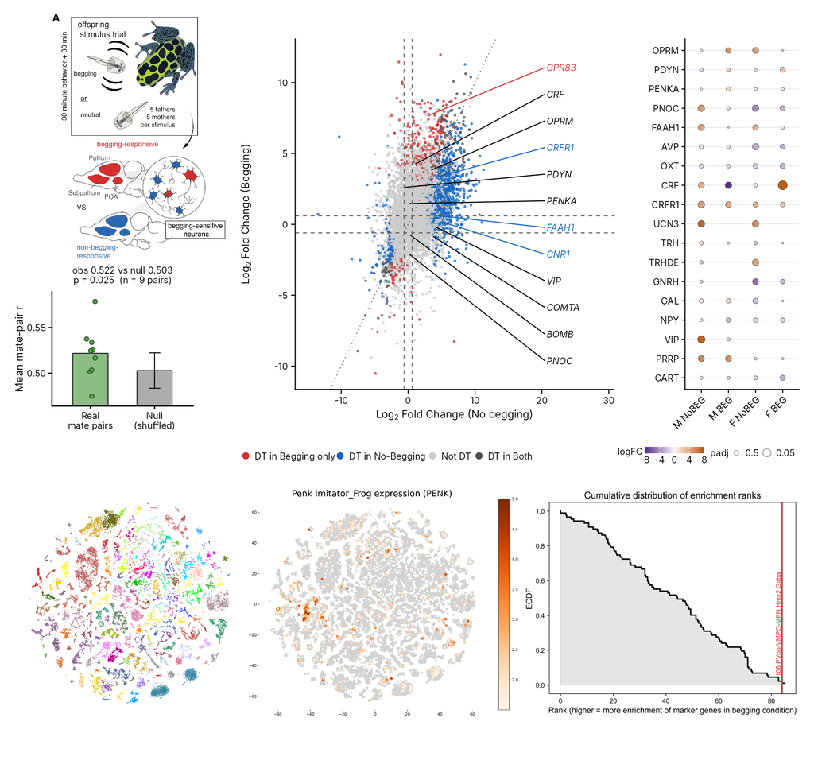

Figure 4.

The mate-pair test for all three brain regions:

**Code: mate-pair synchrony table**

```r
kable(derived("PairSynchrony_results.csv"))
```

| region | N_mate_pairs | observed_r | null_mean | null_sd | z | p_label_permutation |
| --- | --- | --- | --- | --- | --- | --- |
| POA | 9 | 0.5219 | 0.5030 | 0.0099 | 1.91 | 0.0245 |
| Pallium | 8 | 0.7312 | 0.7281 | 0.0035 | 0.89 | 0.2033 |
| Subpallium | 9 | 0.6767 | 0.6720 | 0.0048 | 0.99 | 0.1800 |

## 6 Figure 5: RNAscope and naltrexone

`Figure5_11162026.R` is one script for all of Figure 5. Panel A, the RNAscope micrographs, is the finished image `Figures/artwork/Figure5_micrographs.png`, placed across the top (its letter is part of the image). Panels B to F share the second row, G and H the third. Panels I to K are the naltrexone experiment: the injection timeline at the left, the box plots above the CarePC1 panels.

### 6.1 RNAscope (panels B to H)

Counts are summed over an animal’s images of a region. Fos density is Fos cells divided by the area counted (images with no area recorded are left out of density only). Recruitment is the share of a marker’s cells that are also Fos-positive.

One count is corrected while the file is read (the data file itself is not edited; the script prints the correction when it runs). Counts are nested: a cell positive for all three markers is also counted as Fos+Penk, Fos+Gal and Penk+Gal. The syn37 APOA row is the sum of six images, and for one of them (File8 Image33) the counting workbook has 18 triple-positive cells but 0 Fos+Penk cells, so the Fos+Penk category was not clicked for that image. Its Fos+Penk count is set to the minimum it can be, 18, which makes the row’s Fos+Penk 29 instead of 11. The original image was not available for a recount. This changes the APOA bar of panel D only slightly (Hodges-Lehmann shift 0.266 instead of 0.270; p = 0.0004 either way; the sex effect in that region stays just under 0.05, p = 0.0497 instead of 0.046).

| Panel | What it shows | Test |
| --- | --- | --- |
| B | Triple-positive cells as a share of Penk + Gal cells, anterior preoptic area and ventral hypothalamus, coordinating vs control | Mann-Whitney, Hodges-Lehmann shift (HL, coordinating − control) |
| C, D, E | Per region, the Hodges-Lehmann shift (coordinating − control; axis title “HL shift”) in Fos density, Penk recruitment and Gal recruitment | Mann-Whitney per region, Benjamini-Hochberg within each metric; two-way ANOVA for sex and sex × condition |
| F | Fos density in the BST by sex | Mann-Whitney within sex |
| G, H | Fos density (striatum, nucleus accumbens) and Penk recruitment (BST, DPVP) against the pair’s CarePC1, one point per breeding pair | Spearman |

### 6.2 Naltrexone (panels I to K)

Panel I is the injection timeline, the drawing `Figures/artwork/Figure5_naltrexone_timeline_stacked.png`. It sets the height of the naltrexone block: panels J and K are fitted into the height of the drawing.

| Panel | What it shows | Test |
| --- | --- | --- |
| J | Minutes per day, saline (Veh) vs naltrexone (NTX), in the order fathers in High-care tanks, fathers in Low-care tanks (blue), coordinated visits in High-care tanks, coordinated visits in Low-care tank… | paired t-test across tanks |
| K | Minutes per day against baseline CarePC1, by treatment: fathers, then coordinated visits | Mixed model `minutes ~ CarePC1 × treatment + (1 \| tank)`; the interaction tests whether naltrexone changes the slope |

The six naltrexone panels are also saved on their own in `Figures/Figure5_panels/`.

**Code: Functions/Figure5_11162026.R**

```r
#Figure5
# The micrographs are not drawn here: the top row places the finished image Figures/artwork/Figure5_micrographs.png.
# Bar annotation convention:
#   bold star  = BH-corrected q (q_MW) within that metric's regional screen
#   grey (star) in parens = uncorrected p (p_MW)
#   S = ANOVA Sex main effect p<0.05   I = ANOVA Sex x Condition p<0.05
# Dot convention (every per-animal/per-pair panel):
#   filled, colored by Sex  = Coord
#   hollow, outline colored by Sex = Control
#   Sex: Male = blue, Female = orange, Mixed (averaged breeding pair) = grey
# Pairs: mates are not independent, so the CarePC1 panels use one point per
# breeding pair (the mean of its two animals, or the one animal that was imaged). Which two samples form a pair comes from Supplementary/derived_tables/RNAscope_CarePC1_perPair.csv.
# Input:
#   Data/rnascope/Cleaned_Data_ForBillie_9-22-2026.csv   one row per image:
#       cell counts per marker and marker combination, and the area counted
#   Data/rnascope/rnascope_pairs.csv, Data/rnascope/event_logs/*.xlsx
#       the breeding pairs and their nest-visit event logs
#   Data/pharmacology/opioid-behavior-spreadsheet.xlsx  sheet "rawdata"
#       naltrexone experiment, one row per nest visit
#   Supplementary/derived_tables/CarePC1_rule.csv   the CarePC1 rule (Figure2_11162026.R; run that first)
#   Figures/artwork/Figure5_naltrexone_timeline_stacked.png   the injection timeline drawing
#   Figures/artwork/Figure5_micrographs.png   the micrograph panel
#   (if one of the two images is missing, a labelled placeholder is drawn in
#   its place and the rest of the figure is still made)
# Output:
#   Figures/Figure5_11112026.pdf / .png
#   Supplementary/derived_tables/RNAscope_CarePC1_perPair.csv          CarePC1 per breeding pair
#   Supplementary/derived_tables/Pharmacology_perTank.csv              naltrexone experiment, per tank
#   Supplementary/derived_tables/Figure5_region_stats_allmetrics.csv   per-region statistics, all 4 metrics
#   Supplementary/derived_tables/Figure5_CarePC1_region_stats.csv      pair-level Spearman, every region
#
# Open the .Rproj file (or set the working directory to the project folder) before running.
# =============================================================================

suppressPackageStartupMessages({
  library(tidyverse); library(patchwork); library(lmerTest)
})
JITTER_SEED <- 1   # fixes the sideways jitter of the points: every plot, the PDF and the PNG get the same positions on every run

repo_dir <- here::here()
fig_dir  <- file.path(repo_dir, "Figures")
out_dir  <- file.path(repo_dir, "Supplementary", "derived_tables")
dir.create(fig_dir, showWarnings = FALSE, recursive = TRUE)

CSV   <- file.path(repo_dir, "Data", "rnascope", "Cleaned_Data_ForBillie_9-22-2026.csv")
PAIRS <- file.path(out_dir, "RNAscope_CarePC1_perPair.csv")
stopifnot(file.exists(CSV))

# =============================================================================
# 0. CarePC1 for the two cohorts of this figure. Both are scored with the rule
#    fitted on the 26 reference recordings (Supplementary/derived_tables/CarePC1_rule.csv), so High
#    and Low mean the same thing as in Figure 2.
#    Writes Supplementary/derived_tables/RNAscope_CarePC1_perPair.csv and Pharmacology_perTank.csv.
# =============================================================================
local({
  raw_dir <- file.path(repo_dir, "Data")
  source(file.path(repo_dir, "Functions", "shared_functions.R"), local = TRUE)
  rule <- load_care_rule(file.path(out_dir, "CarePC1_rule.csv"))
  LONG_SOLO_VISIT_MIN <- 360                     # 6 h, as for the reference recordings

  # ---- RNAscope breeding pairs ---------------------------------------------------
  # rnascope_pairs.csv lists each breeding pair, its two brain samples, its event
  # log and the number of days in its recording window. The event logs are read
  # with exactly the same rules as the reference recordings
  # (shared_functions.R). Coordinated visits and minutes are divided by the
  # window length.
  pairs <- read.csv(file.path(raw_dir, "rnascope", "rnascope_pairs.csv"), stringsAsFactors = FALSE)
  log_dir <- file.path(raw_dir, "rnascope", "event_logs")

  family_totals <- function(event_log) {
    v <- read_visits(event_log, log_dir)
    family <- v[v$visitor == "Family", ]
    c(Visits_Family = nrow(family), Minutes_Family = sum(family$duration_min))
  }
  totals <- t(vapply(pairs$EventLog, family_totals, numeric(2)))
  pairs$Visits_Family  <- totals[, "Visits_Family"]
  pairs$Minutes_Family <- totals[, "Minutes_Family"]
  pairs$Visits_Family_perDay  <- pairs$Visits_Family  / pairs$WindowDays
  pairs$Minutes_Family_perDay <- pairs$Minutes_Family / pairs$WindowDays
  pairs$CarePC1   <- rule$care_pc1(pairs$Visits_Family_perDay, pairs$Minutes_Family_perDay)
  pairs$CareLevel <- rule$care_level(pairs$CarePC1)
  write.csv(pairs[, c("Pair", "Tank", "Cohort", "Sample1", "Sample2", "WindowDays",
                      "Visits_Family", "Minutes_Family", "Visits_Family_perDay",
                      "Minutes_Family_perDay", "CarePC1", "CareLevel")],
            PAIRS, row.names = FALSE)
  cat(sprintf("RNAscope: %d breeding pairs scored\n", nrow(pairs)))

  # ---- Naltrexone experiment: seven days per treatment --------------------------
  # One row per visit. Treatment F = saline, E = naltrexone; each tank received
  # both. Minutes per day = total minutes / 7 days. As for the reference
  # recordings, single-parent visits longer than 6 h are left out. Each tank's
  # CarePC1 and care level come from its saline week (its baseline). Tank B16 has
  # no parental visits and is left out.
  N_DAYS <- 7
  pharm <- suppressMessages(as.data.frame(
    read_excel(file.path(raw_dir, "pharmacology", "opioid-behavior-spreadsheet.xlsx"), sheet = "rawdata")))
  pharm <- data.frame(Tank = pharm$`Tank ID`,
                      Treatment = ifelse(pharm$Treatment == "F", "Saline", "Naltrexone"),
                      Visitor = pharm$Sex, minutes = as.numeric(pharm$TimeDifference_inminutes),
                      stringsAsFactors = FALSE)
  pharm <- pharm[pharm$Tank != "B16", ]
  pharm <- pharm[!(pharm$Visitor %in% c("Male", "Female") & pharm$minutes > LONG_SOLO_VISIT_MIN), ]
```

```r
  ph <- expand.grid(Tank = sort(unique(pharm$Tank)), Treatment = c("Saline", "Naltrexone"),
                    Visitor = c("Male", "Female", "Family"), stringsAsFactors = FALSE)
  key <- function(d) paste(d$Tank, d$Treatment, d$Visitor)
  ph$Visits  <- as.numeric(table(factor(key(pharm), key(ph))))
  ph$Minutes <- as.numeric(tapply(pharm$minutes, factor(key(pharm), key(ph)), sum))
  ph$Minutes[is.na(ph$Minutes)] <- 0
  ph$VisitsPerDay  <- ph$Visits  / N_DAYS
  ph$MinutesPerDay <- ph$Minutes / N_DAYS

  baseline <- ph[ph$Treatment == "Saline" & ph$Visitor == "Family", ]
  baseline$CarePC1   <- rule$care_pc1(baseline$VisitsPerDay, baseline$MinutesPerDay)
  baseline$CareLevel <- rule$care_level(baseline$CarePC1)
  ph <- merge(ph, baseline[, c("Tank", "CarePC1", "CareLevel")], by = "Tank")
  ph <- ph[order(ph$Tank, ph$Treatment, ph$Visitor), ]
  write.csv(ph, file.path(out_dir, "Pharmacology_perTank.csv"), row.names = FALSE)
  cat(sprintf("Naltrexone experiment: %d tanks; saline-week care level High = %d, Low = %d\n",
              nrow(baseline), sum(baseline$CareLevel == "High"), sum(baseline$CareLevel == "Low")))
})

# ---------- sizes ----------
# Final printed sizes (the figure is saved FIG_W = 14 in wide). Text in points,
# line widths in ggplot units. Change them here to restyle the whole figure.
PT_BASE   <- 13.8     # theme base size, plot titles, legend keys
PT_TITLE  <- 12.08    # axis titles, facet titles
PT_TEXT   <- 10.35    # tick labels, legend text, text inside the naltrexone panels
PT_TEXT_X <- 11.21    # x tick labels of the box plots in B and F
LW_AXIS   <- 0.49     # axis lines, ticks, bar outlines
LW_THIN   <- 0.37     # box outlines and brackets
MARGIN_BOX <- margin(t = 1.23, r = 12.32, b = 4.93, l = 4.93)   # around the box plots in B and F

# ---------- palettes & theme ----------
SEX_PALETTE <- c(Male = "#0077BB", Female = "#EE7733", Mixed = "grey45")
DIR_PAL     <- c("Coord higher" = "#1C2B39", "Control higher" = "white")  # ink navy

theme_nature <- theme_classic(base_size = PT_BASE, base_family = "sans") +
  theme(
    panel.grid        = element_blank(),
    axis.line         = element_line(linewidth = LW_AXIS),
    axis.ticks        = element_line(linewidth = LW_AXIS),
    axis.ticks.length = unit(2.46, "pt"),
    axis.title        = element_text(size = PT_TITLE),
    axis.text         = element_text(size = PT_TEXT),
    strip.background  = element_blank(),
    strip.text        = element_text(face = "bold", size = PT_TITLE),
    legend.background = element_blank(),
    legend.key.size   = unit(PT_BASE, "pt"),
    legend.text       = element_text(size = PT_TEXT),
    legend.title      = element_text(size = PT_TEXT),
    plot.title        = element_text(size = PT_BASE, face = "plain"))
theme_set(theme_nature)

# =============================================================================
# 1. Load & tidy — one row per SampleID x Sex x Condition x BrainRegion,
#    all 4 metrics. Region-code duplicates collapsed; Fos density excludes
#    images with a blank area field (see comment below).
# =============================================================================
collapse_map <- c(LP2 = "LP", LS2 = "LS", MP2 = "MP", MPOA2 = "MPOA",
                  NAC = "NACC", DPVPV = "DPVP",
                  STR2 = "STR", BST2 = "BST",
                  APOA2 = "APOA", DP2 = "DP",
                  DPVP2 = "DPVP", NACC2 = "NACC",
                  VH. = "VH", MERGED_VH = "VH")

dat <- read_csv(CSV, show_col_types = FALSE, name_repair = "unique") %>%
  rename(SampleID    = `Sample ID...1`,
         BrainRegion = brainregion,
         Fos_Penk    = `Fos+Penk`,
         Fos_Gal     = `Fos+Gal`,
         Penk_Gal    = `Penk + Gal`,
         All3        = `All.3`,
         Area        = area)

# Counts are nested: a cell positive for all three markers is also counted as Fos+Penk, Fos+Gal and Penk+Gal.
#The syn37 APOA row is the sum of six images of File8; in one of them (Image33) the counting workbook has 18 triple-positive cells but 0 Fos+Penk cells, so the Fos+Penk type was not saved for that image. Its Fos+Penk count is set to the minimum it can be, 18 (the triple-positive cells), which makes the row's Fos+Penk 29 instead of 11.
fix_row <- which(dat$SampleID == "syn37" & dat$BrainRegion == "APOA" &
                 dat$Fos_Penk == 11 & dat$All3 == 20)
if (length(fix_row) == 1) {
  dat$Fos_Penk[fix_row] <- 29
  cat("Correction: syn37 APOA Fos+Penk 11 -> 29 (File8 Image33: Fos+Penk set to its minimum, the 18 triple-positive cells)\n")
} else {
  cat("Correction for syn37 APOA not applied: the row is not as expected (already corrected in the data file?)\n")
}

dat <- dat %>%
  mutate(Condition   = recode(str_to_title(str_trim(Condition)), Treated = "Coord"),
         Sex         = str_to_title(str_trim(Sex)),
         BrainRegion = recode(BrainRegion, !!!collapse_map),
         across(c(Fos, Penk, Gal, Fos_Penk, Fos_Gal, Penk_Gal, All3, Area), as.numeric)) %>%
  group_by(SampleID, Sex, Condition, BrainRegion) %>%
  # Fos density uses only images that HAVE an area
  # The ratio metrics don't need area, so they keep every image.
  summarise(Fos_wArea = sum(Fos[!is.na(Area)], na.rm = TRUE),
            across(c(Fos, Penk, Gal, Fos_Penk, Fos_Gal, Penk_Gal, All3, Area),
                   ~ sum(.x, na.rm = TRUE)),
            .groups = "drop") %>%
  mutate(Fos_density   = ifelse(Area > 0,     Fos_wArea / Area * 1e6, NA_real_),
         FosPenk_ratio = ifelse(Penk > 0,     Fos_Penk / Penk,       NA_real_),
         FosGal_ratio  = ifelse(Gal > 0,      Fos_Gal  / Gal,        NA_real_),
         All3_PenkGal  = ifelse(Penk_Gal > 0, All3     / Penk_Gal,   NA_real_))

cat(sprintf("Loaded %d animal x region rows, %d animals, %d regions\n",
            nrow(dat), n_distinct(dat$SampleID), n_distinct(dat$BrainRegion)))

#loaded 289 animal x region rows, 33 animals, 16 regions
# =============================================================================
# 2. Per-region nonparametric stats, all 4 metrics:
#    Mann-Whitney (Coord vs Control) + Hodges-Lehmann shift + CI,
#    BH correction across regions WITHIN each metric's screen,
#    plus a 2-way ANOVA (Sex x Condition) per region for the S / I tags.
#    Regions are only included where every Sex x Condition cell has n >= 3.
# =============================================================================
per_region_HL <- function(d, value_col, min_n = 2) {
  d %>%
    filter(!is.na(.data[[value_col]])) %>%
    group_by(BrainRegion) %>%
    group_modify(~ {
      dd <- .x
      x <- dd[[value_col]][dd$Condition == "Coord"]
      y <- dd[[value_col]][dd$Condition == "Control"]
      n_Coord <- length(x); n_Control <- length(y)
      if (n_Coord < min_n || n_Control < min_n) return(tibble::tibble())
      wt <- suppressWarnings(wilcox.test(x, y, conf.int = TRUE, exact = FALSE))
      tibble::tibble(n_Coord = n_Coord, n_Control = n_Control,
                     mean_Coord = mean(x), mean_Control = mean(y),
                     HL = unname(wt$estimate), HL_lo = wt$conf.int[1], HL_hi = wt$conf.int[2],
                     p_MW = wt$p.value)
    }) %>% ungroup() %>%
    mutate(metric = value_col, q_MW = p.adjust(p_MW, method = "BH"),
           star = case_when(p_MW < 0.001 ~ "***", p_MW < 0.01 ~ "**",
                            p_MW < 0.05 ~ "*", p_MW < 0.10 ~ ".", TRUE ~ ""))
}
anova_terms <- function(data, value_col, min_cell_n = 2) {
  data %>%
    filter(!is.na(.data[[value_col]])) %>%
    group_by(BrainRegion) %>%
    group_modify(~ {
      d <- .x
      cell_n <- d %>% count(Sex, Condition)
      ok <- nrow(cell_n) == 4 && all(cell_n$n >= min_cell_n)
      if (!ok) return(tibble::tibble(p_sex = NA_real_, p_cond = NA_real_, p_int = NA_real_))
      fit <- tryCatch(lm(d[[value_col]] ~ Sex * Condition, data = d), error = function(e) NULL)
      if (is.null(fit)) return(tibble::tibble(p_sex = NA_real_, p_cond = NA_real_, p_int = NA_real_))
      a <- tryCatch(stats::anova(fit), error = function(e) NULL)
      if (is.null(a)) return(tibble::tibble(p_sex = NA_real_, p_cond = NA_real_, p_int = NA_real_))
      tibble::tibble(p_sex = a["Sex", "Pr(>F)"], p_cond = a["Condition", "Pr(>F)"], p_int = a["Sex:Condition", "Pr(>F)"])
    }) %>% ungroup()
}
regions_min3 <- function(data, value_col, min_cell_n = 3) {
  data %>%
    filter(!is.na(.data[[value_col]])) %>%
    count(BrainRegion, Sex, Condition) %>%
    group_by(BrainRegion) %>%
    summarise(n_cells = n(), min_n = min(n), .groups = "drop") %>%
    filter(n_cells == 4, min_n >= min_cell_n) %>%
    pull(BrainRegion)
}
cliffs_d_fn <- function(a, b) {
  a <- a[!is.na(a)]; b <- b[!is.na(b)]
  if (length(a) == 0 || length(b) == 0) return(NA_real_)
  mean(outer(a, b, ">")) - mean(outer(a, b, "<"))
}
```

```r
build_panel_data <- function(value_col) {
  st    <- per_region_HL(dat, value_col)
  terms <- anova_terms(dat, value_col)
  keep  <- regions_min3(dat, value_col)
  cd    <- dat %>% filter(!is.na(.data[[value_col]]), BrainRegion %in% keep) %>%
    group_by(BrainRegion) %>%
    summarise(cliffs_delta = cliffs_d_fn(.data[[value_col]][Condition == "Coord"],
                                         .data[[value_col]][Condition == "Control"]),
              .groups = "drop")
  st %>% filter(BrainRegion %in% keep) %>%
    left_join(terms, by = "BrainRegion") %>%
    left_join(cd, by = "BrainRegion") %>%
    mutate(direction = factor(ifelse(HL >= 0, "Coord higher", "Control higher"),
                              levels = c("Control higher", "Coord higher")),
           sex_sig = !is.na(p_sex) & p_sex < 0.05,
           int_sig = !is.na(p_int) & p_int < 0.05,
           tag = paste0(ifelse(sex_sig, " S", ""), ifelse(int_sig, " I", "")))
}
sd_ <- build_panel_data("Fos_density")
sr_ <- build_panel_data("FosPenk_ratio")
sg_ <- build_panel_data("FosGal_ratio")
sa_ <- build_panel_data("All3_PenkGal")

# ---- supplementary table: all 4 metrics, same schema ----
supp_all <- bind_rows(
  sd_ %>% mutate(Metric = "Fos density"),
  sr_ %>% mutate(Metric = "(Fos+Penk)/Penk"),
  sg_ %>% mutate(Metric = "(Fos+Gal)/Gal"),
  sa_ %>% mutate(Metric = "All3/(Penk+Gal)")
) %>%
  transmute(Metric, BrainRegion, n_Coord, n_Control,
            mean_Coord = round(mean_Coord, 3), mean_Control = round(mean_Control, 3),
            HL = round(HL, 3), HL_lo = round(HL_lo, 3), HL_hi = round(HL_hi, 3),
            cliffs_delta = round(cliffs_delta, 3),
            p_condition_MW = signif(p_MW, 3), q_condition_BH = signif(q_MW, 3),
            p_sex_ANOVA = signif(p_sex, 3), p_interaction_ANOVA = signif(p_int, 3),
            star_condition = star,
            sex_sig = ifelse(sex_sig, "Y", ""), interaction_sig = ifelse(int_sig, "Y", "")) %>%
  arrange(Metric, desc(abs(HL)))
write.csv(supp_all, file.path(out_dir, "Figure5_region_stats_allmetrics.csv"), row.names = FALSE)
cat("\n=== Per-region stats, all 4 metrics (BH-corrected within metric) ===\n")
print(supp_all %>% filter(q_condition_BH < 0.10 | sex_sig == "Y" | interaction_sig == "Y"), n = 50)

# Panel builders

# ---- 3a. Single region, sexes combined on x-axis, filled/hollow + sex color ----
cond_sex_panel <- function(region, metric, title, ylab) {
  d <- dat %>% filter(BrainRegion == region, !is.na(.data[[metric]])) %>%
    mutate(Condition = factor(Condition, levels = c("Control", "Coord")),
           point_fill = ifelse(Condition == "Coord", SEX_PALETTE[Sex], "white"),
           point_col  = SEX_PALETTE[Sex])
  wt <- suppressWarnings(wilcox.test(d[[metric]] ~ d$Condition, conf.int = TRUE, exact = FALSE))
  ymax <- max(d[[metric]], na.rm = TRUE)
  # wilcox.test gives Control - Coord (the order of the factor levels); the sign is
  # flipped so HL is Coord - Control, as in the bar charts
  lab <- sprintf("p=%.3f\nHL=%+.3g", wt$p.value, -unname(wt$estimate))
  ggplot(d, aes(x = Condition, y = .data[[metric]])) +
    geom_boxplot(aes(group = Condition), outlier.shape = NA, width = 0.5, alpha = 0.0,
                 color = "grey30", linewidth = LW_THIN) +
    geom_jitter(aes(fill = point_fill, color = point_col),
                position = position_jitter(width = 0.08, height = 0, seed = JITTER_SEED), shape = 21, size = 2.46,
                stroke = 0.62, alpha = 0.95) +
    scale_fill_identity() + scale_color_identity() +
    geom_segment(aes(x = 1, xend = 2, y = ymax * 1.08, yend = ymax * 1.08),
                 inherit.aes = FALSE, linewidth = LW_THIN) +
    annotate("text", x = 1.5, y = ymax * 1.26, label = lab, size = 3.62, lineheight = 0.9) +
    annotate("text", x = 1.5, y = ymax * 1.47, label = "Male",   color = SEX_PALETTE["Male"],   size = 3.62, hjust = 1.1) +
    annotate("text", x = 1.5, y = ymax * 1.47, label = "Female", color = SEX_PALETTE["Female"], size = 3.62, hjust = -0.1) +
    scale_y_continuous(limits = c(0, ymax * 1.55), expand = expansion(mult = c(0.02, 0.04))) +   # room above the points for the test result and the sex key
    scale_x_discrete(labels = c(Control = "Ctl", Coord = "Coord"), expand = expansion(add = 0.7)) +
    coord_cartesian(clip = "off") +          # the sex key may run past the narrow panel's edge
    labs(title = NULL, x = NULL, y = ylab) +
    theme_nature +
    theme(axis.text.x = element_text(size = PT_TEXT_X),
          plot.margin = MARGIN_BOX)
}
p_apoa_all3 <- cond_sex_panel("APOA", "All3_PenkGal", "APOA All3/(Penk+Gal)", "All3 / (Penk+Gal)")
p_apoa_all3
p_vh_all3   <- cond_sex_panel("VH",   "All3_PenkGal", "VH All3/(Penk+Gal)",   "All3 / (Penk+Gal)")
p_vh_all3

# BST, sex-faceted (the one Sex x Condition interaction in the screen) ----
d_bst <- dat %>% filter(BrainRegion == "BST", !is.na(Fos_density)) %>%
  mutate(Condition = factor(Condition, levels = c("Control", "Coord")),
         point_fill = ifelse(Condition == "Coord", SEX_PALETTE[Sex], "white"),
         point_col  = SEX_PALETTE[Sex])
p_male_bst   <- suppressWarnings(wilcox.test(Fos_density ~ Condition, data = d_bst,
                                              subset = Sex == "Male", exact = FALSE))$p.value
p_female_bst <- suppressWarnings(wilcox.test(Fos_density ~ Condition, data = d_bst,
                                              subset = Sex == "Female", exact = FALSE))$p.value
ymax_bst <- max(d_bst$Fos_density, na.rm = TRUE)
ann_bst <- data.frame(Sex = c("Male", "Female"),
                       label = c(sprintf("p=%.3f", p_male_bst), sprintf("p=%.3f", p_female_bst)))

p_bst_d <- ggplot(d_bst, aes(x = Condition, y = Fos_density)) +
  geom_boxplot(aes(group = Condition), outlier.shape = NA, width = 0.5, alpha = 0.0,
               color = "grey30", linewidth = LW_THIN) +
  geom_jitter(aes(fill = point_fill, color = point_col),
              position = position_jitter(width = 0.08, height = 0, seed = JITTER_SEED), shape = 21, size = 2.46, stroke = 0.62, alpha = 0.95) +
  scale_fill_identity() + scale_color_identity() +
  geom_segment(aes(x = 1, xend = 2, y = ymax_bst * 1.08, yend = ymax_bst * 1.08),
               inherit.aes = FALSE, linewidth = LW_THIN) +
  geom_text(data = ann_bst, aes(x = 1.5, y = ymax_bst * 1.18, label = label),
            inherit.aes = FALSE, size = 3.62) +
  facet_wrap(~ Sex) +
  scale_x_discrete(labels = c(Control = "Ctl", Coord = "Coord")) +
  scale_y_continuous(limits = c(0, ymax_bst * 1.3), expand = expansion(mult = c(0.02, 0.05))) +
  labs(title = NULL, x = NULL,
       y = expression("Fos density (cells/mm"^2*")")) +
  theme_nature +
  theme(axis.text.x = element_text(size = PT_TEXT_X), plot.title = element_text(size = PT_TITLE),
        strip.text = element_text(size = PT_TEXT_X),
        plot.margin = MARGIN_BOX)
```

```r
p_bst_d
# Regional screen diverging bars

add_tiers <- function(d) d %>% mutate(
  star_bh  = case_when(q_MW < 0.001 ~ "***", q_MW < 0.01 ~ "**", q_MW < 0.05 ~ "*", TRUE ~ ""),
  star_unc = case_when(p_MW < 0.001 ~ "***", p_MW < 0.01 ~ "**", p_MW < 0.05 ~ "*", p_MW < 0.10 ~ ".", TRUE ~ ""))
sd2 <- add_tiers(sd_); sr2 <- add_tiers(sr_); sg2 <- add_tiers(sg_)

min_bar <- function(d) {
  rng <- range(d$HL, na.rm = TRUE)
  eps <- diff(rng) * 0.015
  d %>% mutate(HL_draw = ifelse(abs(HL) < eps, eps * sign(ifelse(HL == 0, 1, HL)), HL))
}
sd2 <- min_bar(sd2); sr2 <- min_bar(sr2); sg2 <- min_bar(sg2)

make_bar4 <- function(d, title, xlab, show_legend = FALSE) {
  d <- d %>% mutate(BrainRegion = fct_reorder(BrainRegion, HL))
  rng <- range(d$HL, na.rm = TRUE)
  pad <- diff(rng) * 0.3
  d <- d %>% mutate(lbl_bh = star_bh,
                     lbl_unc = ifelse(star_unc == "", "", paste0("(", star_unc, ")")),
                     lbl_tag = tag)
  ggplot(d, aes(y = BrainRegion, x = HL_draw, fill = direction)) +
    geom_col(width = 0.65, color = DIR_PAL["Coord higher"], linewidth = LW_AXIS) +
    geom_text(aes(label = lbl_bh,  x = HL_draw + sign(ifelse(HL_draw==0,1,HL_draw)) * (pad*0.25 + 0.01*max(abs(rng)))),
              size = 3.80, color = "black", hjust = 0, fontface = "bold") +
    geom_text(aes(label = lbl_unc, x = HL_draw + sign(ifelse(HL_draw==0,1,HL_draw)) * (pad*1.00 + 0.01*max(abs(rng)))),
              size = 3.45, color = "grey50", hjust = 0, fontface = "plain") +
    geom_text(aes(label = lbl_tag, x = HL_draw + sign(ifelse(HL_draw==0,1,HL_draw)) * (pad*2.35 + 0.01*max(abs(rng)))),
              size = 3.80, color = "black", hjust = 0, fontface = "bold") +
    geom_vline(xintercept = 0, color = "grey40", linewidth = LW_AXIS) +
    scale_fill_manual(values = DIR_PAL, name = NULL, limits = names(DIR_PAL), drop = FALSE) +
    scale_x_continuous(limits = c(rng[1] - pad, rng[2] + pad*3.0)) +
    labs(title = NULL, x = xlab, y = NULL) +
    theme_nature +
    theme(legend.position = if (show_legend) "inside" else "none",
          legend.position.inside = c(0.78, 0.22),
          legend.justification.inside = c(0.5, 0.5),
          legend.background = element_rect(fill = alpha("white", 0.75), color = NA),
          legend.margin = margin(t = 1, r = 2, b = 1, l = 2),
          axis.text.y = element_text(size = PT_TEXT))
}
# HL shift = Hodges-Lehmann shift, Coord - Control (the axis titles are short: five panel groups share the row)
p_bar_d <- make_bar4(sd2, "Fos density", expression("HL shift (cells/mm"^2*")"), show_legend = TRUE)
p_bar_d
p_bar_r <- make_bar4(sr2, "(Fos+Penk) / Penk", "HL shift (ratio)")
p_bar_r
p_bar_g <- make_bar4(sg2, "(Fos+Gal) / Gal", "HL shift (ratio)")
p_bar_g
# CarePC1 vs Fos activity, pair-averaged (mates are not independent, so
#    each breeding pair contributes one point per region
CARE_DENSITY_REGIONS <- c("STR", "NACC")
CARE_RECRUIT_REGIONS <- c("BST", "DPVP")

# one row per sample: the breeding pair it belongs to and that pair's CarePC1
care <- read.csv(PAIRS, stringsAsFactors = FALSE) %>%
  pivot_longer(c(Sample1, Sample2), values_to = "SampleID_match") %>%
  filter(SampleID_match != "") %>%
  transmute(SampleID_match, pair = Pair, CarePC1)

mer <- dat %>%
  mutate(SampleID_match = gsub("^syn(\\d+)$", "syn_\\1", SampleID)) %>%
  inner_join(care, by = "SampleID_match")

pair_metric <- function(col) {
  mer %>%
    filter(!is.na(.data[[col]])) %>%
    group_by(BrainRegion, pair) %>%
    summarise(value   = mean(.data[[col]]),
              CarePC1 = mean(CarePC1), .groups = "drop")
}
pair_dens    <- pair_metric("Fos_density")
pair_recruit <- pair_metric("FosPenk_ratio")

pair_meta <- mer %>%
  group_by(pair) %>%
  summarise(Condition = first(Condition),
            Sex_label = ifelse(n_distinct(Sex) == 2, "Mixed", first(Sex)),
            .groups = "drop")
pair_dens    <- pair_dens    %>% left_join(pair_meta, by = "pair")
pair_recruit <- pair_recruit %>% left_join(pair_meta, by = "pair")

spearman_safe <- function(x, y) {
  ok <- complete.cases(x, y)
  x <- x[ok]; y <- y[ok]
  if (length(x) < 5 || sd(x) == 0 || sd(y) == 0)
    return(list(n = length(x), rho = NA_real_, p = NA_real_))
  ct <- tryCatch(suppressWarnings(cor.test(x, y, method = "spearman", exact = FALSE)),
                 error = function(e) NULL)
  if (is.null(ct)) return(list(n = length(x), rho = NA_real_, p = NA_real_))
  list(n = length(x), rho = unname(ct$estimate), p = ct$p.value)
}
region_stats <- function(pd) {
  pd %>% group_by(BrainRegion) %>%
    group_modify(~ { s <- spearman_safe(.x$CarePC1, .x$value)
                     tibble::tibble(n = s$n, rho = s$rho, p = s$p) }) %>%
    ungroup() %>% filter(!is.na(rho)) %>% arrange(p)
}
care_stats_dens    <- region_stats(pair_dens)
care_stats_recruit <- region_stats(pair_recruit)
care_stats <- bind_rows(mutate(care_stats_dens,    metric = "Fos_density"),
                        mutate(care_stats_recruit, metric = "FosPenk_recruitment"))
write.csv(care_stats, file.path(out_dir, "Figure5_CarePC1_region_stats.csv"), row.names = FALSE)
cat("\n=== CarePC1 vs Fos density / (Fos+Penk)/Penk, pair-level Spearman ===\n")
print(care_stats, n = 100)

care_scatter2 <- function(pd, st, regions, ylab) {
  d  <- pd %>% filter(BrainRegion %in% regions) %>%
    mutate(BrainRegion = factor(BrainRegion, levels = regions),
           Condition = factor(Condition, levels = c("Control", "Coord")),
           point_fill = ifelse(Condition == "Coord", SEX_PALETTE[Sex_label], "white"),
           point_col  = SEX_PALETTE[Sex_label])
  sl <- st %>% filter(BrainRegion %in% regions) %>%
    mutate(BrainRegion = factor(BrainRegion, levels = regions),
           lab = sprintf("rho = %+.2f\np %s\n%d pairs", rho,
                         ifelse(p < 0.001, "< 0.001", sprintf("= %.3f", p)), n))
  ggplot(d, aes(x = CarePC1, y = value)) +
    geom_smooth(method = "lm", se = FALSE, color = "grey40",
                linetype = "dashed", linewidth = LW_AXIS) +
    geom_point(aes(fill = point_fill, color = point_col),
               shape = 21, size = 2.22, stroke = 0.55, alpha = 0.95) +
    scale_fill_identity() + scale_color_identity() +
    facet_wrap(~ BrainRegion, scales = "free_y", nrow = 1,
               labeller = as_labeller(c(STR = "STR", NACC = "NAcc", BST = "BST",
                                        DPVP = "DPVP"), default = identity)) +
    geom_text(data = sl, aes(x = -Inf, y = Inf, label = lab),
              hjust = -0.08, vjust = 1.15, size = 3.45, lineheight = 0.9,
              inherit.aes = FALSE) +
    scale_y_continuous(expand = expansion(mult = c(0.05, 0.35))) +
    labs(x = "CarePC1", y = ylab) +
    theme_nature +
    theme(legend.position = "none", strip.text = element_text(size = PT_TITLE))
}
pcap_dens    <- care_scatter2(pair_dens,    care_stats_dens,    CARE_DENSITY_REGIONS,
                              expression("Fos density (cells/mm"^2*")"))
pcap_recruit <- care_scatter2(pair_recruit, care_stats_recruit, CARE_RECRUIT_REGIONS,
                              "(Fos+Penk) / Penk")
```

```r
ROW1_H <- 3.278       # plot-area height of the row with B to F (the bar charts need the height for their region labels)
ROW2_H <- 1.60        # plot-area height of the row with G and H
FIG_W   <- 14.0       # width the figure is saved at: every row is squeezed into the width of the micrograph strip

p_care <- (pcap_dens | pcap_recruit)   # native vector patchwork composition, no raster round-trip


# "A" is part of the micrograph image. The rest are added here, one per panel
# group, at the top left of the group's first plot.
LETTER <- c(triple = "B", fos_density = "C", penk = "D", gal = "E", bst = "F",
            care_density = "G", care_penk = "H", timeline = "I", ntx_boxes = "J", ntx_care = "K")
lettered <- function(p, key) p + labs(tag = LETTER[[key]]) +
  theme(plot.tag = element_text(face = "bold", size = 20, color = "black"),
        plot.tag.position = "topleft")
p_apoa_all3  <- lettered(p_apoa_all3,  "triple")
p_bar_d      <- lettered(p_bar_d,      "fos_density")
p_bar_r      <- lettered(p_bar_r,      "penk")
p_bar_g      <- lettered(p_bar_g,      "gal")
p_bst_d      <- lettered(p_bst_d,      "bst")
pcap_dens    <- lettered(pcap_dens,    "care_density")
pcap_recruit <- lettered(pcap_recruit, "care_penk")
p_care       <- (pcap_dens | pcap_recruit)

row1 <- (p_apoa_all3 | p_vh_all3 | p_bar_d | p_bar_r | p_bar_g | p_bst_d) +
  plot_layout(widths = c(1.7, 1.7, 2.95, 2.95, 2.95, 3.3))
row1
row2 <- p_care

# naltrexone and parental care

# Input: Supplementary/derived_tables/Pharmacology_perTank.csv (one row per tank, treatment and
#        visitor, with the tank's saline-week CarePC1 and care level) and
#        Supplementary/derived_tables/CarePC1_rule.csv (the High/Low cutoff). The first is written
#        in section 0 of this script, the second by Figure2_11162026.R.
# The six panels are also saved on their own in Figures/Figure5_panels/.
panel_dir <- file.path(fig_dir, "Figure5_panels")
dir.create(panel_dir, showWarnings = FALSE, recursive = TRUE)

cutoff  <- read.csv(file.path(repo_dir, "Supplementary", "derived_tables", "CarePC1_rule.csv"))$Threshold[1]
dat_fam <- read.csv(file.path(repo_dir, "Supplementary", "derived_tables", "Pharmacology_perTank.csv"), stringsAsFactors = FALSE) |>
  rename(Sex = Visitor, Treatment_label = Treatment) |>
  mutate(Treatment_label = factor(Treatment_label, levels = c("Saline", "Naltrexone")),
         CareLevel       = factor(CareLevel,       levels = c("High", "Low")))

# ---- Figure-1 palettes (SEX_CARE_PALETTE / CARE_PALETTE) for the family row ----
SEX_CARE  <- c("Male.High" = "#0077BB", "Male.Low" = "#7FBBDD",
               "Family.High" = "#005F52", "Family.Low" = "#B2E4DB")
sex_dark  <- c(Male = "#0077BB", Family = "#005F52")   # sex hue (naltrexone / outline)
THEME_ROW <- theme_classic(base_size = 9) +
  theme(panel.border = element_blank(), panel.grid = element_blank(),
        axis.line  = element_line(color = "black", linewidth = LW_AXIS),
        axis.ticks = element_line(color = "black", linewidth = LW_AXIS),
        axis.title = element_text(size = PT_TITLE),
        axis.text  = element_text(size = PT_TEXT),
        axis.text.x = element_text(size = PT_TEXT),
        legend.position = "none")
NTX_TEXT <- PT_TEXT / ggplot2::.pt             # in-plot text of the naltrexone panels (mm)


#stats

cat("Saline-week CarePC1 and care level per tank:\n")

print(unique(dat_fam[, c("Tank", "CarePC1", "CareLevel")]), row.names = FALSE)
#Tank    CarePC1 CareLevel
#A9 -0.5056289       Low
#B15  2.0100082      High
#B7 -1.5363606       Low
#B9 -0.2893995       Low
#D10 -1.5363606       Low
#D15 -0.3139595       Low
#D16 -0.2784840       Low
#D8  2.2921238      High
#E5 -1.3873126       Low
#E6 -1.5363606       Low
#E8 -1.5363606       Low
#F2  0.3921736      High
#F7 -0.8702586       Low


for (sex_value in c("Male", "Family")) for (care_value in c("High", "Low")) {
  wide <- dat_fam |> filter(Sex == sex_value, CareLevel == care_value) |>
    pivot_wider(id_cols = Tank, names_from = Treatment_label, values_from = MinutesPerDay)
  tt <- t.test(wide$Naltrexone, wide$Saline, paired = TRUE)
  cat(sprintf("%-6s %-4s care: n=%d tanks, saline %.1f vs naltrexone %.1f min/day, paired t=%+.2f, p=%.4f\n",
              ifelse(sex_value == "Male", "Father", "Coord."), care_value, nrow(wide),
              mean(wide$Saline), mean(wide$Naltrexone), tt$statistic, tt$p.value))
}

#Father High care: n=3 tanks, saline 34.0 vs naltrexone 13.3 min/day, paired t=-5.10, p=0.0364
#Father Low  care: n=10 tanks, saline 14.9 vs naltrexone 15.7 min/day, paired t=+0.18, p=0.8598
#Coord. High care: n=3 tanks, saline 114.6 vs naltrexone 32.7 min/day, paired t=-3.40, p=0.0767
#Coord. Low  care: n=10 tanks, saline 6.7 vs naltrexone 10.3 min/day, paired t=+1.59, p=0.1463

for (sex_value in c("Male", "Family")) {
  co <- summary(lmerTest::lmer(MinutesPerDay ~ CarePC1 * Treatment_label + (1 | Tank),
                               data = filter(dat_fam, Sex == sex_value)))$coefficients
  i  <- grep("CarePC1:Treatment", rownames(co))
  cat(sprintf("%-6s CarePC1 x treatment: slope under saline %+.2f, change under naltrexone %+.2f, t(%.0f)=%+.2f, p=%.4f\n",
              ifelse(sex_value == "Male", "Father", "Coord."), co["CarePC1", "Estimate"],
              co[i, "Estimate"], co[i, "df"], co[i, "t value"], co[i, "Pr(>|t|)"]))
}

#Father CarePC1 x treatment: slope under saline +9.25, change under naltrexone -9.14, t(11)=-3.68, p=0.0036
#Coord. CarePC1 x treatment: slope under saline +38.06, change under naltrexone -25.51, t(11)=-4.33, p=0.0012

# Boxplot panel: Naltrexone solid / Saline hollow. show_y: draw the y-axis title
# (only the first of the four panels has it).
make_box <- function(sex_value, care_value, sexkey, ymax, show_y = FALSE) {
  d <- dat_fam |> filter(Sex == sex_value, CareLevel == care_value)
  idcol <- SEX_CARE[[paste0(sexkey, ".", care_value)]]
  outline <- sex_dark[[sexkey]]
  wide <- d |> pivot_wider(id_cols = Tank, names_from = Treatment_label,
                           values_from = MinutesPerDay) |> drop_na(Saline, Naltrexone)
  p_label <- if (nrow(wide) >= 2 && sd(wide$Naltrexone - wide$Saline) > 0) {
    pv <- t.test(wide$Naltrexone, wide$Saline, paired = TRUE)$p.value
    if (pv < 0.01) "p < 0.01" else if (pv < 0.05) sprintf("p = %.3f", pv) else "ns"
  } else "n.s."
  by_ <- ymax * 0.85; bt_ <- ymax * 0.02; ty_ <- ymax * 0.93
  ggplot(d, aes(Treatment_label, MinutesPerDay, fill = Treatment_label)) +
    geom_boxplot(outlier.shape = NA, color = outline, linewidth = 0.7, width = 0.6, alpha = 0.95) +
    geom_line(aes(group = Tank), color = "#9E9E9E", alpha = 0.6, linewidth = 0.4) +
    geom_jitter(position = position_jitter(width = 0.07, height = 0, seed = JITTER_SEED), size = 1.9, shape = 21,
                fill = idcol, color = outline, stroke = 0.4, alpha = 0.85) +
    stat_summary(fun = mean, geom = "point", shape = 23, fill = "white",
                 color = "black", size = 3, stroke = 0.9) +
    scale_fill_manual(values = c("Saline" = "white", "Naltrexone" = idcol)) +
    annotate("segment", x = 1, xend = 2, y = by_, yend = by_, linewidth = 0.5) +
    annotate("segment", x = 1, xend = 1, y = by_ - bt_, yend = by_, linewidth = 0.5) +
    annotate("segment", x = 2, xend = 2, y = by_ - bt_, yend = by_, linewidth = 0.5) +
    annotate("text", x = 1.5, y = ty_, label = p_label, size = NTX_TEXT, vjust = 0.1) +   # vjust lifts it clear of the bracket
    scale_x_discrete(labels = c(Saline = "Veh", Naltrexone = "NTX")) +
    ylim(0, ymax) +
    labs(x = NULL, y = if (show_y) "Minutes / day" else NULL) +
    THEME_ROW
}
```

```r
# lmerTest CarePC1 x Treatment interaction (Satterthwaite) -> slope-difference p
interaction_p <- function(sex_value) {
  d <- dat_fam |> filter(Sex == sex_value)
  co <- summary(lmerTest::lmer(MinutesPerDay ~ CarePC1 * Treatment_label + (1 | Tank),
                               data = d))$coefficients
  co[grep("CarePC1:Treatment", rownames(co)), "Pr(>|t|)"]
}

interaction_p

# Scatter panel
make_scatter <- function(sex_value, sexkey, ymax) {
  d <- dat_fam |> filter(Sex == sex_value)
  pv <- interaction_p(sex_value)
  p_txt <- if (pv < 0.01) "interaction p < 0.01" else sprintf("interaction p = %.3f", pv)
  col <- sex_dark[[sexkey]]
  sal <- dplyr::filter(d, Treatment_label == "Saline")
  nal <- dplyr::filter(d, Treatment_label == "Naltrexone")
  lx0 <- min(d$CarePC1); lx1 <- lx0 + 0.45; ltx <- lx0 + 0.6
  # The key sits in head-room above the data: the p value, then both treatments side by side
  y_p   <- ymax * 1.36                             # p value
  y_key <- ymax * 1.08                             # Naltrexone and Saline keys
  dx    <- 1.75                                    # Saline key, this far right of the Naltrexone key
  y_top <- ymax * 1.38
  ggplot(d, aes(CarePC1, MinutesPerDay)) +
    geom_smooth(data = sal, method = "lm", se = TRUE,
                color = col, fill = col, alpha = 0.10, linewidth = 0.7) +
    geom_smooth(data = nal, method = "lm", se = TRUE,
                color = col, fill = col, alpha = 0.14, linewidth = 1.6) +
    geom_point(aes(fill = Treatment_label), shape = 21, color = col,
               size = 1.9, stroke = 0.5, alpha = 0.9) +
    geom_vline(xintercept = cutoff, linetype = "dotted", color = "grey60") +
    scale_fill_manual(values = c("Saline" = "white", "Naltrexone" = col)) +
    annotate("text", x = -Inf, y = y_p, hjust = 0, vjust = 1,
             label = p_txt, size = NTX_TEXT) +
    annotate("segment", x = lx0, xend = lx1, y = y_key, yend = y_key,
             color = col, linewidth = 1.4) +
    annotate("point", x = (lx0 + lx1) / 2, y = y_key, shape = 21,
             fill = col, color = col, size = 1.7) +
    annotate("text", x = ltx, y = y_key, hjust = 0, vjust = 0.5,
             label = "Naltrexone", color = col, size = NTX_TEXT) +
    annotate("segment", x = lx0 + dx, xend = lx1 + dx, y = y_key, yend = y_key,
             color = col, linewidth = 0.7) +
    annotate("point", x = (lx0 + lx1) / 2 + dx, y = y_key, shape = 21,
             fill = "white", color = col, size = 1.7) +
    annotate("text", x = ltx + dx, y = y_key, hjust = 0, vjust = 0.5,
             label = "Saline", color = col, size = NTX_TEXT) +
    coord_cartesian(ylim = c(0, y_top)) +   # crop view without deleting ribbon
    labs(x = "Baseline CarePC1", y = NULL) +
    THEME_ROW
}

ymax_father <- max(dat_fam$MinutesPerDay[dat_fam$Sex == "Male"],   na.rm = TRUE) * 1.15
ymax_family <- max(dat_fam$MinutesPerDay[dat_fam$Sex == "Family"], na.rm = TRUE) * 1.15

# The six panels, in the order father High, coordinated High, father Low,
# coordinated Low, father vs CarePC1, coordinated vs CarePC1
pharm <- list(make_box("Male",   "High", "Male",   ymax_father, show_y = TRUE),
              make_box("Family", "High", "Family", ymax_family),
              make_box("Male",   "Low",  "Male",   ymax_father),
              make_box("Family", "Low",  "Family", ymax_family),
              make_scatter("Male",   "Male",   ymax_father),
              make_scatter("Family", "Family", ymax_family))

# A copy of the six panels on their own
fig_fam <- wrap_plots(pharm, nrow = 1, widths = c(1, 1, 1, 1, 1.25, 1.25))
ggsave(file.path(panel_dir, "Pharmacology_panels.pdf"), fig_fam, width = 11.55, height = 3.2)
ggsave(file.path(panel_dir, "Pharmacology_panels.png"), fig_fam, width = 11.55, height = 3.2,
       dpi = 300, bg = "white")
cat("Saved Pharmacology_panels.{pdf,png}\n")

TIMELINE_PNG   <- file.path(repo_dir, "Figures", "artwork", "Figure5_naltrexone_timeline_stacked.png")   # panel I of Figure5_11122026.ai, without its letter
TIMELINE_W     <- 4.3                                  # width of the timeline column, inches
TIMELINE_IMG_W <- 2.981                                # printed width of the drawing, inches (2.565 in the .ai, enlarged
                                                       #   with J and K so its foot stays level with the foot of K)
TIMELINE_X     <- 0.223                                # its left edge, inches into its column (0.49 in from the edge of the figure)
TIMELINE_PAD   <- c(top = 0.115, bottom = 0.195)       # space above and below the drawing, inches; the bottom value
                                                       #   puts its foot level with the foot of panel K
# Drawn in place of an image file that is missing
placeholder_panel <- function(note) {
  ggplot() + theme_void() +
    annotate("rect", xmin = 0, xmax = 1, ymin = 0, ymax = 1,
             fill = NA, color = "grey70", linetype = "dashed", linewidth = LW_AXIS) +
    annotate("text", x = 0.5, y = 0.5, color = "grey55", fontface = "italic",
             size = NTX_TEXT, label = note) +
    coord_cartesian(xlim = c(0, 1), ylim = c(0, 1), expand = FALSE)
}
if (file.exists(TIMELINE_PNG)) {
  img         <- png::readPNG(TIMELINE_PNG)
  timeline_ar <- ncol(img) / nrow(img)                  # width / height
  p_timeline  <- ggplot() + theme_void() +
    annotation_custom(grid::rasterGrob(img, interpolate = TRUE,
                                       x = grid::unit(TIMELINE_X, "in"), hjust = 0,
                                       y = grid::unit(TIMELINE_PAD[["bottom"]], "in"), vjust = 0,
                                       width = grid::unit(TIMELINE_IMG_W, "in")))
} else {
  message("NOTE, Figure 5: timeline image not found, drawing a placeholder: ", TIMELINE_PNG)
  timeline_ar <- 0.694                                  # shape of the drawing, used for the placeholder
  p_timeline  <- placeholder_panel("[ naltrexone timeline:\nimage not found ]")
}
ROW3_H        <- TIMELINE_PAD[["top"]] + TIMELINE_IMG_W / timeline_ar + TIMELINE_PAD[["bottom"]]   # whole naltrexone block
NTX_BOX_H     <- 2.8                                   # relative heights: row of four box plots
NTX_SCATTER_H <- 3.0                                   #   and row of two CarePC1 panels
# Box plots ordered so the two father panels (blue) sit together, then the two
# coordinated-visit panels (green): father High, father Low, coordinated High,
# coordinated Low. (pharm is built in the order father High, coordinated High,
# father Low, coordinated Low.)
p_timeline <- lettered(p_timeline, "timeline")
pharm[[1]] <- lettered(pharm[[1]], "ntx_boxes")
pharm[[5]] <- lettered(pharm[[5]], "ntx_care")
ntx_panels <- wrap_plots(pharm[c(1, 3, 2, 4)], nrow = 1, widths = c(1.2, 1, 1, 1)) /
              wrap_plots(pharm[5:6], nrow = 1) +
              plot_layout(heights = c(NTX_BOX_H, NTX_SCATTER_H))
row3   <- (wrap_elements(full = p_timeline) | wrap_elements(full = ntx_panels)) +
  plot_layout(widths = c(TIMELINE_W, FIG_W - TIMELINE_W))
```

```r
# ---- Top row: micrographs (a finished image, placed at its own aspect ratio) ---
# Figures/artwork/Figure5_micrographs.png is exported from the Illustrator file
# Figure5_11122026.ai (its panel A: coordinating and non-coordinating
# RNAscope images, each with an enlarged inset, and the color key).
MICRO_PNG <- file.path(repo_dir, "Figures", "artwork", "Figure5_micrographs.png")
if (file.exists(MICRO_PNG)) {
  micro_img <- png::readPNG(MICRO_PNG)
  micro_ar  <- ncol(micro_img) / nrow(micro_img)       # width / height
  p_micro   <- ggplot() + theme_void() + annotation_custom(grid::rasterGrob(micro_img, interpolate = TRUE))
} else {
  message("NOTE, Figure 5: micrograph image not found, drawing a placeholder: ", MICRO_PNG)
  micro_ar <- 3.72                                      # shape of the micrograph panel, used for the placeholder
  p_micro  <- placeholder_panel("[ micrographs: image not found ]")
}
# The micrograph strip spans the whole figure width, edge to edge (it is not
# lined up with the plot areas below, which start inside their axis labels).
row0   <- wrap_elements(full = p_micro)
ROW0_H <- FIG_W / micro_ar

combined <- row0 / row1 / row2 / wrap_elements(full = row3) +
  plot_layout(heights = grid::unit(c(ROW0_H, ROW1_H, ROW2_H, ROW3_H), "in"))

# Figure height: the four rows plus the axis text, titles and margins between them.
# Measured on a blank PDF device, so the height does not depend on whatever
# graphics device happens to be open (RStudio, Quarto, none).
grDevices::pdf(NULL, width = FIG_W, height = 30)
FIG_H <- sum(grid::convertHeight(patchwork::patchworkGrob(combined)$heights, "in", valueOnly = TRUE))
invisible(grDevices::dev.off())

ggsave(file.path(fig_dir, "Figure5_11112026.pdf"), combined, width = FIG_W, height = FIG_H, units = "in")
ggsave(file.path(fig_dir, "Figure5_11112026.png"), combined, width = FIG_W, height = FIG_H, units = "in",
       dpi = 300, bg = "white")

cat(sprintf("\nFinal composite: %.2f in wide x %.2f in tall (%.0f x %.0f px @ 300 dpi)\n",
            FIG_W, FIG_H, FIG_W * 300, FIG_H * 300))
cat("Saved Figure5_11112026.{pdf,png} to", fig_dir, "and the two statistics tables to", out_dir, "\n")
```

**Console output of the Figure 5 script**

```r
run_step("Figure5_11162026.R")
```

```
  coord_D10_1 6_18_2024-7_9_2024.xlsx row 366: note in the visitor cell, read as Family Out
  coord_A6 5_14_2024-6_3_2024.xlsx rows 143-144 (Family): -1182 min as typed, read as 258 min
  coord_D10_2 11_10_2024-11_23_2024.xlsx rows 73-74 (Female): 4 min as typed, read as 4 min
  coord_D10_2 11_10_2024-11_23_2024.xlsx rows 75-76 (Female): 7 min as typed, read as 7 min
  ctrl_C12 1_31_25-2_27_25.xlsx: 6 event(s) dated 2024 moved to 2025
  ctrl_C12 1_31_25-2_27_25.xlsx: Day filled in from the date for 410 event(s)
  ctrl_B10 2_28_25-3_13_25.xlsx: 18 event(s) dated 2005 moved to 2025
  ctrl_E8 7_1_25-7_15_25.xlsx: Day filled in from the date for 209 event(s)
RNAscope: 18 breeding pairs scored
Naltrexone experiment: 13 tanks; saline-week care level High = 3, Low = 10
Correction: syn37 APOA Fos+Penk 11 -> 29 (File8 Image33: Fos+Penk set to its minimum, the 18 triple-positive cells)
Loaded 289 animal x region rows, 33 animals, 16 regions

=== Per-region stats, all 4 metrics (BH-corrected within metric) ===
# A tibble: 9 × 17
  Metric    BrainRegion n_Coord n_Control mean_Coord mean_Control      HL  HL_lo
  <chr>     <chr>         <int>     <int>      <dbl>        <dbl>   <dbl>  <dbl>
1 (Fos+Gal… APOA             12        10      0.532        0.234   0.311  0.137
2 (Fos+Pen… APOA             12        10      0.441        0.156   0.266  0.152
3 (Fos+Pen… VH               14        10      0.379        0.182   0.16   0.049
4 (Fos+Pen… LP               11         8      0.186        0.063   0.101  0.012
5 (Fos+Pen… BST              14        11      0.272        0.188   0.057 -0.084
6 (Fos+Pen… LS               16         9      0.184        0.216   0.01  -0.093
7 All3/(Pe… APOA             12        10      0.688        0.294   0.423  0.24
8 All3/(Pe… VH               14        10      0.668        0.374   0.345  0.101
9 Fos dens… BST              14        12    274.         159.    121.    32.5
# ℹ 9 more variables: HL_hi <dbl>, cliffs_delta <dbl>, p_condition_MW <dbl>,
#   q_condition_BH <dbl>, p_sex_ANOVA <dbl>, p_interaction_ANOVA <dbl>,
#   star_condition <chr>, sex_sig <chr>, interaction_sig <chr>

=== CarePC1 vs Fos density / (Fos+Penk)/Penk, pair-level Spearman ===
# A tibble: 28 × 5
   BrainRegion     n     rho        p metric
   <chr>       <int>   <dbl>    <dbl> <chr>
 1 NACC           15  0.796  0.000380 Fos_density
 2 STR            16  0.588  0.0165   Fos_density
 3 DPVP           14  0.459  0.0985   Fos_density
 4 MPOA           10 -0.539  0.108    Fos_density
 5 HABENULA        8  0.595  0.120    Fos_density
 6 LP             12  0.462  0.131    Fos_density
```

[output cut: 28 more lines]

```
  D10 -1.5363606       Low
  D15 -0.3139595       Low
  D16 -0.2784840       Low
   D8  2.2921238      High
   E5 -1.3873126       Low
   E6 -1.5363606       Low
   E8 -1.5363606       Low
   F2  0.3921736      High
   F7 -0.8702586       Low
Father High care: n=3 tanks, saline 34.0 vs naltrexone 13.3 min/day, paired t=-5.10, p=0.0364
Father Low  care: n=10 tanks, saline 14.9 vs naltrexone 15.7 min/day, paired t=+0.18, p=0.8598
Coord. High care: n=3 tanks, saline 114.6 vs naltrexone 32.7 min/day, paired t=-3.40, p=0.0767
Coord. Low  care: n=10 tanks, saline 6.7 vs naltrexone 10.3 min/day, paired t=+1.59, p=0.1463
Father CarePC1 x treatment: slope under saline +9.25, change under naltrexone -9.14, t(11)=-3.68, p=0.0036
Coord. CarePC1 x treatment: slope under saline +38.06, change under naltrexone -25.51, t(11)=-4.33, p=0.0012
```

```
Saved Pharmacology_panels.{pdf,png}
```

```
Final composite: 14.00 in wide x 16.22 in tall (4200 x 4866 px @ 300 dpi)
Saved Figure5_11112026.{pdf,png} to ./Figures and the two statistics tables to ./Supplementary/derived_tables
```

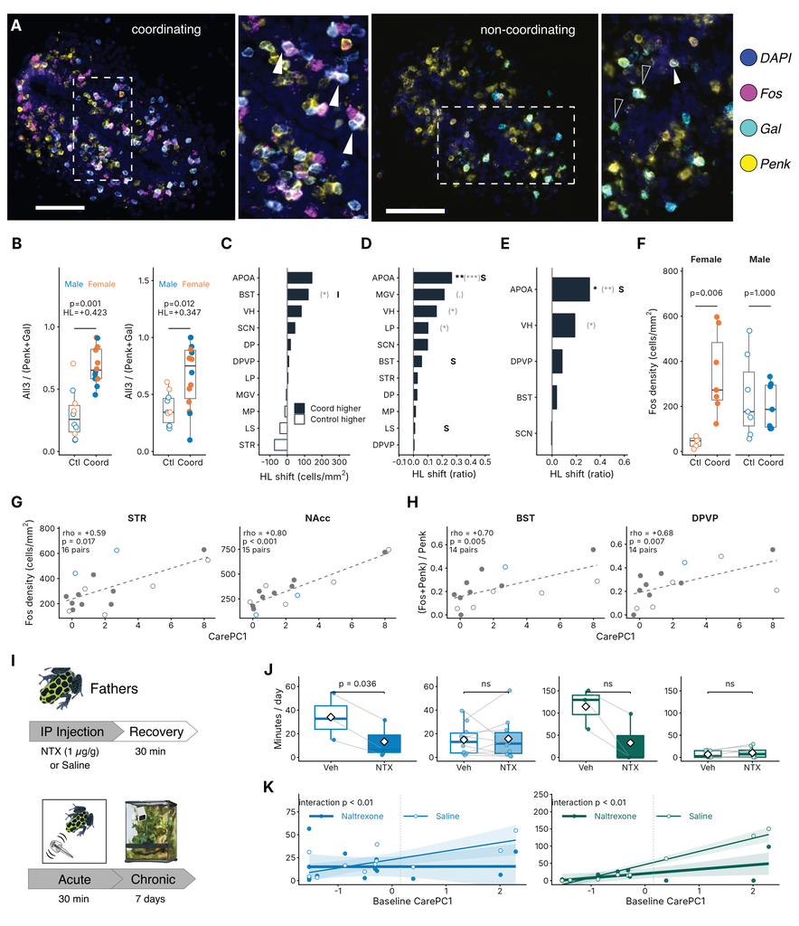

Figure 5.

Pair-level Spearman correlation with CarePC1 for every region (panels G and H show four of these):

**Code: CarePC1 correlation table**

```r
kable(derived("Figure5_CarePC1_region_stats.csv"), digits = 3)
```

| BrainRegion | n | rho | p | metric |
| --- | --- | --- | --- | --- |
| NACC | 15 | 0.796 | 0.000 | Fos_density |
| STR | 16 | 0.588 | 0.017 | Fos_density |
| DPVP | 14 | 0.459 | 0.098 | Fos_density |
| MPOA | 10 | -0.539 | 0.108 | Fos_density |
| HABENULA | 8 | 0.595 | 0.120 | Fos_density |
| LP | 12 | 0.462 | 0.131 | Fos_density |
| VH | 15 | -0.296 | 0.283 | Fos_density |
| DP | 12 | 0.287 | 0.366 | Fos_density |
| MP | 13 | 0.209 | 0.494 | Fos_density |
| APOA | 13 | 0.148 | 0.629 | Fos_density |
| MGV | 12 | -0.147 | 0.649 | Fos_density |
| SCN | 13 | -0.082 | 0.789 | Fos_density |
| LS | 15 | 0.021 | 0.940 | Fos_density |
| BST | 14 | -0.020 | 0.946 | Fos_density |
| BST | 14 | 0.701 | 0.005 | FosPenk_recruitment |
| DPVP | 14 | 0.684 | 0.007 | FosPenk_recruitment |
| LS | 15 | 0.521 | 0.046 | FosPenk_recruitment |
| STR | 16 | 0.400 | 0.125 | FosPenk_recruitment |
| VH | 15 | -0.229 | 0.413 | FosPenk_recruitment |
| APOA | 13 | -0.209 | 0.494 | FosPenk_recruitment |
| NACC | 15 | 0.189 | 0.499 | FosPenk_recruitment |
| MGV | 12 | -0.175 | 0.587 | FosPenk_recruitment |
| DP | 12 | 0.168 | 0.602 | FosPenk_recruitment |
| HABENULA | 5 | 0.316 | 0.604 | FosPenk_recruitment |
| MP | 13 | 0.132 | 0.668 | FosPenk_recruitment |
| MPOA | 10 | 0.127 | 0.726 | FosPenk_recruitment |
| LP | 12 | 0.112 | 0.729 | FosPenk_recruitment |
| SCN | 13 | 0.044 | 0.887 | FosPenk_recruitment |

Per-region statistics behind panels B to F:

**Code: per-region statistics table**

```r
kable(derived("Figure5_region_stats_allmetrics.csv"), digits = 3)
```

| Metric | BrainRegion | n_Coord | n_Control | mean_Coord | mean_Control | HL | HL_lo | HL_hi | cliffs_delta | p_condition_MW | q_condition_BH | p_sex_ANOVA | p_interaction_ANOVA | star_condition | sex_sig | interaction_sig |
| --- | --- | --- | --- | --- | --- | --- | --- | --- | --- | --- | --- | --- | --- | --- | --- | --- |
| (Fos+Gal)/Gal | APOA | 12 | 10 | 0.532 | 0.234 | 0.311 | 0.137 | 0.460 | 0.800 | 0.002 | 0.016 | 0.009 | 0.690 | ** | Y |  |
| (Fos+Gal)/Gal | VH | 15 | 10 | 0.476 | 0.265 | 0.189 | 0.019 | 0.377 | 0.507 | 0.038 | 0.169 | 0.915 | 0.541 | * |  |  |
| (Fos+Gal)/Gal | DPVP | 12 | 8 | 0.268 | 0.119 | 0.083 | -0.042 | 0.531 | 0.292 | 0.282 | 0.634 | 0.195 | 0.966 |  |  |  |
| (Fos+Gal)/Gal | BST | 11 | 10 | 0.255 | 0.106 | 0.038 | -0.050 | 0.423 | 0.227 | 0.371 | 0.668 | 0.267 | 0.804 |  |  |  |
| (Fos+Gal)/Gal | SCN | 9 | 11 | 0.310 | 0.308 | 0.000 | -0.300 | 0.367 | -0.051 | 0.878 | 0.878 | 0.570 | 0.969 |  |  |  |
| (Fos+Penk)/Penk | APOA | 12 | 10 | 0.441 | 0.156 | 0.266 | 0.152 | 0.419 | 0.900 | 0.000 | 0.005 | 0.050 | 0.506 | *** | Y |  |
| (Fos+Penk)/Penk | MGV | 9 | 8 | 0.282 | 0.070 | 0.214 | 0.000 | 0.399 | 0.556 | 0.060 | 0.195 | 0.613 | 0.472 | . |  |  |
| (Fos+Penk)/Penk | VH | 14 | 10 | 0.379 | 0.182 | 0.160 | 0.049 | 0.381 | 0.600 | 0.015 | 0.078 | 0.323 | 0.645 | * |  |  |
| (Fos+Penk)/Penk | LP | 11 | 8 | 0.186 | 0.063 | 0.101 | 0.012 | 0.176 | 0.659 | 0.018 | 0.078 | 0.928 | 0.970 | * |  |  |
| (Fos+Penk)/Penk | SCN | 9 | 11 | 0.278 | 0.195 | 0.098 | -0.066 | 0.245 | 0.293 | 0.287 | 0.623 | 0.990 | 0.934 |  |  |  |
| (Fos+Penk)/Penk | BST | 14 | 11 | 0.272 | 0.188 | 0.057 | -0.084 | 0.180 | 0.188 | 0.443 | 0.774 | 0.016 | 0.502 |  | Y |  |
| (Fos+Penk)/Penk | STR | 16 | 10 | 0.233 | 0.206 | 0.027 | -0.080 | 0.134 | 0.175 | 0.477 | 0.774 | 0.984 | 0.538 |  |  |  |
| (Fos+Penk)/Penk | DP | 11 | 8 | 0.163 | 0.099 | 0.025 | -0.058 | 0.107 | 0.182 | 0.536 | 0.774 | 0.364 | 0.716 |  |  |  |
| (Fos+Penk)/Penk | MP | 14 | 10 | 0.148 | 0.122 | 0.015 | -0.036 | 0.116 | 0.071 | 0.792 | 0.865 | 0.208 | 0.066 |  |  |  |
| (Fos+Penk)/Penk | LS | 16 | 9 | 0.184 | 0.216 | 0.010 | -0.093 | 0.127 | 0.069 | 0.799 | 0.865 | 0.044 | 0.558 |  | Y |  |
| (Fos+Penk)/Penk | DPVP | 14 | 9 | 0.283 | 0.257 | 0.005 | -0.168 | 0.162 | 0.016 | 0.975 | 0.975 | 0.072 | 0.781 |  |  |  |
| All3/(Penk+Gal) | APOA | 12 | 10 | 0.688 | 0.294 | 0.423 | 0.240 | 0.552 | 0.867 | 0.001 | 0.004 | 0.017 | 0.854 | *** | Y |  |
| All3/(Penk+Gal) | VH | 14 | 10 | 0.668 | 0.374 | 0.345 | 0.101 | 0.526 | 0.621 | 0.012 | 0.035 | 0.647 | 0.313 | * |  |  |
| All3/(Penk+Gal) | SCN | 9 | 8 | 0.502 | 0.678 | -0.200 | -0.500 | 0.300 | -0.208 | 0.493 | 0.591 | 0.466 | 0.983 |  |  |  |
| All3/(Penk+Gal) | BST | 9 | 8 | 0.288 | 0.271 | 0.000 | -0.333 | 0.500 | -0.056 | 0.879 | 0.879 | 0.122 | 0.697 |  |  |  |
| Fos density | APOA | 12 | 10 | 415.561 | 262.863 | 142.493 | -55.608 | 257.860 | 0.367 | 0.156 | 0.729 | 0.571 | 0.504 |  |  |  |
| Fos density | BST | 14 | 12 | 274.114 | 158.984 | 121.046 | 32.472 | 232.933 | 0.524 | 0.025 | 0.354 | 0.940 | 0.007 | * |  | Y |
| Fos density | VH | 15 | 10 | 297.178 | 158.976 | 81.053 | -16.558 | 236.292 | 0.387 | 0.114 | 0.729 | 0.364 | 0.296 |  |  |  |
| Fos density | STR | 16 | 10 | 300.706 | 347.058 | -73.911 | -227.452 | 121.650 | -0.200 | 0.414 | 0.828 | 0.507 | 0.972 |  |  |  |
| Fos density | SCN | 9 | 11 | 237.683 | 199.532 | 44.087 | -110.958 | 177.258 | 0.253 | 0.362 | 0.828 | 0.163 | 0.381 |  |  |  |
| Fos density | LS | 16 | 9 | 219.637 | 244.564 | -42.409 | -144.313 | 105.839 | -0.208 | 0.412 | 0.828 | 0.624 | 0.291 |  |  |  |
| Fos density | DP | 11 | 8 | 173.584 | 136.899 | 18.623 | -39.094 | 76.775 | 0.182 | 0.536 | 0.938 | 0.531 | 0.295 |  |  |  |
| Fos density | MP | 14 | 10 | 102.041 | 101.258 | -13.877 | -58.123 | 46.690 | -0.114 | 0.661 | 0.972 | 0.333 | 0.615 |  |  |  |
| Fos density | DPVP | 14 | 9 | 317.146 | 290.164 | 8.848 | -139.432 | 179.393 | 0.032 | 0.925 | 0.972 | 0.411 | 0.843 |  |  |  |
| Fos density | MGV | 9 | 8 | 274.719 | 290.164 | -6.020 | -203.750 | 156.240 | -0.028 | 0.962 | 0.972 | 0.874 | 0.434 |  |  |  |
| Fos density | LP | 11 | 8 | 180.744 | 132.616 | 4.251 | -65.257 | 167.567 | 0.045 | 0.901 | 0.972 | 0.419 | 0.848 |  |  |  |

## 7 Check of the rebuilt tables

The last step compares headline numbers from the rebuilt tables with the values recorded when this analysis was finalised, and stops the run at the first one that differs. The mixed models of Figure 2 are not checked because their p-values depend on the version of `lme4`.

**Code: Functions/check_results.R**

```r
# ============================================================================
# Check that a rebuild reproduces the published numbers
# November 11, 2026
#
# Reads the tables in Supplementary/derived_tables/ (written by the five figure scripts) and
# compares the headline numbers with the values in the reproducible report. Stops with a message at
# the first number that does not match. The mixed models of Figure 2 are not
# checked here because their p-values depend on the version of lme4.
#
# Run after the five figure scripts.
# ============================================================================

repo_dir <- here::here()
visits <- read.csv(file.path(repo_dir, "Supplementary", "derived_tables", "VisitDurations_byType_derived_v4.csv"))
care   <- read.csv(file.path(repo_dir, "Supplementary", "derived_tables", "CarePC1_classification.csv"))
rule   <- read.csv(file.path(repo_dir, "Supplementary", "derived_tables", "CarePC1_rule.csv"))
meta   <- read.csv(file.path(repo_dir, "Data", "recording_metadata.csv"))

check <- function(what, got, expected, tol = 0) {
  ok <- all(abs(got - expected) <= tol)
  cat(sprintf("  %-55s %s  (got %s)\n", what, if (ok) "ok" else "DOES NOT MATCH",
              paste(signif(got, 4), collapse = " / ")))
  if (!ok) stop("Rebuild does not match the published value for: ", what, call. = FALSE)
}

cat("Visit table\n")
check("recordings",                         length(unique(visits$tank)), 26)
check("visits",                             nrow(visits), 5805)
check("father-alone / mother-alone / coordinated",
      as.numeric(table(factor(visits$visitor, c("Male", "Female", "Family")))), c(3097, 1849, 859))
check("zero-length visits",                 sum(visits$duration_min == 0), 101)

cat("Six-metric PCA\n")
pca6 <- read.csv(file.path(repo_dir, "Supplementary", "derived_tables", "CarePCA_sixMetrics_loadings.csv"))
check("PC1 / PC2 variance explained (%)",   100 * c(pca6$VarExplained_PC1[1], pca6$VarExplained_PC2[1]), c(37.7, 24.6), 0.05)
check("loading of coordinated visits on PC1", pca6$PC1[pca6$Variable == "Visits_Family_perDay"], 0.535, 0.0005)
check("loading of father visits on PC1",    pca6$PC1[pca6$Variable == "Visits_Male_perDay"], 0.517, 0.0005)

cat("CarePC1\n")
check("PC1 variance explained (%)",         100 * rule$VarExplained_PC1[1], 61.2, 0.05)
check("cutoff",                             rule$Threshold[1], 0.156, 0.0005)
check("High / Low recordings",              c(sum(care$CareLevel == "High"), sum(care$CareLevel == "Low")), c(11, 15))

cat("Figure 1B\n")
pos   <- visits[visits$duration_min > 0, ]
type  <- ifelse(pos$visitor == "Family", "Coord", "Single")
m     <- tapply(log10(pos$duration_min), list(pos$tank, type), mean)
fold  <- m[, "Coord"] - m[, "Single"]
ranks <- rank(abs(fold))
check("visits with a duration",             nrow(pos), 5704)
check("Wilcoxon signed-rank W",             min(sum(ranks[fold > 0]), sum(ranks[fold < 0])), 46)
check("p",                                  wilcox.test(m[, "Coord"], m[, "Single"], paired = TRUE)$p.value, 0.000525, 5e-6)
check("recordings with longer coordinated visits", sum(fold > 0), 19)
check("median fold",                        10^median(fold), 1.98, 0.005)

cat("Figure 1C\n")
coord_min <- tapply(visits$duration_min[visits$visitor == "Family"],
                    visits$tank[visits$visitor == "Family"], sum)
eggs <- meta[!is.na(meta$EggFeedingEvents), ]
x    <- as.numeric(coord_min[eggs$ObservationID]) / eggs$NumberofFullDays
check("recordings scored for egg feeding",  nrow(eggs), 15)
check("Spearman rho",                       cor(x, eggs$EggFeedingEvents, method = "spearman"), 0.730, 0.0005)

cat("Figure 2C\n")
bl <- care[!is.na(care$bodylength), ]
check("recordings with body length",        nrow(bl), 23)
check("Spearman rho",                       cor(bl$Minutes_Family_perDay, bl$bodylength, method = "spearman"), 0.579, 0.0005)

cat("Figure 3 (TadBot)\n")
tb  <- read.csv(file.path(repo_dir, "Supplementary", "derived_tables", "TadBot_first3days.csv"))
off <- tb[tb$Treatment == "NegCtrl", ]; on <- tb[tb$Treatment == "TadBot", ]
stopifnot(identical(off$Tank, on$Tank))
check("tanks",                              nrow(off), 6)
check("first 3 days, all visits/day, off vs on: p", t.test(on$AllVisits_perDay, off$AllVisits_perDay, paired = TRUE)$p.value, 0.025, 0.0005)
td  <- read.csv(file.path(repo_dir, "Supplementary", "derived_tables", "TadBot_dailyVisits.csv"))
check("tank-days, trial days 1 to 14",      nrow(td), 156)
check("coordinated visits over those days, off / on", as.numeric(tapply(td$Visits_Family, td$Treatment, sum)[c("NegCtrl", "TadBot")]), c(71, 52))
check("visits over those days, off / on",   as.numeric(tapply(td$AllVisits, td$Treatment, sum)[c("NegCtrl", "TadBot")]), c(643, 574))
check("first 3 days, CarePC1, off vs on: p",     t.test(on$CarePC1, off$CarePC1, paired = TRUE)$p.value, 0.863, 0.0005)

cat("Figure 5 (naltrexone)\n")
ph   <- read.csv(file.path(repo_dir, "Supplementary", "derived_tables", "Pharmacology_perTank.csv"))
tank <- unique(ph[, c("Tank", "CareLevel")])
check("High / Low tanks",                   c(sum(tank$CareLevel == "High"), sum(tank$CareLevel == "Low")), c(3, 10))
hf  <- ph[ph$CareLevel == "High" & ph$Visitor == "Male", ]
sal <- hf[hf$Treatment == "Saline", ]; ntx <- hf[hf$Treatment == "Naltrexone", ]
stopifnot(identical(sal$Tank, ntx$Tank))
check("High-care fathers, saline vs naltrexone: p", t.test(ntx$MinutesPerDay, sal$MinutesPerDay, paired = TRUE)$p.value, 0.0364, 0.00005)

cat("Figure 5 (RNAscope pairs)\n")
rp <- read.csv(file.path(repo_dir, "Supplementary", "derived_tables", "RNAscope_CarePC1_perPair.csv"))
check("breeding pairs",                     nrow(rp), 18)
check("High / Low pairs",                   c(sum(rp$CareLevel == "High"), sum(rp$CareLevel == "Low")), c(14, 4))
check("coordinated visits, all pairs",      sum(rp$Visits_Family), 680)
check("coordinated minutes, all pairs",     sum(rp$Minutes_Family), 29748)

cat("All checks passed.\n")
```

**Check results**

```r
run_step("check_results.R")
```

```
Visit table
  recordings                                              ok  (got 26)
  visits                                                  ok  (got 5805)
  father-alone / mother-alone / coordinated               ok  (got 3097 / 1849 / 859)
  zero-length visits                                      ok  (got 101)
Six-metric PCA
  PC1 / PC2 variance explained (%)                        ok  (got 37.68 / 24.62)
  loading of coordinated visits on PC1                    ok  (got 0.5349)
  loading of father visits on PC1                         ok  (got 0.5175)
CarePC1
  PC1 variance explained (%)                              ok  (got 61.24)
  cutoff                                                  ok  (got 0.1558)
  High / Low recordings                                   ok  (got 11 / 15)
Figure 1B
  visits with a duration                                  ok  (got 5704)
  Wilcoxon signed-rank W                                  ok  (got 46)
  p                                                       ok  (got 0.0005246)
  recordings with longer coordinated visits               ok  (got 19)
  median fold                                             ok  (got 1.982)
Figure 1C
  recordings scored for egg feeding                       ok  (got 15)
  Spearman rho                                            ok  (got 0.7301)
Figure 2C
  recordings with body length                             ok  (got 23)
  Spearman rho                                            ok  (got 0.5788)
Figure 3 (TadBot)
  tanks                                                   ok  (got 6)
  first 3 days, all visits/day, off vs on: p              ok  (got 0.02527)
  tank-days, trial days 1 to 14                           ok  (got 156)
  coordinated visits over those days, off / on            ok  (got 71 / 52)
  visits over those days, off / on                        ok  (got 643 / 574)
  first 3 days, CarePC1, off vs on: p                     ok  (got 0.8627)
Figure 5 (naltrexone)
  High / Low tanks                                        ok  (got 3 / 10)
  High-care fathers, saline vs naltrexone: p              ok  (got 0.03642)
Figure 5 (RNAscope pairs)
  breeding pairs                                          ok  (got 18)
  High / Low pairs                                        ok  (got 14 / 4)
  coordinated visits, all pairs                           ok  (got 680)
  coordinated minutes, all pairs                          ok  (got 29750)
All checks passed.
```

## 8 Things to know

- The 26 reference recordings come from 8 breeding pairs (2 to 5 recordings per pair), so recordings are not fully independent.
- Care level is defined from coordinated visits and minutes, so the High/Low differences in Figure 2 panels G and J are expected by construction.
- Figure 5G and H count each breeding pair once. The sample sheet lists three animals (syn_18, syn_19, syn_20) as their own partner, so pairs are taken from `rnascope_pairs.csv`, where F14 is syn_17 + syn_18 and D10_2 is syn_19 + syn_20.
- One RNAscope log entry looks like a typing slip that the correction rules do not catch: in `coord_D10_2`, a coordinated visit is logged In at 06:08 and Out at 07:14 on 10 November, but the father is logged In at 06:14, so the Out was probably 06:14 (6 min, not 66). It is read as typed.

## 9 Reproducibility

- **Starting point.** The only inputs are the files in `Data/` and the images in `Figures/artwork/`. Deleting `Supplementary/derived_tables/` and the figure files and rendering this report (or running `Functions/run_all.R`) rebuilds both.
- **Random numbers.** Every step that uses them sets a seed: k-means for care level (seed 42; the High/Low split is the same for every seed from 1 to 200), the 10,000 label shuffles of the mate-pair synchrony test (seed 123), and the sideways jitter of points (display only).
- **What can differ on another computer.** Numbers in the derived tables can differ at the 15th significant digit. Mixed-model p-values (Figure 2 E, F, G; Figure 3D and E; Figure 5K) can change in the last digits with the `lme4` version. Figure files can differ in fonts. Figures 4 and 5 need `ggplot2` 3.5 or newer.
- **What is not derived here.** `recording_metadata.csv` and `rnascope_pairs.csv` were compiled by hand from the scoring notes, tadpole measurements and sample sheet; no script produces them. The phosphoTRAP inputs are the output of the read-alignment and edgeR pipeline, which is not part of this folder. The single-nucleus RNA-seq panels are finished images. The RNAscope image counts and the begging-frequency measurements are entered as measured.